# Practical TLA+_Planning Driven Development.Wayne2018

[figure not shown]

希勒尔·韦恩

实用TLA+规划驱动型发展

希勒尔·韦恩

美国伊利诺伊州芝加哥

本书中作者引用的任何源代码或其他补充材料均可通过本书的产品页面（网址为 www.apress.com/9781484238288 ）在 GitHub 上提供给读者。有关更多详细信息，请访问 http://www.apress.com/source-code 。

Any source code or other supplementary material referenced by the author in this book is available to readers on GitHub via the book’s product page, located at [www.apress.com/9781484238288](http://www.apress.com/9781484238288) . For more detailed information, please visit [http://www.apress.com/source-code](http://www.apress.com/source-code) .

ISBN 978-1-4842-3828-8 电子ISBN 978-1-4842-3829-5

https://doi.org/10.1007/978-1-4842-3829-5

美国国会图书馆控制号：2018958706

© Hillel Wayne 2018

本作品受版权保护。出版商保留所有权利，无论涉及全部或部分内容，特别是翻译权、重印权、插图再利用权、朗诵权、广播权、缩微胶片复制权或其他任何物理方式复制权、传输权、信息存储和检索权、电子改编权、计算机软件权，或以任何类似或不同的现有或未来开发的方法进行复制的权利。

本书中可能出现注册商标名称、标识和图像。我们并未在每次出现注册商标名称、标识或图像时都使用商标符号，而是仅出于编辑目的，并为商标所有者的利益使用这些名称、标识和图像，绝无侵犯商标权之意。本出版物中使用商号、商标、服务标记及类似术语，即使未明确标明，也不应被视为对其是否受所有权保护的意见表达。

本书中的建议和信息在出版之日被认为是真实准确的，但作者、编辑和出版商均不对可能出现的任何错误或遗漏承担任何法律责任。出版商对本书内容不作任何明示或暗示的保证。

本书由施普林格科学+商业媒体纽约分公司（地址：233 Spring Street, 6th Floor, New York, NY 10013）面向全球图书贸易发行。电话：1-800-SPRINGER，传真：(201) 348-4505，电子邮箱：orders-ny@springer-sbm.com，或访问网站：www.springeronline.com。Apress Media, LLC 是一家加利福尼亚州有限责任公司，其唯一成员（所有者）为 Springer Science + Business Media Finance Inc (SSBM Finance Inc)。SSBM Finance Inc 是一家特拉华州公司。

*献给我的老师 Todd Fadoir 和 Larry McEnerney。*

*For my teachers, Todd Fadoir and Larry McEnerney.*

介绍

这是一本关于规范的书。

This is a book about specification.

大多数软件缺陷都源于以下两个方面之一。当代码与我们的预期不符时，可能是代码本身有误。大多数软件正确性保证技术——例如类型定义、测试等等——都用于检查代码。但也有可能代码本身是正确的，只是我们的预期出现了偏差：我们的设计存在根本性的错误。

Most software flaws come from one of two places. When the code doesn’t match our expectations, it could be that the code is wrong. Most software correctness techniques – types, tests, etc. – are used to check the code. But it could instead be that the code is correct and our expectations are wrong: there’s a fundamental error in our design.

这些错误被称为 **规范错误** ，是最隐蔽也最危险的漏洞之一。它们可能跨越多个独立的程序，出现在复杂的竞争条件中，或者依赖于物理现象。我们常用的工具根本无法发现它们。

These errors, called **specification errors** , are some of the most subtle and dangerous bugs. They can span multiple independent programs, occur in convoluted race conditions, or depend on physical phenomena. Our regular tools simply can’t find them.

我们可以使用 TLA+ 等**规范语言**来找到它们 。TLA+ 由 2013 年图灵奖得主、Paxos 和 LaTeX 的发明者 Leslie Lamport 发明。您无需使用代码或纯英文编写设计，而是使用 TLA+ 的特殊符号。一旦您指定了核心假设和需求，它就可以探索该系统如何随时间演化，以及它是否真正具备您想要的属性。

Instead, we can find them with a **specification language** such as TLA+. TLA+ is the invention of Leslie Lamport, winner of the 2013 Turing Award and the inventor of Paxos and LaTeX. Instead of writing your design in code or plain English, you write it in TLA+’s special notation. Once you specify your core assumptions and requirements, it can explore how that system would evolve over time, and whether it actually has the properties you want.

与 Python 等语言相比，TLA+ 为何更适合此用途？Python 的设计初衷是用于运行，其功能受限于计算机的运算能力。而 TLA+ 的设计初衷则是用于探索。它利用简单的数学运算，能够比编程语言更优雅、更准确地表达概念。例如，给定一个数字集合，我们可以这样返回集合中另外两个数字之和对应的所有数字：

What makes TLA+ more suitable for this than, say, Python? Python is designed to be run, and it is limited to what a computer can do. TLA+, though, is designed to be explored. By leveraging simple math, it can express concepts much more elegantly and accurately than a programming language can. For example, given a set of numbers, here is how we would return the numbers in that set that are the sum of two other numbers in it:

`EXTENDS IntegersFilterSums(set) == { x \in set: \E y, z \in set \ {x}: y /= z /\ x = y + z }`

TLA+ 不是编译或解释执行的，而是 *进行检查的* 。我们使用一个 名为 TLC 的**模型检查器** 来执行规范中所有可能的行为。例如，如果它看到以下几行代码：

Instead of being compiled or interpreted, TLA+ is *checked* . We use a **model checker** , called TLC, to execute every possible behavior of our specification. For example, if it sees the lines

`either with change \in 1..10 do counter := counter + change; end with;or counter := 0;end either;`

TLC会将模型拆分成11条独立的时间线，并逐一检查是否存在任何问题。如果规范包含多个并行进程，TLC会探索所有可能的步骤顺序。如果规范有100个可能的初始状态，TLC会探索每个初始状态对应的所有行为。借助TLA+，我们可以检查全局属性是否得到保留、分布式系统是否具有容错性，甚至可以检查算法的每种行为最终是否都能得到正确答案。我们可以在编写任何一行代码之前就排除所有错误。

TLC will split the model into 11 separate timelines and check them all for any issues. If the spec has multiple simultaneous processes, TLC will explore every possible ordering of their steps. If the spec has 100 possible initial states, TLC will explore every behavior from every single one of them. With TLA+ we can check that global properties are preserved, that distributed systems are fault-tolerant, or even that every behavior of an algorithm eventually terminates with a correct answer. We can cut out bugs before we’ve written a single line of code.

## 这本书将教会你什么

## What This Book Will Teach You

学习 TLA+ 有两个好处。首先是模型检查。用 TLA+ 编写完规范后，可以使用模型检查器查找规范中的任何不一致之处。TLA+ 可以发现跨多个系统的错误以及多个嵌套的竞态条件。

There are two benefits to learning TLA+. The first is model checking. Once you have written a specification in TLA+, you can use the model checker to find any inconsistencies in your spec. TLA+ can find bugs that span multiple systems and several nested race conditions.

TLA+ 的第二个好处更为微妙。系统规范要求你精确地定义你真正想要的东西。“选择第一个元素”与“选择任意元素”或“选择任何元素”之间存在着本质区别，而这种区别可能导致规范的正确性或错误性。通过明确地编写规范，你会更好地理解它。即使没有模型检查器，问题也会变得显而易见。你使用 TLA+ 的次数越多，就越能直观地看到系统中的故障模式。

The second benefit of TLA+ is subtler. Specifying a system forces you to be precise in what you actually want. “Select the first element” is different from “select an arbitrary element” or “select any element” in ways that could lead to a spec being correct or not. By unambiguously writing your specification, you understand it better. Problems become obvious even without the model checker. The more you work with TLA+, the more you intuitively see the failure modes in systems.

对大多数人来说，学习 TLA+ 的最大挑战在于视角转变。虽然编程是规范编写的必要前提，但这与传统方法截然不同，需要一段时间来适应。如何规范算法？如何规范分布式系统？如何从理论层面理解 TLA+ 过渡到实践应用，并在实际生产系统中查找实际 bug？

For most people, the biggest challenge to learning TLA+ is the change of perspective you need. While programming is a necessary prerequisite to specification, it’s a very different approach and the adjustment takes some getting used to. How do you specify an algorithm? A distributed system? How do you make the jump from knowing TLA+ in theory to using it in practice, finding actual bugs in actual production systems?

本书旨在解决这一问题。我编写了十几个示例，涵盖了从底层线程到大规模分布式系统等广泛的问题领域。较短的示例包含在较大的章节中，而较长的示例则单独成章。通过展示如何定义和编写规范，我希望帮助您建立对如何在实践中使用 TLA+ 的直觉。这些示例还提供了动手实验的机会，如果您决定继续使用 TLA+，还可以使用模板来编写自己的规范。

This book is aimed at addressing that. I’ve written over a dozen examples spread across a wide range of problem domains, from low-level threading to large-scale distributed systems. Shorter examples are part of larger chapters, while the longer ones are chapters of their own. By showing you how a specification is defined and written, I hope to help you build an intuition for how to use TLA+ in practice. The examples also provide hands-on experimentation, and, if you decide to continue with TLA+, templates you can use to write your own specs.

## 这本书不会教你的

## What This Book Won’t Teach You

本书不会教你编程，也不会教你如何测试代码，更不会教你如何编写数学证明来证明代码的正确性。正式证明代码的正确性远比证明设计正确性要困难得多，也更费力。本书也不会教你如何直接将 TLA+ 代码转换为生产代码。TLA+ 的灵活性和强大功能很大程度上源于它 *无需* 与任何编程语言相匹配。几十行 TLA+ 代码就能实现数百甚至数千行代码的功能。没有任何工具可以取代你作为工程师的洞察力。

This book will not teach you programming. It will not teach you how to test code nor how to write mathematical proofs that your code is correct. Formally proving code correct is much more difficult and high effort than proving designs are correct. This book will not teach you how to directly convert TLA+ into production code. Much of TLA+’s flexibility and power comes from it *not* having to match a programming language. A few dozen lines of TLA+ can match hundreds or thousands of lines of code. No tool can replace your insight as an engineer.

最后，本书并非关于如何使用 TLA+ 的全面指南。我们主要侧重于使用 **PlusCal** ，它是编译成 TLA+ 的主要算法语言。PlusCal 添加了一些额外的结构，使 TLA+ 更易于学习和使用。尽管 PlusCal 功能强大且在 TLA+ 社区中广泛应用，但它仍然存在一些原始 TLA+ 所没有的局限性。

Finally, this book is not a comprehensive resource on how to use TLA+. In particular, we focus on using **PlusCal** , the main algorithm language that compiles to TLA+. PlusCal adds additional constructs that make TLA+ easier to learn and use. While powerful and widely used in the TLA+ community, PlusCal nonetheless has a few limitations that raw TLA+ does not.

## 先决条件

## Prerequisites

你应该已经是一位经验丰富的程序员了。虽然 TLA+ 可以与任何编程语言一起使用，但它本身并不是编程语言。如果没有可供编程的对象，使用 TLA+ 就没有任何意义。基于这个假设，我们也可以更快地学习：我们不需要学习什么是条件语句，只需要了解它在 TLA+ 中的写法即可。

You should already be an experienced programmer. While TLA+ can be used with any programming language, it is not a programming language. Without having something to program with, there’s really no reason to use TLA+. With this assumption, we can also move faster: we don’t need to learn what a conditional is, just what it looks like in TLA+.

了解一些逻辑和数学知识会有帮助。你不需要特别精通，但TLA+的语法大量借鉴了数学。如果你知道 (P => Q) \/ R 的含义，那就没问题了。如果你不知道，也应该能够理解，但附录A会教你其他所有需要的知识。

Knowing some logic and math is going to help. You don’t have to be particularly experienced with it, but TLA+ borrows its syntax heavily from mathematics. If you know what (P => Q) \/ R means, you’re fine. If you don’t know, this should still be accessible, but Appendix A will also teach you everything else you need.

## 本书的结构

## How This Book Is Structured

本书分为两部分。第一部分第 1 至 6章 介绍了 TLA+ 和 PlusCal 的语义。第二部分介绍了 TLA+ 的应用，展示了如何编写高效的运算符和规范。第一部分的章节建议按顺序阅读，而第二部分的章节可以按任意顺序阅读。

1. 1.

   *第一**章* 是对这门语言的快速概览。我们详细阐述了一个银行转账算法，并展示了如果同时发起多笔电汇，系统可能会出现透支或亏损的情况。
2. 1.

   *Chapter* *1* is a whirlwind tour of the language. We specify a bank transfer algorithm and show how it can overdraft or lose money if you start multiple simultaneous wires.
3. 2.

   *第二**章* 讲解算法语言的基础知识，以便您能够描述简单的非并发系统。我们还将介绍数据结构和非确定性语言结构，从而能够对基本的并发性和状态机进行建模。
4. 2.

   *Chapter* *2* teaches the basics of the algorithm language so you can specify simple, nonconcurrent systems. We also introduce the data structures and nondeterministic language constructs, allowing us to model basic concurrency and state machines.
5. 3.

   *第三**章* 讲解运算符和表达式、不变量和函数。结合 PlusCal 结构，我们可以描述复杂的系统并测试算法，例如约束优化问题。
6. 3.

   *Chapter* *3* teaches operators and expressions, invariants, and functions. Combined with the PlusCal constructs, this allows us to specify complex systems and test algorithms, such as constraint optimization problems.
7. 4.

   *第* *4*章 介绍了如何将模块组织成更大规模的规范，以及如何在不同的状态空间和需求上测试规范。
8. 4.

   *Chapter* *4* covers how to organize your modules into larger-scale specifications and test your specs on different state spaces and requirements.
9. 5.

   *第* *5*章 展示了如何对并发系统、竞争条件和死锁进行建模。
10. 5.

    *Chapter* *5* shows how to model concurrent systems, race conditions, and deadlocks.
11. 6.

    *第* *6*章 涵盖了本书所需的最后 TLA+ 部分：如何对系统的时间特性进行建模，例如资源保证、崩溃以及系统最终将达到的状态的要求。
12. 6.

    *Chapter* *6* covers the last bits of TLA+ we need for this book: how to model the temporal properties of a system, such as resource guarantees, crashes, and requirements about what states the system will eventually reach.
13. 7.

    *第* *7*章 讲解如何使用 TLA+ 来验证抽象算法的正确性，以及证明简单的运行时属性，例如最坏情况下的算法复杂度和避免整数溢出。
14. 7.

    *Chapter* *7* teaches how to use TLA+ to verify abstract algorithms are correct, as well as prove simple runtime properties, like worst-case algorithmic complexity and avoiding integer overflow.
15. 8.

    *第* *8*章 展示了如何创建可重用的数据结构库（例如链表），以及如何将它们用作更大规范的一部分。
16. 8.

    *Chapter* *8* shows how to create reusable data structure libraries, such as linked lists, and how to use them as part of larger specs.
17. 9.

    *第* *9*章 是关于状态机模式的，这是一种常用的技术，可以将高级规范转换为更接近我们生产代码的低级规范。
18. 9.

    *Chapter* *9* is about the state machine pattern, a common technique we use to turn high-level specifications into lower-level ones that more closely match our production code.
19. 10.

    *第* *10*章 以一个非正式的业务请求为例，在尝试对其进行规范的过程中，展示了模糊的需求如何导致截然不同的规范和运行时属性。
20. 10.

    *Chapter* *10* takes an informal business request and, in trying to specify it, shows how an ambiguous requirement can lead to very different specifications and runtime properties.
21. 11.

    最后，在 第*11**章* 中 ，我们将具体说明 MapReduce 算法，并使其既正确又具有容错性。
22. 11.

    Finally, in *Chapter* *11* we will specify the MapReduce algorithm and make it both correct and fault tolerant.
23. 12.

    *附录 A* 是一个数学速成课程，包括简单的集合论和逻辑，您在编写 TLA+ 规范时会发现这些内容很有用。
24. 12.

    *Appendix A* is a crash course of mathematics, including simple set theory and logic that you will find useful when writing TLA+ specs.
25. 13.

    *附录 B* 是 PT 模块的副本，以防您在下载工具箱和下载 PT 模块之间网络中断。有关 PT 模块的说明，请参见下文。
26. 13.

    *Appendix B* is a copy of the PT module in case the Internet burned down between you downloading the toolbox and downloading PT. See below for a description of PT.
27. 14.

    *附录 C* 是 TLA+ 的数学基础，例如模态逻辑和动作。虽然理解附录 C 并非阅读本书的必要条件，但如果您想了解 TLA+ 背后的理念，它将很有帮助。
28. 14.

    *Appendix C* is the math underpinning TLA+, such as modal logic and actions. It is unnecessary to understand anything in the book but will be helpful if you want to understand the ideas behind TLA+.

## 初始设置

## Initial Setup

### 工具箱

### The Toolbox

要使用 TLA+，我们需要 PlusCal 编译器、语法检查器和 TLC 模型检查器。大家都使用官方的 IDE，名为 *TLA+ Toolbox 。您可以从*https://github.com/tlaplus/tlaplus/releases/ 下载该工具箱 。截至撰写本文时，工具箱版本为 1.5.7。您还需要安装 Java。安装完成后，在 “文件 ”> “打开规范 ”> “添加新规范”下创建一个新模块。您应该会看到如图1 所示的 界面 。

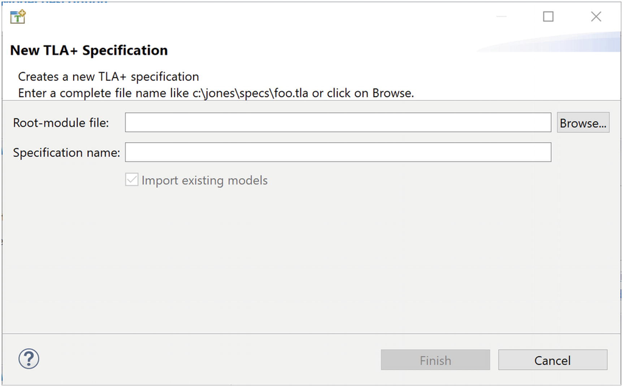

图 1

新增规格

Add New Spec

如果这样做，说明你已经正确设置了 TLA+。如果你打算从下一章的示例开始，请将你的第一个文件命名为 wire.tla ，并将规范名称命名为“wire”（或者你喜欢的任何规范名称）。

If you do, you’ve set up TLA+ correctly. If you plan to start with the example in the next chapter, name your first file wire.tla and the specification name to “wire” (or whatever you’d like to call the specification).

### PT

### PT

PT 库是一系列实用运算符和定义的集合，能够简化语言的学习和使用。这样， 我们就无需花费时间编写所有实用运算符，从而可以专注于规范的核心思想，并将运算符的练习推迟到以后。您需要手动下载并安装 PT：

1. 1.

   [从https://github.com/Apress/practical-tla-plus](https://github.com/Apress/practical-tla-plus) 下载模块 。将其移动到您计划存储 TLA+ 规范的位置。您也可以从附录 B 复制该模块。
2. 1.

   Download the module from https://github.com/Apress/practical-tla-plus . Move it to wherever you plan on storing your TLA+ specs. You can also copy it from Appendix B.
3. 2.

   转到 “文件”➤“首选项”➤“TLA+首选项 ”。您应该会看到一个名为“TLA+库路径位置”的控件。
4. 2.

   Go to File ➤ Preferences ➤ TLA+ Preferences . You should see a control labeled “TLA+ library path locations.”
5. 3.

   添加包含PT 的 目录 。您应该会看到类似图2 所示的内容 。
6. 3.

   Add the directory with PT . You should see something like what is shown in Figure 2 .

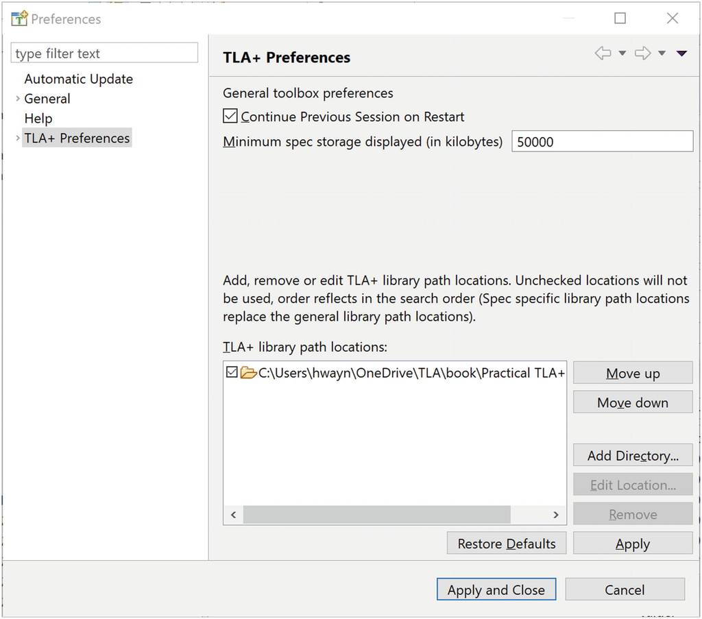

图 2

库路径位置

Library Path Location

将 PT添加 到规范后，您会在工具箱中看到它。我已经为所有内容添加了注释，解释了它们的工作原理。暂时不必完全理解这些注释，但当您更有信心时，我建议您阅读它们的工作原理。也欢迎您根据自己的需要进行调整，创建自定义运算符。

When you add PT to a specification, you will see it appear in the toolbox. I annotated all of the contents with descriptions of how it all works. Don’t worry about understanding them just yet, but when you feel more confident, I’d recommend reading how they work. And don’t be afraid to tweak them to make your own operators.

那么，我们就可以开始了。欢迎来到TLA+。

With that, we’re ready to begin. Welcome to TLA+.

致谢

Richard Whaling、Andrew Helwer、Murat Demirbas、Lorin Hochstein 和 Sidharth Masaldaan 都慷慨地为本书各章节的早期草稿提供了反馈意见。与 Leslie Lamport、Ron Pressler 和 Markus Kuppe 的讨论也帮助本书的某些章节得到了澄清和完善。

Richard Whaling, Andrew Helwer, Murat Demirbas, Lorin Hochstein, and Sidharth Masaldaan were all kind enough to provide feedback on early drafts of the chapters. Discussions with Leslie Lamport, Ron Pressler, and Markus Kuppe helped clarify and refine sections of this book.

Jud White 的技术审阅工作做得非常出色。正是他的出色审阅，才使得这本书真正值得一读。

Jud White went above and beyond with his technical review. He, more than anyone else, made this actually worth reading.

最后，Mark Powers、Matt Moodie、Steve Anglin 和 Sherly Nandha 都为本书的编辑工作做出了卓越的贡献。

Finally, Mark Powers, Matt Moodie, Steve Anglin, and Sherly Nandha all did a fantastic job editing this book.

### 目录

### Table of Contents

第一部分：TLA+ 和 PlusCal 的语义

第一章：一个例子 3

问题 3

样板 4

指定 5

实施 7

核实 9

初始条件 12

多进程 15

时间特性 19

概括 22

第二章：PlusCal 23

介绍 23

规格 23

规格书布局 23

表达式 24

价值观 26

PlusCal 算法主体 29

例子 32

复杂行为 34

多个起始状态 34

非确定性行为 38

概括 42

第三章：运算符和函数 43

操作员 43

不变量 46

逻辑运算符 47

表达式 50

函数 52

函数和运算符 53

函数集 56

例子 57

概括 64

第四章：常量、模型和导入 65

常量 65

普通任务 66

模型值 67

模型值集 67

认为 68

TLC 运行时长 69

配置 69

错误跟踪 72

TLC模块 72

进口 74

扩展 75

实例 75

概括 77

第五章：并发 79

标签 79

流程 81

等待 83

僵局 84

程序 86

例子 88

概括 96

第六章：时序逻辑 97

终止 97

口吃 99

公平、弱与强 100

时间算子 101

[] 101

<> 102

~> 102

[ ]<> 和 <>[ ] 103

生命力的局限性 104

例子 104

概括 110

第二部分：TLA+的应用

第七章：算法 113

单进程算法 113

最大限度 115

左脚垫 117

算法的性质 120

多进程算法 125

概括 126

第八章：数据结构 127

验证 133

例子 135

概括 136

第九章：状态机 137

状态机 137

脚手架实现 140

幽灵变量 146

概括 148

第十章：业务逻辑 149

要求 149

添加不变量 152

添加活体 154

添加预订 154

更新假设 158

即将到期的预订 160

概括 166

第十一章：MapReduce 167

问题概述 167

第一部分：基础知识 168

第二部分：活体性 176

第三部分：状态 189

锻炼 196

概括 197

附录 A：数学 199

命题逻辑 199

评估 TLA+ 中的命题 201

套 202

谓词逻辑 203

评估 TLA+ 中的谓词 206

附录 B：PT 模块 207

附录 C：PlusCal 到 TLA+ 211

时序逻辑 211

行动 212

TLA 214

PlusCal 的局限性 215

指数 217

### 关于作者和技术审阅者

### About the Author and About the Technical Reviewer

### 作者简介

### About the Author

希勒尔·韦恩

他是一位软件顾问，专长于形式化方法和规范。他还撰写有关经验工程、软件历史和系统思维的文章。闲暇时，他喜欢杂耍和制作巧克力。他住在芝加哥。您可以在 hillelwayne.com 或 Twitter 账号 @hillelogram 上找到他的其他作品。

is a software consultant who specializes in formal methods and specification. He also writes on empirical engineering, software history, and systems thinking. In his free time, he juggles and makes chocolate. He lives in Chicago. You can find his other work at hillelwayne.com or on Twitter at @hillelogram.

### 关于技术审校员

### About the Technical Reviewer

贾德·怀特

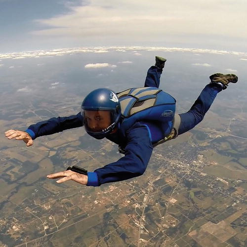

是一位拥有18年专业经验的后端和分布式系统工程师。他使用TLA+来简化设计，并确保系统的行为和权衡取舍得到充分理解和规范化。他目前在位于德克萨斯州奥斯汀的戴尔公司工作，偶尔会参加Go语言培训。他和女友以及两只可爱的比特犬一起生活。您可以在GitHub上关注他：@judwhite；Instagram：@jud.white；以及Twitter：@judson_white。

is a back-end and distributed systems engineer with 18 years of professional experience. He uses TLA+ to simplify designs and ensure the behavior and trade-offs of systems are well understood and codified. He currently works at Dell in Austin, Texas, and occasionally does Go training. He lives with his girlfriend and two lovable pit bulls. Follow him on GitHub: @judwhite; Instagram: @jud.white; and Twitter: @judson_white.

# 第一部分TLA+ 和 PlusCal 的语义

# Part IThe Semantics of TLA+ and PlusCal

© Hillel Wayne 2018

希勒尔·韦恩实用TLA+https://doi.org/10.1007/978-1-4842-3829-5_1

# 1. 一个例子

# 1. An Example

希勒尔·韦恩<sup>1</sup>

（1）

美国伊利诺伊州芝加哥

让我们开始编写第一个规范！本章我们将选取一个简单的问题，并将其转化为规范。然后，我们将对规范进行模型检查，看看它是否存在缺陷。剧透一下，它肯定会有缺陷。这将是一次快速浏览：我们将使用一些将在本书后续章节中逐步学习的概念。

Let’s write our first specification! In this chapter we will take a simple problem and translate it into a specification. Then, we’ll model check the specification and see if it has a flaw. Spoiler alert, it will have a flaw. This will be a whirlwind tour: we will be using concepts we will gradually learn over the course of the book.

## 问题

## The Problem

Alice 和 Bob 在 Bankgroup 都有账户。每个账户的余额都可能为 0 美元或多美元。Bankgroup 希望新增一项“电汇”功能，允许任何用户向其他用户转账。此功能有以下要求：

- 每笔汇款 必须由银行内的两名不同人员进行，且汇款金额至少为一美元。
- Each wire must be between two different people in the bank and wire at least one dollar.
- 如果汇款成功，汇款金额将从汇款人账户中扣除，并添加到收款人账户中。
- If a wire is successful, the value of the wire is deducted from the sender account and added to the receiver account.
- 如果汇款失败，两个账户的内容不会改变。
- If the wire fails, the two accounts are unchanged.
- 电汇不会导致账户出现负余额。
- A wire may not cause an account to have a negative balance.
- 出于扩展性的考虑，可以同时进行多根导线连接。
- For scaling reasons, multiple wires may happen simultaneously.

你的实现必须保证所有属性，即使线路传输时间可以任意长。换句话说，即使线路 A 先于线路 B 开始传输，A 也可能在线路 B 之后完成。你的算法必须保证，即使在这种情况下，也能满足所有要求。考虑到这关系到资金投入，你最好提前做好设计。

Your implementation must guarantee all properties, even if wires can take an arbitrary amount of time. In other words, even if wire A starts before B, A may still finish after wire B. Your algorithm must guarantee that, even in those cases, we satisfy all of the requirements. Given that money is on the line, you should probably design this in advance.

### 样板

### Boilerplate

我们将从一些样板代码开始。在“文件”>“打开规范”>“添加新规范”下创建一个新项目，将根模块文件设置为/your/path/wire.tla，并将规范名称设置为“wire”。您应该会看到类似图1-1 的内容。

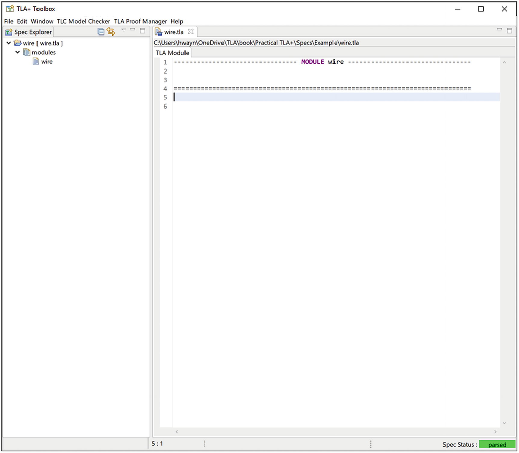

图 1-1

一份空白的规格说明

An empty specification

`---------- MODULE wire --------===============================`

左侧面板显示您拥有的 TLA+ 项目列表，右侧面板用于编写您的规范。破折号上方和等号下方的所有内容都将被忽略。我们不会将它们写入代码片段，您可以假设所有操作都在代码片段内部进行。

The left panel is the list of TLA+ projects you have, while the right panel is where you will write your spec. Everything above the dashes and below the equals are ignored. We will not write them in the code snippets, and you can assume that everything is happening inside those.

### 警告

### Warning

模块名称必须与文件名匹配，否则 TLA+ 将认为规范无效。

The name of the module must match the name of the file, or TLA+ will consider the spec invalid.

接下来是我们需要使用的导入语句。导入语句的 TLA+ 关键字是EXTENDS。由于我们要进行算术运算，所以需要在顶部添加EXTENDS Integers。最后，我们将设置算法框架 。

```
---------- MODULE wire --------
                      EXTENDS Integers

                      (*--algorithm wire

                      begin
                        skip;
                      end algorithm;*)
                    ===============================
```

单行注释用\*表示，注释块用(**)表示。算法代码放在注释里：我们稍后会解释原因。这就是我们需要的所有样板代码。现在我们可以开始具体说明我们想要什么了。

Single line comments are \*, comment blocks are (**). The algorithm is inside a comment: we’ll cover why later. That’s all the boilerplate we need. Now we can get around to specifying what we want.

### 指定

### Specifying

从设计角度来看，我们需要跟踪系统状态中的两项内容：拥有账户的用户集合，以及每个用户账户中的余额。为简单起见，我们将用姓名来表示每个用户，并假设他们的账户余额均为 5 美元。

`EXTENDS Integers(*--algorithm wire variables people = {"alice", "bob"}, acc = [p \in people |-> 5];begin skip;end algorithm;*)`

### 笔记

### Note

空格在这里并不重要。在TLA+中，空格只有一个重要的地方，我们将在第三章中讨论。

Whitespace is not significant here. There is exactly one place in TLA+ where it is significant, which we will cover in Chapter 3.

我们先来看people。people是一个**集合**。它是一个无序的元素集合，就像大多数编程语言一样。在这个例子中，它有两个字符串元素：“alice” 和 “bob”。没什么好奇怪的。

Let’s start with people. people is a **set**. It’s an unordered collection of things, same as most programming languages. In this case, it has two strings as elements: “alice” and “bob”. Nothing too surprising.

好的，那么acc呢？acc是一个**函数**。它不像普通的编程函数：它更接近于字典或映射。对于给定集合中的每个值，它都会映射到某个输出值。这里集合是people，元素是p。这意味着acc["alice"] = acc["bob"] = 5。在像 Python 这样的语言中，这等价于写{"alice": 5, "bob": 5}。我们还可以让函数依赖于每个元素。例如，我们可以写double = [x \in 1..10 |-> 2*x]。

Okay, what about acc? acc is a **function**. These aren’t like normal programming functions: they’re closer to dictionaries or mappings. For each value in a given set, it maps to some output value. Here the set is people and the element is p. This means acc["alice"] = acc["bob"] = 5. This would be equivalent, in a language like Python, to writing {"alice": 5, "bob": 5}. We could also make the function depend on each element. For example, we could write double = [x \in 1..10 |-> 2*x].

虽然我们最终希望能够支持多根电线 ，但我们先从模拟单根电线开始。我们假设这根电线价值 3 美元，并且是从爱丽丝到鲍勃。

`variables people = {"alice", "bob"}, acc = [p \in people |-> 5], sender = "alice", receiver = "bob", amount = 3;`

请注意，我们移动了分号，因为acc不再是我们声明的最后一个变量。

Note that we moved the semicolon, as acc is no longer the last variable we declare.

最后，我们要添加一个**不变式**。我们希望这个不变式在系统的任何状态下都为真，无论系统如何开始或结束。如果它为假，则我们的规范存在错误。

```
EXTENDS Integers(*--algorithm wirevariables    people = {"alice", "bob"},    acc = [p \in people |-> 5],    sender = "alice",    receiver = "bob",    amount = 3;
                      define
                        NoOverdrafts == \A p \in people: acc[p] >= 0
                      end define;
                    begin    skip;end algorithm;*)
```

### 实施

### Implementing

现在是时候添加实现代码了。我们将把它添加到开始算法和结束算法之间。它代表了我们迁移算法的实现，我们将检查它是否符合我们的规范。

`EXTENDS Integers(*--algorithm wirevariables people = {"alice", "bob"}, acc = [p \in people |-> 5], sender = "alice", receiver = "bob", amount = 3;define NoOverdrafts == \A p \in people: acc[p] >= 0end define;begin Withdraw: acc[sender] := acc[sender] - amount; Deposit: acc[receiver] := acc[receiver] + amount;end algorithm;*)`

如果是第一次给一个变量赋值，使用`=`。但是，如果变量已经存在，并且要给它赋新值，则使用`:= `。`Withdraw`和` Deposit`是**标签**。它们表示标签内的所有操作都发生在同一时刻。如果我们把这两个赋值操作放在同一个标签里，它们就会同时发生。但实际上，我们在取款和存款之间留出了一段时间。我们只允许一次转账 ，所以这并没有太大影响。但是，如果我们编写规范允许多次转账（我们稍后会这样做），这一点就变得重要了。

If you’re assigning a value to a variable for the very first time, you use =. However, if the variable already exists and you assign a new value to it, you use :=. Withdraw and Deposit are **labels**. They signify that everything inside them happens in the same moment of time. If we put the two assignments in the same label, they’d happen simultaneously. As it is, we let some time pass between the withdrawal and the deposit. We only allowed for one wire to happen, so this really doesn’t change much. But if we wrote the specification to allow multiple wires (which we’ll do later), this becomes more important.

对于初学者来说，用 TLA+ 编写实现可能比较困难，因此我们使用**PlusCal**编写了部分规范。PlusCal 是一种特殊的语言，可以编译成纯 TLA+ 代码。它添加了额外的语法，例如赋值语法`:=`和标签，从而在 TLA+ 的基础上构建了一个类似伪代码的结构。正因如此，我们需要将其放在注释中，因为它需要先进行转换。要编译 PlusCal 代码，我们可以依次选择“文件”>“转换 PlusCal 算法”。

Writing implementations in TLA+ can be a barrier starting out, so we wrote part of our spec in **PlusCal**, a special language that compiles to pure TLA+. PlusCal adds additional syntax, such as the := assignment syntax and the labels, giving us a pseudocode-like structure on top of TLA+. This is why we have to put it in a comment, as it needs to be translated first. To compile the PlusCal, we can go to File > Translate PlusCal Algorithm.

### 提示

### Tip

快捷键是 Ctrl-T，macOS 系统下是 Cmd-T。在编辑器中右键单击，上下文菜单中会有一个“自动翻译 PlusCal”选项，每次保存时都会自动翻译。

The shortcut is Ctrl-T, or Cmd-T on macOS. If you right-click in the editor, there’s an option in the context menu for “Translate PlusCal Automatically,” which does just that on every save.

你应该看到翻译后的 TLA+ 出现在下面的图1-2中，你写的内容被\* BEGIN TRANSLATION包围。

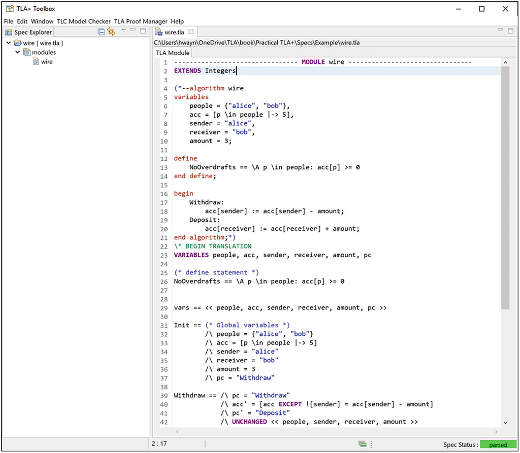

图 1-2

译文

The translated text

您无需再进行任何其他 操作。现在您可以查看您的规格了。

You don’t need to do anything else with it. You’re now ready to check your specification.

### 核实

### Verifying

为了验证这个规范是否有效，我们需要创建一个**模型**来检验它。这个模型就像我们想要运行的“模拟”。不同的模型可能会设置不同的初始条件，并检验不同的内容。由于我们这里并没有进行任何复杂的操作，所以我们只需要用模型来验证我们提出的那个不变式是否成立。

To check that this spec works, we need to create a **model** to check it. The model is like the “simulation” we want to run. Different models may set up different initial conditions and check for different things. Since we aren’t doing anything too fancy here, all we need to do with our model is check that our one invariant holds.

要创建模型，请转到TLC 模型检查器 > 新建模型。创建模型后，您应该会看到类似图1-3所示的内容。

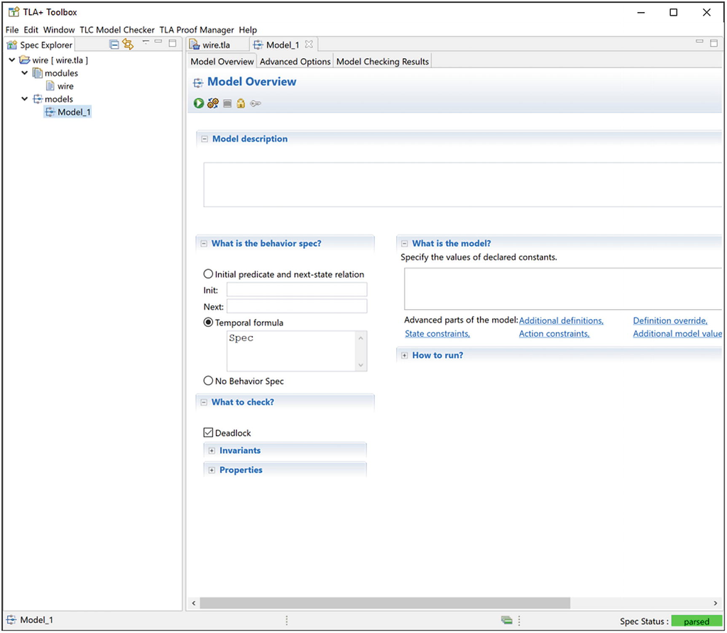

图 1-3

模型概述

The Model Overview

找到标有“不变量”的下拉菜单 ，然后单击“添加”按钮。输入我们要检查的不变量的名称（NoOverdrafts），保存，然后运行模型（“模型概览”正下方的绿色按钮）。

Find the drop-down labeled Invariants and click the Add button. Type in the name of the invariant we want to check (NoOverdrafts), save it, and run the model (the green button just under “Model Overview”).

### 笔记

### Note

运行该模型的快捷键是 F11。您可以在“偏好设置”中绑定自己的快捷键。

The shortcut for running the model is F11. You can bind your own shortcut in Preferences.

你应该看到找到了 4 个状态，其中 3 个是不同的状态，并且没有错误（图1-4）。从现在开始，如果测试顺利完成且没有错误，我们将列出它应该完成的状态数。在本例中，测试成功（4 个状态）。

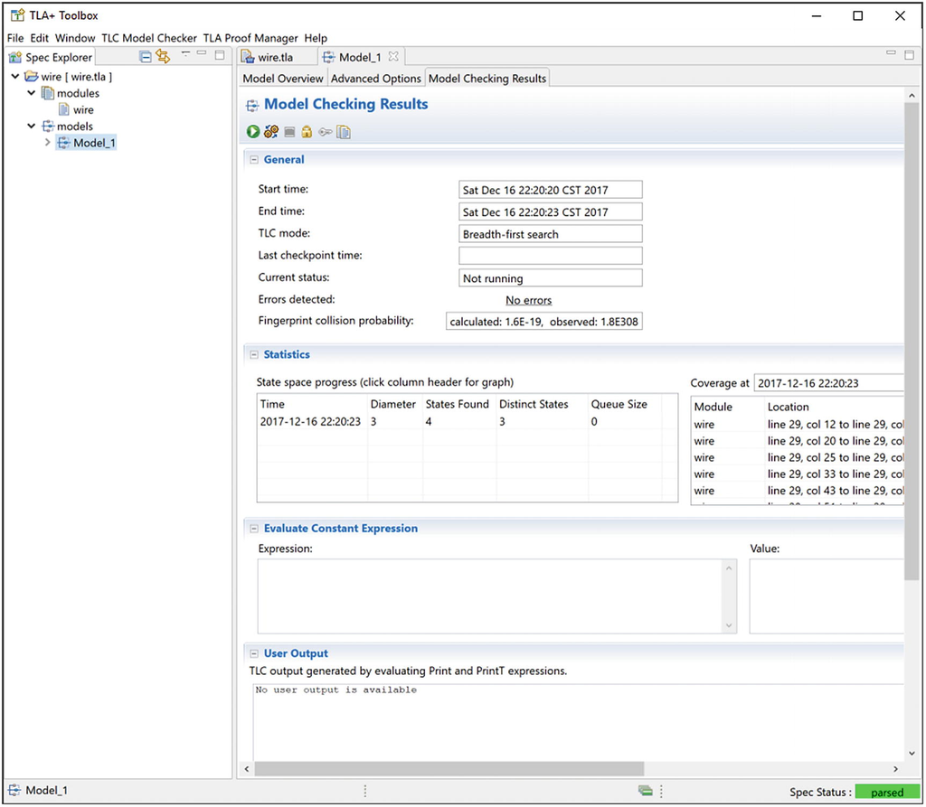

图 1-4

（4个州）

(4 states)

### 警告

### Warning

如果未找到任何状态，请返回“模型概览”，并确保已选择“时间公式”作为行为，并指定了时间公式规范。这将指示 TLC 专门检查您的规范的行为。

If you don’t see any states found, go back to Model Overview and make sure Temporal Formula is selected as the behavior with the temporal formula Spec. This is what tells TLC to specifically check the behavior of your spec.

TLC 对我们的整个状态空间进行了详尽的搜索 。由于我们没有进行任何特殊操作，因此只需要检查一种行为：

1. 1.

   选择一个可能的初始状态（只有一个可能的初始状态）。
2. 1.

   Choose a possible initial state (there is only one possible initial state).
3. 2.

   检查初始状态是否满足NoOverdrafts不变式。满足，因此开始评估。执行提款步骤。
4. 2.

   Check that the starting state follows the NoOverdrafts invariant. It does, so begin evaluation. Execute the Withdraw step.
5. 3.

   检查NoOverdrafts不变式。它为真，所以继续。
6. 3.

   Check the NoOverdrafts invariant. It’s true, so continue.
7. 4.

   执行存款步骤。
8. 4.

   Execute the Deposit step.
9. 5.

   检查NoOverdrafts不变式 。如果为真，则完成。
10. 5.

    Check the NoOverdrafts invariant . It’s true, so finish.

如果我们的规范有任何错误，就会弹出错误提示。既然没有出现错误提示，那么我们的规范很可能是正确的。

If our spec had any errors, it would have popped up an error bar. Since that didn’t happen, our spec is probably correct.

或许它太简单了。让我们来分析一下。

Or maybe it’s too simple. Let’s break it.

### 初始条件

### Initial Conditions

我们的测试用例在 Alice 正好给 Bob 发送 3 美元时有效，但这只是其中一种可能的输入。她可能发送 2 美元，也可能发送 20 美元。我们可以通过让 Alice 自行选择发送金额来扩展测试用例的覆盖范围。具体做法是，让 Alice从一组可能的数字（例如 1 到 6）中选择金额。TLA + 提供了a..b 的简写形式，分别表示 a 到 b（包含 a 和 b）之间的所有整数。请在与已翻译的 TLA+ 代码相同的文件中进行此更改。

`EXTENDS Integers(*--algorithm wirevariables people = {"alice", "bob"}, acc = [p \in people |-> 5], sender = "alice", receiver = "bob", amount \in 1..6;define NoOverdrafts == \A p \in people: acc[p] >= 0end define;begin Withdraw: acc[sender] := acc[sender] - amount; Deposit: acc[receiver] := acc[receiver] + amount;end algorithm;*)`

我们扩展了规范中可能的初始状态集合。我们的模型检查器将逐一检查这些初始状态，以确保它们全部通过。请重新编译 PlusCal 并重新运行模型。

We’ve expanded the set of possible initial states for our spec. Our model checker will check every single one of them to make sure they all pass. Recompile the PlusCal and rerun the model.

### 笔记

### Note

如果看到deleteOutOfSyncFiles，不用担心，这只是一个清理操作。

If you see deleteOutOfSyncFiles, don’t worry about it. It’s a cleanup thing.

这一次，你应该会看到一些新的东西（图1-5）。

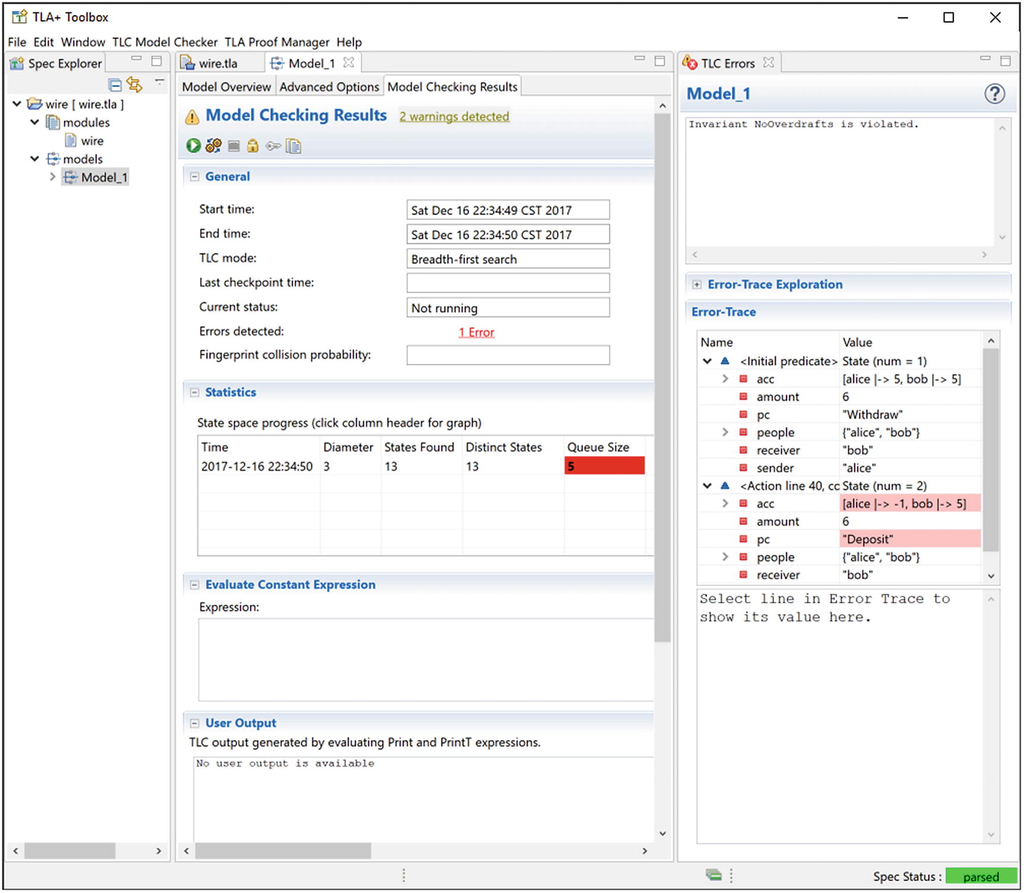

图 1-5

禁止透支违反

NoOverdrafts violated

TLC 显示了被违反的具体不变式 ，即NoOverdrafts。其下方是“错误跟踪”。这显示了初始条件以及导致违规的确切步骤顺序。在本例中，错误如下：

1. 1.

   选择数量 = 6作为初始状态的一部分。
2. 1.

   Choose amount = 6 as part of the initial state.
3. 2.

   检查初始状态是否满足NoOverdrafts不变式。满足，因此开始计算。
4. 2.

   Check that the starting state follows the NoOverdrafts invariant. It does, so begin evaluation.
5. 3.

   执行撤回步骤。
6. 3.

   Execute the Withdraw step.
7. 4.

   检查NoOverdrafts不变式。它为 false，因此抛出错误。
8. 4.

   Check the NoOverdrafts invariant. It’s false, so raise the error.

我们该如何解决这个问题？我们可以将规范限制为仅考虑金额在 1 到 acc[sender] 之间的情况，这样就能通过验证。然而，这可能与银行的预期使用情况不符。现实生活中，人们 可能会尝试转账超过其账户余额的金额，我们应该对此做好准备。不过，为了继续示例，我们假设这是一个可以接受的假设。请进行修改并再次确认模型是否通过验证（20 个状态）。

How can we fix it? We could restrict the spec to only consider amount \in 1..acc[sender], which would make it pass. However, this might not reflect the bank’s expected use. People in the real world might attempt to transfer more than they have, and we should be ready for that case. To continue with the example, though, we’ll assume that this is an acceptable assumption. Make the change and confirm the model passes again (20 states).

## 多进程

## Multiple Processes

还有一项要求需要实现：同时运行多个线程。应该允许用户在第一条线程完成之前启动第二条线程。在 PlusCal 中，每个同时运行的算法都属于各自的**进程**。每个进程都可以拥有自己的代码和局部变量。我们先从两条线程开始，这样就有两个进程运行完全相同的代码。

```
EXTENDS Integers(*--algorithm wirevariables    people = {"alice", "bob"},    acc = [p \in people |-> 5];define    NoOverdrafts == \A p \in people: acc[p] >= 0end define;
                    process Wire \in 1..2
                      variables        sender = "alice",        receiver = "bob",        amount \in 1..acc[sender];begin    Withdraw:        acc[sender] := acc[sender] - amount;    Deposit:        acc[receiver] := acc[receiver] + amount;
                    end process;
                  end algorithm;*)
```

如果我们重新翻译并重新运行，会再次出现错误。即使某个其他系统阻止了 Alice 尝试汇款 6 美元，该系统也无法处理多笔汇款。这样一来，两次提款都会发生，我们的测试用例就失败了。我们需要在测试用例中添加一个条件，以便 在提款前检查账户余额是否充足。

`EXTENDS Integers(*--algorithm wirevariables people = {"alice", "bob"}, acc = [p \in people |-> 5],define NoOverdrafts == \A p \in people: acc[p] >= 0end define;process Wire \in 1..2 variables sender = "alice", receiver = "bob", amount \in 1..acc[sender];begin CheckFunds: if amount <= acc[sender] then Withdraw: acc[sender] := acc[sender] - amount; Deposit: acc[receiver] := acc[receiver] + amount; end if;end process;end algorithm;*)`

这样做*也*失败了！TLC 会报告NoOverdrafts失败。这个错误比我们之前遇到的要复杂得多。为了了解错误原因，我们需要查看错误跟踪（图1-6）。

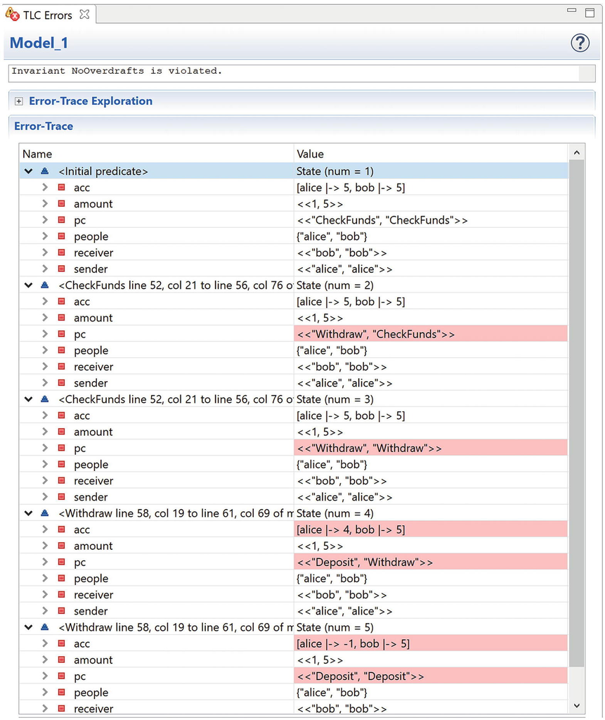

图 1-6

错误跟踪信息。您的错误跟踪信息可能略有不同。

An Error Trace. Yours may look slightly different.

<初始谓词>是我们选择的起始状态 。所有变量在这里都有赋值。pc是每个进程当前所在的标签，amount是每个进程对应的线路数量。由于我们允许线路数量变化，因此对于此状态，TLC 选择了<< 1, 5>>。

<Initial Predicate> is the starting state we picked. All of the variables have an assignment here. pc is the current label each process is on, and amount is the corresponding wire amount for each process. Since we let the wire amount vary, for this state TLC picked <<1, 5>>.

每个后续状态都会突出显示与前一个状态相比发生变化的变量。在状态 2 中，唯一的变化是第一个进程完成了CheckFunds步骤，并准备执行Withdraw步骤。步骤 3 类似。在步骤 4 中，pc发生了变化， acc也发生了变化：进程 1 已执行Withdraw，因此acc["alice"]从 5 变为 4。通过读取错误跟踪，我们可以了解此特定错误是如何发生的。

1. 1.

   选择amount[1] = 1 和 amount[2] = 5。
2. 1.

   Choose amount[1] = 1 and amount[2] = 5.
3. 2.

   执行CheckFunds[1]。由于1 <= acc["alice"]，因此继续执行Withdraw[1]。
4. 2.

   Execute CheckFunds[1]. Since 1 <= acc["alice"], proceed to Withdraw[1].
5. 3.

   执行CheckFunds[2]。由于5 <= acc["alice"]，因此继续执行Withdraw[2]。
6. 3.

   Execute CheckFunds[2]. Since 5 <= acc["alice"], proceed to Withdraw[2].
7. 4.

   执行Withdraw[1]。现在acc["alice"] = 4。
8. 4.

   Execute Withdraw[1]. Now acc["alice"] = 4.
9. 5.

   执行Withdraw[2]。现在acc["alice"] = -1。
10. 5.

    Execute Withdraw[2]. Now acc["alice"] = -1.

你可能会看到略有不同的错误跟踪，但整体模式应该相同。即使我们检查了 Alice 的余额是否充足，两个进程都可以在取款之前通过检查 。我们已经捕获了代码中的竞态条件。如果我们把检查和取款放在同一个标签下呢？这样一来，就无法在两个操作之间偷偷插入并发错误，因为它们会在同一时刻发生。实际上，我们可以通过先进行取款检查，如果透支则回滚来实现这一点。

`(*--algorithm wirevariables people = {"alice", "bob"}, acc = [p \in people |-> 5],define NoOverdrafts == \A p \in people: acc[p] >= 0end define;process Wire \in 1..2 variables sender = "alice", receiver = "bob", amount \in 1..acc[sender];begin CheckAndWithdraw: if amount <= acc[sender] then acc[sender] := acc[sender] - amount; Deposit: acc[receiver] := acc[receiver] + amount; end if;end process;end algorithm;*)`

## 时间特性

## Temporal Properties

“如果汇款失败，账户余额保持不变。” 对于只有两个人的简单情况，我们来看一个稍弱但更容易处理的要求：“账户的最终总余额与初始总余额相同。” 与“禁止透支”不同，这是一个**时间属性**。简单的不变量检查规范中的每个状态是否有效。时间属性检查算法从开始到结束的每个可能的“生命周期”是否都遵循某种将序列中的不同状态相互关联的规则。可以把它想象成检查数据库是否“始终一致”和“最终一致”之间的区别（当然，这只是你可以检查的众多方面之一）。以下是定义了时间属性后的新规范。

`EXTENDS Integers(*--algorithm wirevariables people = {"alice", "bob"}, acc = [p \in people |-> 5],define NoOverdrafts == \A p \in people: acc[p] >= 0 EventuallyConsistent == <>[](acc["alice"] + acc["bob"] = 10)end define;process Wire \in 1..2 variables sender = "alice", receiver = "bob", amount \in 1..acc[sender];begin CheckAndWithdraw: if amount <= acc[sender] then acc[sender] := acc[sender] - amount; Deposit: acc[receiver] := acc[receiver] + amount; end if;end process;end algorithm;*)`

`EventuallyConsistent`看起来和`NoOverdrafts`类似，但它的等式以`<>[]`开头。` <>[]`是“最终总是”运算符，意味着无论算法执行什么操作，最终给定的等式必然为真。它可能暂时为假，也可能在真假之间切换多次，但最终都会为真。

EventuallyConsistent looks like NoOverdrafts, but the equation starts with <>[]. <>[] is the “eventually-always” operator , and means that no matter what the algorithm does, in the end the given equation must eventually be true. It may be false for a while, and it may switch between true and false several times, but it will end true.

我们需要在“模型概览”页面的“属性”下添加时间属性。您可以在“不变量”下方找到它。添加完成后，重新运行模型。

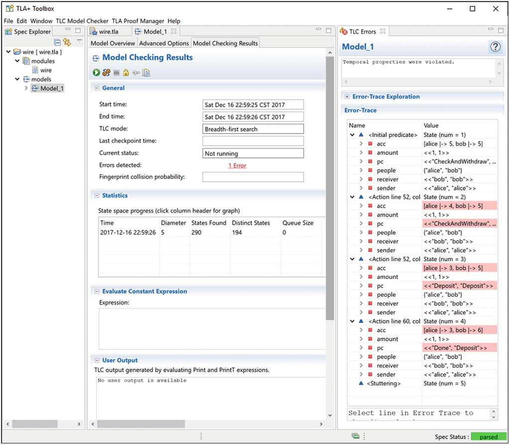

图 1-7

口吃错误

An error with stuttering

我们该如何解决这个问题？遗憾的是，没有好的办法。至少，没有既简单又不会在实践中失败的办法。

- 我们可以将支票、取款和存款操作合并在同一步骤中完成。这样一来，服务器就不会在取款和存款之间崩溃，因为取款和存款之间没有时间间隔。然而，实际上，这意味着我们的流程只有一个标签，也就是说它实际上运行时间为零。这违反了“资金流动需要任意时间”这一核心要求。
- We could make the check, withdraw, and deposit all happen in the same step. Then there’s no way for the server to crash between the withdraw and the deposit, because there is no timespan between the withdraw and the deposit. In practice, though, this means our process only has one label, which means it effectively takes zero time to run. This violates the core requirement that wires take an arbitrary amount of time.
- 我们可以明确地告诉 TLA+，我们的流程在提款和存款之间不能出现卡顿。我们的规范可以通过，但我们根本无法实现。服务器故障就像死亡和税收一样不可避免。
- We could specifically tell TLA+ that our process cannot stutter between the withdrawal and the deposit. Our spec would pass, but there’s no way we could implement it. Server faults are as certain as death and taxes.
- 我们可以说服项目经理放宽对最终一致性的要求。
- We could convince the Project Manager to relax the EventuallyConsistent requirement.
- 我们可以尝试一种完全不同的实现方式。
- We could try a different implementation entirely.
- 我们可以放宽“禁止透支”的要求。归根结底，大多数银行都是这样做的：他们不保证透支永远不会发生，而是努力降低透支的可能性，并制定相应的应对措施。
- We could relax the NoOverdrafts requirement. In the end, this is how most banks do it: instead of guaranteeing that overdrafts never happen, they work to make overdrafts less likely and have procedures in place when they do happen.

制定安全传输规范出乎意料地困难！不过，重要的是我们可以在无需编写代码的情况下测试规范。这使我们能够在构建系统之前探索各种解决方案并确认其安全性。

Specifying safe transfers is surprisingly hard! What’s important, though, is that we can test our specification without having to write code first. This lets us explore solutions and confirm they are safe before building our system.

## 概括

## Summary

我们编写了一个银行转账规范，并观察了模型检查器 TLC 如何发现我们设计中的竞态条件和逻辑错误。在此过程中，我们体验了 TLA+ 和 PlusCal 的所有功能。接下来的五章将更详细地介绍所有这些功能。第三章将介绍不变量、运算符和函数；第四章将重点讲解如何更好地使用 TLC；第五章将着重讲解并发性；第六章将讨论卡顿和时间属性。

We wrote a specification of a bank transfer and saw how the model checker, TLC, was able to find race conditions and logic bugs in our design. In the process, we sampled all of the various features of both TLA+ and PlusCal. Over the next five chapters, we will cover all of these features in more detail. Invariants, operators, and functions are all covered in Chapter 3, using TLC better is part of Chapter 4, Chapter 5 is all about concurrency, and Chapter 6 is stuttering and temporal properties.

至于 PlusCal 的基础知识，我们将在下一章中讲解。

As for the basics of PlusCal, that will be the next chapter.

© Hillel Wayne 2018

希勒尔·韦恩实用TLA+https://doi.org/10.1007/978-1-4842-3829-5_2

# 2. PlusCal

# 2. PlusCal

希勒尔·韦恩<sup>1</sup>

（1）

美国伊利诺伊州芝加哥

## 介绍

## Introduction

本章我们将介绍**PlusCal。PlusCal是一种可以编译成 TLA+ 的语言。Lamport 于 2009 年开发了它，旨在让程序员更容易上手 TLA+。我们想要做的绝大多数事情，用 PlusCal 实现起来都比用 TLA+ 容易得多。本章将涵盖 PlusCal 的所有内容，但多进程算法（见第**5章）和公平进程（见第6章）除外。

In this chapter we’ll be introducing **PlusCal**. PlusCal is a language that compiles down to TLA+. Lamport developed it in 2009 to make TLA+ more accessible to programmers. Most of the things we’ll want to do will be significantly easier in PlusCal than in TLA+. This chapter will cover all of PlusCal with the exception of multiprocess algorithms, which is Chapter 5; and fair processes, which is Chapter 6.

## 规格

## Specifications

### 规格书布局

### Layout of a Spec

首先，让我们来看上一章中银行转账的例子之一。

`---- (1) MODULE wire (2) ----EXTENDS Integers \* (3)(*--algorithm wire \* (4) variables (5) people = {"alice", "bob"}, acc = [alice |-> 5, bob |-> 5];begin \* (6) skip;end algorithm;*) (4)==== \* (1)`

我们编写的所有规范都将采用这种形式。

1. （1）

   所有 TLA+ 规范都必须以模块两侧至少四个“ -”开头，并以四个“ =”结尾。这是为了向后兼容。超出这两个边界的所有内容都会被忽略，人们通常会在这些位置放置元数据。
2. (1)

   All TLA+ specs must start with at least four – on each side of the MODULE and four = at the end. This is for backwards compatibility reasons. Everything outside these two boundaries is ignored, and people often put metadata there.
3. （2）

   模块名称必须与文件名相同。
4. (2)

   The module name must be the same as the filename.
5. （3）

   EXTENDS是导入关键字。我们正在导入Integers模块。
6. (3)

   EXTENDS is the import keyword. We’re importing the Integers module.
7. （4）

   *表示 TLA+ 中的行注释，(* ... *)表示块注释。PlusCal 规范放在注释中（因此解析器会忽略它），以`--algorithm <名称>`开始，以 `end algorithm`结束。算法名称*不必*与文件名匹配。
8. (4)

   \* starts a line comment in TLA+, (* ... *) is a block comment. PlusCal specs are placed in comments (so the parser ignores it), are started with --algorithm <name>, and closed with end algorithm. The name of the algorithm does *not* have to match the filename.
9. （5）

   在算法内部 ，我们使用变量初始化变量。变量之间用逗号或分号分隔。
10. (5)

    Inside the algorithm , we initialize variables with variables. Variables are separated by commas or semicolons.
11. （6）

    这里是编写算法本身的地方。
12. (6)

    This is where we write the algorithm itself.

### 笔记

### Note

教程中我们也用到了**标签。标签只在并发算法中才需要，所以目前我们先忽略它们，将在**第五章介绍它们的所有用途**。**

In the tutorial we had **Labels** too. They’re only necessary for concurrent algorithms, so for now we leave them out and will cover all of the uses for them in Chapter 5**.**

### 表达式

### Expressions

表达式中的所有元素要么是值（例如{TRUE}），要么是**运算符**（例如+）。下一章我们将编写自己的运算符，但本章我们只使用标准库提供的运算符。

Everything in an expression is either a value, like {TRUE}, or an **operator**, like +. In the next chapter we will be writing our own operators, but for this one we will only use the ones provided by the standard library.

由于我们将处理大量表达式，因此需要一种方法来评估它们，而无需运行整个规范。为此，我们可以使用**表达式评估器**。转到模型（例如规范中的Model_1），然后转到“模型检查结果”。如果您将表达式输入到“评估常量表达式”并运行模型，它将在“值”框中输出结果，如图2-1所示。

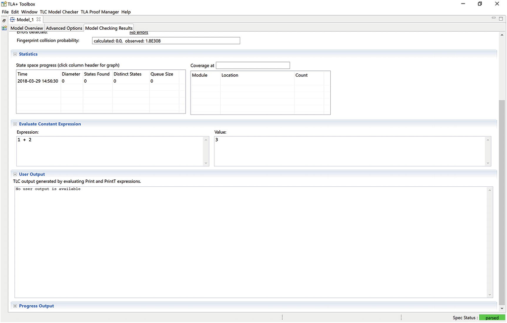

图 2-1

计算常量表达式

Evaluate Constant Expression

### 提示

### Tip

检查表达式也会评估您的规范。如果您不想运行它，可以在“模型概览”>“什么是行为规范？ ”下将其切换为“无行为规范”。

Checking an expression will also evaluate your spec. If you don’t want to run it, you can switch it to “No Behavior Spec” under Model Overview > What is the behavior Spec?

从现在开始，我们将使用以下格式来表示“计算常量表达式”及其结果：

`>> ExpressionResult`

例如，我们可以将上面的屏幕截图写成 ：

`>> 1 + 23`

### 价值观

### Values

TLA+ 中有四种基本值：字符串*、*整数*、*布尔值和**模型值**。不支持浮点数，布尔值用TRUE和FALSE表示，模型值将在第4章介绍。字符串必须用双引号括起来，不能用单引号。标准操作如下：

[output not shown]

### = VS :=

### = VS :=

如果`= `表示相等，`:=`表示赋值，为什么我们写`x = 1`而不是`x := 1` 呢？在原始的 TLA+ 中，*没有*赋值，只有相等。如果你想将 `x`*初始化*为 1，就写`x = 1`。如果 `x` 已经初始化，你想将其与 1*进行比较*，就写`x = 1`。如果 `x` 已经初始化，你想将其*赋值*为 1，就写`x' = 1`。在 TLA+ 中，这些实际上都是相等性检查！虽然这看起来可能不太直观，但这都是 TLA+ 处理时间的底层机制的一部分。

If = is equality and := is assignment, how come we write variables x = 1 and not variables x := 1? In raw TLA+, there *is* no assignment, only equality. If you want to *initialize* x to 1, you write x = 1. If x is initialized and you want to *compare* x to 1, you write x = 1. If x is initialized and you want to *assign* it to 1, you write x' = 1. In TLA+, these are all actually equality checks! While this might seem unintuitive, it’s all part of the underlying way TLA+ treats time.

这里有个经验法则：如果是第一次使用变量，`=`表示初始化。之后每次使用，`= ` 表示相等，`:=`表示赋值。例如，如果你写`x = 2, y = x, z = (x = y)`，你会得到`x = 2, y = 2, z = TRUE`。因为在写到 `z` 之前，`x` 和 `y` 都已经初始化过了，所以`(x = y)`是相等性判断。如果这让你有点困惑，那很正常，多加练习你就会慢慢理解了。

Here’s a rule of thumb: if it’s the first time you’re using the variable, = is initialization. Every other time, = is equality and := is assignment. If you write variables x = 2, y = x, z = (x = y) you will get x = 2, y = 2, z = TRUE. By the time we reach z we’ve already initialized x and y, so (x = y) is an equality check. If this is a little confusing, that’s understandable, and you’ll build an intuition with some experience.

如果我们扩展 整数，我们也会得到算术运算。+、-、%和*的行为都符合预期。整数除法是\div，而小数除法不受支持。你还可以使用范围运算符..，其中a..b是集合{a, a+1, a+2, ..., b}。

`>> 1..3{1, 2, 3}`

TLA+ 中有四种构造类型：*集合*、*元组/序列*、*结构体*和*函数*。函数将在下一章介绍。这里我们可以先介绍其他类型的基础知识。

There are four kinds of constructed types in TLA+: *sets*, *tuples/sequences*, *structures*, and *functions*. Functions are covered in the next chapter. We can cover the basics of the rest here.

**集合** 是元素的无序集合，用花括号括起来。例如，我们可以写成`set = {"a", "b", "c"}`。集合中的所有元素必须具有相同的类型，除此之外没有其他限制。你甚至可以创建函数集合的集合。集合具有以下运算符：

| 操作员 Operator | 意义 Meaning | 例子 Example |
| --- | --- | --- |
| x ∈ 集合 x \in set | 是集合的元素 Is element of set | >> 1 \in 1..2TRUE >> 1 \in 1..2TRUE |
| x \notin 集合 x \notin set ~(x \in 集合) ~(x \in set) | 不是集合的元素 Is not element of set | >> 1 \notin 1..2FALSE >> 1 \notin 1..2FALSE |
| 集合1 ⊆ 集合2 set1 \subseteq set2 | 是集合的子集 Is subset of set | >> {1, 2} \subseteq {1, 2, 3}TRUE >> {1, 2} \subseteq {1, 2, 3}TRUE |
| 集合1 \union 集合2 set1 \union set2 | 集合联合 Set Union | >> (1..2) \union (2..3){1, 2, 3} >> (1..2) \union (2..3){1, 2, 3} |
| 集合1与集合2相交 set1 \intersect set2 | 集合交集 Set Intersection | >> (1..2) \intersect (2..3){2} >> (1..2) \intersect (2..3){2} |
| 集合1 \ 集合2 set1 \ set2 | 集合差异 Set Difference | >> (1..2) \ (2..3){1} >> (1..2) \ (2..3){1} |
| 基数（集合） Cardinality(set) | 集合中的元素个数（需要EXTENDS FiniteSets模块） Number of elements in set (requires EXTENDS FiniteSets) | >> 基数({"a", "b"}) 2 >> Cardinality({"a", "b"}) 2 |

### 笔记

### Note

阅读规范时，您可能会看到并集(\union)写成\cup，交集 (\intersect)写成\cap。这是因为并集和交集分别对应数学符号 ∪ 和 ∩。我们使用并集/交集是因为它更清晰明了。

When reading specs, you might come across \union written as \cup and \intersect as \cap. This is a visual match of the mathematical symbols, ∪ and ∩. We’re using union/intersect because it’s more explicit.

集合还有两种特殊的集合变换。我们用{x \in set: conditional}*过滤*集合，并用{expression: x \in set}*映射*集合。

`>> {x \in 1..2: x < 2}{1}>> {x * 2: x \in 1..2}{2, 4}`

### 笔记

### Note

很少需要写出类似{x \in set1 : y \in set2}这样的语句，但这种情况（再次*强调*，很少）确实会发生。在这种特殊情况下，它会被视为对set1的一个过滤器。

It’s *very* rare to need to write something like {x \in set1 : y \in set2}, but it (again, rarely) does happen. In this edge case, it’s treated as a filter on set1.

**元组**或**序列** （这两个词很常用）是元素的有序集合，索引从 1 开始。它们用`<<`和`>>`指定，并且元素类型*不必*相同。例如，如果写成`tup = <<"a", {1, 2}>>`，则`tup[1] = "a"`，` tup[2] = {1, 2}`。同样，索引从 1 开始。如果我们扩展 `Sequences`，就会得到一些额外的序列运算符：

| 操作员 Operator | 意义 Meaning | 例子 Example |
| --- | --- | --- |
| 头部（序列） Head(sequence) | 头 Head | >> Head(<<1, 2>>)1 >> Head(<<1, 2>>)1 |
| 尾部（序列） Tail(seq) | 尾巴 Tail | >> 尾部(<<1, 2, 3>>) <<2, 3>> >> Tail(<<1, 2, 3>>) <<2, 3>> |
| 追加(seq, x) Append(seq, x) | 附加 Append | >> 追加(<<1, 2>>, 3) >> Append(<<1, 2>>, 3) <<1, 2, 3>> <<1, 2, 3>> |
| 序列1 \o 序列2 seq1 \o seq2 | 结合 Combine | >> <<1>> \o <<2, 3>> <<1, 2, 3>> >> <<1>> \o <<2, 3>> <<1, 2, 3>> |
| Len(seq) Len(seq) | 序列长度 Length of sequence | >> <<1, 1, 1, 1>> >> <<1, 1, 1, 1>> 4 4 |

虽然这两个术语可以互换使用，但按照惯例，当我们不希望对元组使用序列运算符或更改其长度时，我们使用*元组*；而如果需要这样做，则使用*序列。*

While the terms are interchangeable, by convention we use *tuple* when we don’t expect to use sequence operators on it or change its length, and we use *sequence* if we do.

**结构体** （或 struct）将字符串映射到值。你可以这样写： [ key1 |-> val1, key2 |-> val2, 等等 ]。值不必是同一类型。你可以使用struct.key获取值。

`>> [a |-> 1, b |-> <<1, {}>>].b<<1, {}>>`

### 笔记

### Note

虽然结构体和序列的语法不同，但它们本质上是同一种数据类型！我们将在下一章学习函数时详细了解这一点。

While the syntax for the two is different, structures and sequences are the same data type! We’ll learn more about this when we cover functions in the next chapter.

集合、序列和结构体都可以赋值给变量。以下是一个有效的 PlusCal 算法：

`(*--algorithm examplevariables x = <<1, [a |-> {}]>>;begin x[2].a := x[2].a \union {2};end algorithm; *)`

这里我们修改了元组/序列中结构体内部的集合。

Here we modified a set inside a struct inside a tuple/sequence.

以上涵盖了数据类型的基础知识。现在我们快速浏览一下 PlusCal 算法主体的一些基本语法。其中大部分内容在编程语言中应该都很熟悉，所以我们不会赘述。

That covers the basics of data types. Now let’s quickly run through some basic syntax of the PlusCal algorithm body. Most of this should be familiar from programming languages, so we won’t go into too much detail.

### PlusCal 算法主体

### PlusCal Algorithm Body

#### 任务

#### Assignment

将现有变量赋值给不同的值。使用:=完成。

Assign an existing variable to a different value. Done with :=.

#### 断言

#### assert

断言。`assert TRUE`不执行任何操作。`assert FALSE`会引发错误。添加断言是测试不变量的一种常用方法：断言会检查给定表达式在该步骤中是否成立，如果失败，则说明我们的规范破坏了该不变量。要使用断言，需要添加`EXTENDS TLC`。

An assertion. assert TRUE does nothing. assert FALSE raises an error. Adding assertions is one common way we test invariants: the assertion checks that in that step a given expression holds, so if it fails our spec broke the invariant. In order to use assertions, you need to add EXTENDS TLC.

#### 跳过

#### skip

空操作。我们可以用它来表示规范中尚未填写的部分，或者表示不会更新任何内容的条件语句。

A no-op. We can use this to fill represent parts of the spec that we haven’t filled out yet or conditionals that don’t update anything.

#### 如果

#### if

`if condition1 then bodyelsif condition2 then bodyelse bodyend if;`

虽然if是 PlusCal 中唯一的条件语句，但它*并非*唯一的分支语句。本章稍后将介绍另外两个分支语句： either和with 。

While if is the only conditional in PlusCal, it is *not* the only branching statement. Two others, either and with, will be introduced later in this chapter.

#### 尽管

#### while

PlusCal 中只有 While 循环这一种形式：

`while condition do bodyend while;`

请注意，这里我们使用了do，而对于 if 语句，我们使用了then。

Note that we use do here, while for the if statement we use then.

#### 宏

#### Macros

为了稍微简化规范，我们可以在开始之前添加**宏**。

`macro name(arg1, arg2) begin \* assignmentsend macro;begin name(x, y);end algorithm;`

宏中可以放置赋值语句、断言语句和 if 语句，但不能放置while循环。此外，同一个变量不能被赋值多次。宏中*可以引用* 外部值，也可以给外部变量赋值。例如，以下代码存在规范错误：

`EXTENDS TLC(*--algorithm examplevariables x = TRUE;macro set_false() begin x := FALSE;end macro;begin set_false(); assert x;end algorithm; *)`

虽然set_false不接受x作为参数，但它仍然能够改变变量。

While set_false doesn’t take x as a parameter, it’s still able to change the variable.

### 例子

### Example

让我们来设计一台分拣机！为了简化设计，我们可以忽略硬件细节。假设我们有一台机器，可以将物料分拣成“可回收物”和“垃圾”。它的可回收物和垃圾存放空间有限。特定尺寸和类型的物品会逐一进入机器，并根据以下规则进行分拣：

- 如果物品标有“可回收”字样，且其大小未超过回收箱的剩余容量，则该物品将被回收。
- If the item is labeled as “recycling” and it is under the remaining capacity for the recycling bin, the item goes into recycling.
- 如果物品被标记为“垃圾”，或者物品被标记为“可回收物”但回收容量不足，而垃圾桶容量足够，则该物品将被放入垃圾桶。
- If the item is labeled as “trash” OR the item is labeled as “recycling” and there is not enough recycling capacity AND there is sufficient capacity in the trash bin, the item goes into trash.
- 否则，它就会掉在地上，然后由其他人来扫。
- Otherwise, it’s dropped on the floor and somebody else gets to sweep it up.

我们先来思考一下表示方法。两个箱子的容量可以用数字表示。物品可以用一个结构体来表示，该结构体包含大小和类型的键：一个物品可能类似于[type |-> "trash", size |-> 2]。我们可以用集合来表示每个箱子中的物品数量 。最后，我们可以用序列来表示物品的放入顺序，例如<<item1, item2, item3>>。

Let’s start by thinking about our representations. The capacities of the two bins can be represented by numbers. The items can be represented by a structure with a key for size and a key for type: an item might look like [type |-> "trash", size |-> 2]. We can represent the numbers in each bin with sets. Finally, we can represent the order that items come in as a sequence, such as <<item1, item2, item3>>.

接下来，我们应该确定集合的不变量。我们目前还没有工具来检查集合的属性，所以我们可以先检查两个箱子的容量是否都超过了限制，以及每个箱子里的物品数量是否正确。

Next, we should figure out what our invariants are. We don’t have the tools yet to inspect properties on sets, so we can start by just checking that we don’t go over the capacity limit for either bin, and that each bin has the appropriate amount of items in it.

以下是编写规范的一种方式：

`EXTENDS Sequences, Integers, TLC, FiniteSets(*--algorithm recyclervariables capacity = [trash |-> 10, recycle |-> 10], bins = [trash |-> {}, recycle |-> {}], count = [trash |-> 0, recycle |-> 0], items = << [type |-> "recycle", size |-> 5], [type |-> "trash", size |-> 5], [type |-> "recycle", size |-> 4], [type |-> "recycle", size |-> 3] >>, curr = ""; \* helper: current itembegin while items /= <<>> do curr := Head(items); items := Tail(items); if curr.type = "recycle" /\ curr.size < capacity.recycle then bins.recycle := bins.recycle \union {curr}; capacity.recycle := capacity.recycle - curr.size; count.recycle := count.recycle + 1; elsif curr.size < capacity.trash then bins.trash := bins.trash \union {curr}; capacity.trash := capacity.trash - curr.size; count.trash := count.trash + 1; end if; end while; assert capacity.trash >= 0 /\ capacity.recycle >= 0; assert Cardinality(bins.trash) = count.trash; assert Cardinality(bins.recycle) = count.recycle;end algorithm; *)`

确认此功能有效（记得将 PlusCal 编译为 TLA+），包含 7 个状态，且无错误。我不喜欢 那两个 if 语句中的重复代码，所以我们添加一个宏。

`macro add_item(type) begin bins[type] := bins[type] \union {curr}; capacity[type] := capacity[type] - curr.size; count[type] := count[type] + 1;end macro;begin while items /= <<>> do curr := Head(items); items := Tail(items); if curr.type = "recycle" /\ curr.size < capacity.recycle then add_item("recycle"); elsif curr.size < capacity.trash then add_item("trash"); end if; \* rest is same`

我们将两个条件分支的主体替换为对add_item的调用。请再次确认此操作是否有效。

We replaced the bodies of the two conditions branches with calls to add_item. Confirm again that this works.

## 复杂行为

## Complex Behaviors

我们现在知道如何编写一个非常简单的规范，但它与确定性单元测试相比，几乎没有任何意义。如果我们想让它发挥作用，就需要一种方法来检查的不仅仅是单个设置，而是一整套设置和运行时场景。实现这一点的基本方法有三种。

We now know how to write a very simple spec, but what we have is barely more interesting than a deterministic unit test. If we want to make this useful, we need a way to check not just one setup, but an entire space of setups and runtime occurrences. There are three basic ways to do this.

### 多个起始状态

### Multiple Starting States

我们用等号 (= ) 初始化变量。但我们也可以用\in初始化它们。如果我们写x \in set，这意味着 x 是集合中的任意元素。例如，如果我们有

`(*--algorithm invariables x \in 1..3;begin assert x <= 2;end algorithm; *)`

TLC 首先会尝试用x = 1运行整个算法，然后是x = 2，最后是x = 3，但都会失败。如果我们添加第二个变量 y，它也使用了\in，那么 TLC 将检查 x 和 y 的所有可能组合。

TLC would first try running the whole algorithm with x = 1, then x = 2, then finally x = 3, which fails. If we added a second variable y that also used \in, TLC would check every single possible combination of x and y.

### 提示

### Tip

TLA+ 定义了集合{TRUE, FALSE}的简写BOOLEAN 。如果您有一个标志变量，例如变量 is_ready \in BOOLEAN ，这将非常有用。

TLA+ defines a shorthand BOOLEAN for the set {TRUE, FALSE}. This can be useful if you have a flag variable, such as variable is_ready \in BOOLEAN.

我们可以用它来选择任意数字。那么任意集合、结构体和元组呢？我们有一些特殊的运算符可以推广它们。

We can use this to choose some arbitrary number. What about arbitrary sets, structures, and tuples? We have some special operators to generalize them.

首先，对于给定的集合，SUBSET set是它的**幂集**，或者说是所有子集的集合。我们用UNION set来反转这个概念，它将一个集合的集合合并成一个集合。UNION {set1, set2, ... setn}等价于写成set1 \union set2 \union ... \union setn。

`>> SUBSET {"a", "b"}{{}, {"a"}, {"b"}, {"a", "b"}}>> UNION {{"a"}, {"b"}, {"b", "c"}{"a", "b", "c"}`

给定两个集合，set1 \X set2是所有元组的集合，其中第一个元素在 set1 中，第二个元素在 set2 中。

`>> {"a", "b", "c"} \X (1..2){<<"a", 1>>, <<"a", 2>>, <<"b", 1>>, <<"b", 2>>, <<"c", 1>>, <<"c", 2>>}`

**注意 \X 不满足结合律**。A \XB \XC是一个三元组集合，而(A \XB) \XC是一个二元组，其中*第一个*元素 也是一个二元组，A \X (B \XC)是一个二元组，其中*第二个*元素也是一个二元组。

`>> <<1, 2, 3>> \in (1..3) \X (1..3) \X (1..3)TRUE>> <<1, 2, 3>> \in (1..3) \X ((1..3) \X (1..3))FALSE`

最后，为了生成一组结构体，我们使用不同的语法。我们不再写[key |-> val]，而是写[key: set]。那么，如果x \in [key: set]，则 x 是一个结构体，其中key的值为set中的某个元素。

`>> [a: {"a", "b"}]{[a |-> "a"], [a |-> "b"]}>> [a: {"a", "b"}, b: (1..2)]{ [a |-> "a", b |-> 1], [a |-> "a", b |-> 2], [a |-> "b", b |-> 1], [a |-> "b", b |-> 2] }`

### 提示

### Tip

有时你需要一个结构，其中一个键始终代表一个特定值，而另一个键代表集合中的某个值。在这种情况下，你可以将值包装在一个单元素集合中，例如[key1: set, key 2: {value}]。

Sometimes you want a structure where one key is always a specific value, but another key is some value in a set. In that case you can wrap the value in a one-element set, as in [key1: set, key2: {value}].

与其他所有元素一样，这些都可以自由组合搭配。我们可以用`x \in [key: (set1 \X set2)]`来表示“x 是一个结构体，其中键的值为一对元素，第一个元素在 set1 中，第二个元素在 set2 中”。我们可以用这种方式在规范中详细描述复杂的数据结构。特别是，我们可以用这种方式来详细描述那些会破坏规范的复杂初始状态。

As with everything else, all of these can be freely mixed and matched. We can write variable x \in [key: (set1 \X set2)] to mean “x is a structure where the value of key is some pair of elements, the first being in set1, the second being in set2.” We can use this to detail complex data structures in our specifications. In particular, we can use this to detail complex starting states that break our spec.

#### 例子

#### Example

我们将重写回收器示例，使其具有任意容量和任意物品。

`variables capacity \in [trash: 1..10, recycle: 1..10], bins = [trash |-> {}, recycle |-> {}], count = [trash |-> 0, recycle |-> 0], item = [type: {"trash", "recycle"}, size: 1..6], items \in item \X item \X item \X item, curr = ""; \* helper: current item \* rest is same`

为了使代码更简洁，我们添加了一个辅助项。`items`可以根据`item`来定义，并且会是一个包含四个元素的序列。重新运行此代码后，您应该会注意到两点：

1. 1.

   检查模型需要更长时间。之前，我们只有一个可能的初始状态。现在我们有 10 × 10 × (2 × 6) <sup>⁴</sup> = 2,073,600 个初始状态。TLC 会智能地检查这些状态，但优化模型是一项你需要掌握的重要技能。
2. 1.

   Checking the model takes longer. Before, we had one possible starting state. Now we have 10 × 10 × (2 × 6)<sup>4</sup> = 2,073,600 starting states. TLC will be clever about checking them, but optimizing your models is an important skill you’ll develop.
3. 2.

   我们的测试失败了。TLC错误信息 大致如下：
4. 2.

   Our spec failed. The TLC error will look something like this:

`TLC threw an unexpected exception. This was probably caused by an error in the spec or model. See the User Output or TLC Console for clues to what happened. The exception was a tlc2.tool.EvalException ... The first argument of Assert evaluated to FALSE; the second argument was:`

这意味着测试失败，因为我们的一个断言失败了。每次运行得到的具体失败值可能不同，但核心问题是一样的。集合是唯一的，并且{x} \union {x} = {x}，而不是{x, x}。如果我们处理两个类型和大小完全相同的元素，最终会存储一次，但计数却增加了两次。这样一来，集合的大小和计数的值就不匹配了。

This means that the spec failed because one of our asserts failed. The exact values of the failure you get will probably be different run to run, but it will be the same core problem. Sets are unique, and {x} \union {x} = {x}, not {x, x}. If we handle two items with the exact same type and size, we end up storing it once but increasing count twice. Then the size of the set and the value of count don’t match up.

归根结底，问题出在集合上：我们的计数是正确的，但集合本身是错误的。我们需要的是重复项，所以最好将元素存储在序列中而不是集合中。而且， `set \union {curr}`看起来也不太美观。此外，由于我们将使用`Append`而不是`Cardinality`，因此可以摆脱对 ` FiniteSets` 的依赖。

Ultimately, the problem is in the set: our count is correct and the set is wrong. We want duplicates, so we should preferably store the items in sequences instead of sets. set \union {curr} looks ugly, anyway. Plus, we can get rid of the FiniteSets dependency, since we’d be using Append instead of Cardinality.

我们的最终规格如下：

```
EXTENDS Sequences, Integers, TLC(*--algorithm recyclervariables    capacity \in [trash: 1..10, recycle: 1..10],    bins = [trash |-> <<>>, recycle |-> <<>>],    count = [trash |-> 0, recycle |-> 0],    item = [type: {"trash", "recycle"}, size: 1..6],    items \in item \X item \X item \X item,    curr = ""; \* helper: current itemmacro add_item(type) begin  bins[type] := Append(bins[type], curr);  capacity[type] := capacity[type] - curr.size;  count[type] := count[type] + 1;end macro;


                        begin    while items /= <<>> do        curr := Head(items);        items := Tail(items);        if curr.type = "recycle" /\ curr.size < capacity.recycle then            add_item("recycle");        elsif curr.size < capacity.trash then            add_item("trash");        end if;     end while;     assert capacity.trash >= 0 /\ capacity.recycle >= 0;     assert Len(bins.trash) = count.trash;     assert Len(bins.recycle) = count.recycle;end algorithm; *)
```

应该能以 9,323,626 个州的赞成票通过 。

It should pass with 9,323,626 states .

### 非确定性行为

### Nondeterministic Behavior

并非所有行为都是确定性的。请求可能成功也可能失败，查询可能返回随机结果，也可能存在多种选择。对于单进程算法，我们提供了两种 PlusCal 结构来模拟不确定性。

Not all behavior is deterministic. A request may succeed or fail, a query might return a random result, there might be one of several choices to make. For single process algorithms, we have two PlusCal constructs to simulate nondeterminisim.

#### 任何一个

#### Either

我们这样写一个二选一表达式：

`either \* branch 1or \* branch 2 \* ...or \* branch nend either;`

当你对规范进行模型检查时，TLC 会同时检查所有分支。我们可以用这种方式来表示几种可能的情况同时发生。我们无法让某种可能性比其他可能性更大。通常，我们假设如果某个可能的选择导致我们的规范失效，无论可能性多么小，我们都需要修复它。

When you model-check your spec, TLC will check all branches simultaneously. We can use this to represent one of several possibilities happening. There is no way to make one possibility more likely than the other. We generally assume that if some possible choice invalidates our spec, no matter how unlikely, it’s something we’ll want to fix.

我们可以将任何赋值语句或 PlusCal 表达式放在`item`分支中。如果所有分支都“符合宏规则”，我们可以将 ` item`分支放在宏内部。

We can place any assignment or PlusCal expression inside of an either branch. If all of the branches are “macro-valid,” we may place an either inside of a macro.

#### 和

#### With

我们可以用两种方式编写with表达式：

`with var = value do \* bodyend with;\* orwith var \in set do \* bodyend with;`

在前一种情况下，这只是创建了一个临时变量。这遵循“如果是第一次遇到变量，则使用= ”的规则。我们可以用它来替换上一个例子中的curr，例如：

`with curr = Head(items) do if curr.type = "recycle" \* ...`

然而，第二种情况是不确定的。TLC 会检查所有可能的变量赋值给集合中元素的情况。如果集合为空，则测试会暂停，直到集合不为空为止。对于单进程应用程序，这被视为测试失败。

The second case, however, is nondeterministic. TLC will check what happens for all possible assignments of var to elements of set. If the set is empty, the spec halts until the set is not empty. For single-process apps, this is considered a spec failure.

with语句 遵循宏规则：不允许双重赋值和while循环。您可以将with语句放在宏内部。

with statements follow macro rules: no double-assignments and no while loops. You can place with statements inside macros.

### 警告

### Warning

with会给出值，而不是引用。如果 x 和 y 是变量，你不能通过写with t \in {x, y} do t := 1 来重新赋值给它们。但是，你可以写with t \in {x, y} do x := t。

with gives you values, not references. If x and y are variables, you could not reassign to them by writing with t \in {x, y} do t := 1. You could, though, write with t \in {x, y} do x := t.

#### 例子

#### Example

在这个例子中，我们将建立一个理想化的消息发送模型， 假设接收者不会自动接收消息。例如，接收者可能是朋友，他经常在手机信号覆盖范围之外活动。我们可以用一个两步循环来近似描述这种情况：

1. 1.

   轮到发件人时，他们会将信息投入发送状态。
2. 1.

   On the sender’s turn, they put a message in transit.
3. 2.

   轮到接收方时，他们要么收到正在传输中的消息，要么什么也不做（因为他们不在手机信号覆盖范围内）。
4. 2.

   On the receiver’s turn, they either receive a message in transit or do nothing (they’re outside cell coverage).

虽然消息的发送顺序和接收顺序是确定的，但消息在传输过程中并非按顺序排列。接收方可以按任意顺序收到传输中的消息。这意味着对于发送和接收的消息，我们有两个序列，但对于传输中的消息，我们只有一个序列。

`EXTENDS Sequences, TLC(*--algorithm telephonevariables to_send = <<1, 2, 3>>, received = <<>>, in_transit = {};begin while Len(received) /= 3 do \* send if to_send /= <<>> then in_transit := in_transit \union {Head(to_send)}; to_send := Tail(to_send); end if; \* receive either with msg \in in_transit do received := Append(received, msg); in_transit := in_transit \ {msg} end with; or skip; end either; end while;end algorithm; *)`

这段代码运行正常，没有报错。如果在 while 循环后添加 ` assert received = <<1, 2, 3>>;`，应该会报错。现在有好几种异常行为，TLC 会报告它找到的第一个异常，但这个异常可能并不总是同一个。不过，所有异常行为都应该类似于这样：

1. 1.

   发件人将消息 1 发送至传输中。
2. 1.

   The sender places message 1 in transit.
3. 2.

   接收器跳线。
4. 2.

   The receiver skips.
5. 3.

   发送方将消息 2 发送至传输中。
6. 3.

   The sender places message 2 in transit.
7. 4.

   接收器拉取消息 1。
8. 4.

   The receiver pulls message 1.
9. 5.

   发件人将消息 3 发送至传输中。
10. 5.

    The sender places message 3 in transit.
11. 6.

    接收器拉取消息 3。
12. 6.

    The receiver pulls message 3.
13. 7.

    接收器拉取消息 2。
14. 7.

    The receiver pulls message 2.

这被称为并发错误。TLA+ 特别适合识别和调试并发错误，这很好，因为许多最棘手、最隐蔽的错误都是并发错误。

This is called a concurrency bug. TLA+ is especially well-suited to identifying and debugging concurrency bugs, which is good, because a lot of the nastiest and most subtle bugs are concurrency bugs.

一种（虽然有点笨拙的）解决方法是，只有在上一条消息被确认接收后才允许发送。虽然实现细节可能很复杂，但我们可以通过为can_send添加一个标志来概括这一点：

```
variables  to_send = <<1, 2, 3>>,  received = <<>>,  in_transit = {},  can_send = TRUE;begin  while Len(received) /= 3 do    \* send    if can_send /\ to_send /= <<>> then      in_transit := in_transit \union {Head(to_send)};      can_send := FALSE;      to_send := Tail(to_send);    end if;





                          \* receive    either      with msg \in in_transit do        received := Append(received, msg);        in_transit := in_transit \ {msg};        can_send := TRUE;      end with;    or      skip;    end either;
```

有了这个修复，规范就有效了（18 个状态）。但这里存在一个微妙而又非常危险的问题：如果只有在对方收到消息的情况下才能发送 ，那么如果消息根本没被收到怎么办？我们唯一的不变条件是，最终消息必须按顺序到达。满足这个条件的一种方法是消息根本就没被收到！这被称为“**存活错误”，我们将在第**6章中进一步探讨。

With this fix, the spec is valid (18 states). But there’s a subtle and very dangerous problem here: if you can only send if the other person receives , what if the message is never received? Our only invariant is that, at the very end, the messages have arrived in order. One way to satisfy this is if the messages never arrive at all! This is called a **liveness** bug and we will study them further in Chapter 6.

*我们还应该考虑消息已成功接收但报告*已接收的机制失败的情况。我们可以通过使用另一个`Either`来表示这种情况，这次是为了检查我们是否重置了`can_send`。

`with msg \in in_transit do received := Append(received, msg); in_transit := in_transit \ {msg}; either can_send := TRUE; or skip; end either; end with;`

运行此代码后，应该会看到程序失败，并出现“已到达死锁”的错误。这意味着 TLC 已达到无法继续执行的状态。在本例中，发送方将消息 1 放入传输中，接收方收到消息 1 但没有*重置*can_send 。由于can_send 为 false，发送方无法执行任何其他操作；由于in_transit为空，接收方也无法执行任何操作。因此，程序已死锁。

If you run this, you should see it fail, with the error “Deadlock reached.” This means TLC reached a state where it can’t make any more progress. In this case, the sender places message 1 in transit, and the receiver receives message 1 but does *not* reset can_send. The sender can’t do anything else because can_send is false, and the receiver can’t do anything because in_transit is empty. Deadlock.

死锁是并发代码中一个特别常见的问题，我们将在第5章中详细讨论它。

Deadlocks are a particularly common problem in concurrent code, and we will discuss them more in Chapter 5.

## 概括

## Summary

本章介绍了使用 PlusCal 编写规范的基础知识。我们学习了集合、元组/序列和结构的语法，以及如何检查多个初始状态和模拟非确定性行为。

In this chapter we covered the basics of using PlusCal to write specs. We learned the syntax for sets, tuples/sequences, and structures, as well as how to check multiple starting states and simulate nondeterministic behavior.

下一章，我们将学习如何正确使用 TLA+ 创建复杂数据和不变量。我们还将介绍最后一种数据类型：函数。

In the next chapter, we will learn how to use TLA+ proper to create complex data and invariants. We will also introduce the last data type: functions.

© Hillel Wayne 2018

希勒尔·韦恩实用TLA+https://doi.org/10.1007/978-1-4842-3829-5_3

# 3. 运算符和函数

# 3. Operators and Functions

希勒尔·韦恩<sup>1</sup>

（1）

美国伊利诺伊州芝加哥

本章我们将正式介绍 TLA+，并使用它来编写功能更强大的、包含复杂不变量的规范。我们之前已经使用过一些 TLA+。我们所有的变量都是用 TLA+ 表达式定义的。我们所有的值、集合、序列和结构都是 TLA+ 表达式。我们所有的条件语句也是 TLA+ 表达式。PlusCal 只是一个框架结构、一个简化的赋值规则和一些额外的关键字。

In this chapter, we will introduce TLA+ proper and use it to write more powerful specs with complex invariants. We’ve already been using some TLA+. All of our variables were defined in terms of TLA+ expressions. All of our values, sets, sequences, and structures were TLA+ expressions. All of our conditionals were TLA+ expressions. PlusCal was just a framing structure, a simplified assignment rule, and a few extra keywords.

既然我们知道了这一点，我们就可以更正式地表达它，并充分利用它的实际含义。

Now that we know this, we can express it more formally and leverage what it actually means.

## 操作员

## Operators

运算 符相当于编程中的过程。它的写法如下：

`Op(arg1, arg2) == Expr`

是的，这里用了双等号。如果表达式不依赖于参数，你可以写成`Op == Expr`。这通常用于表示常量。我们可以使用运算符来简化回收器的设置：

```
BinTypes == {"trash", "recycle"}
                    SetsOfFour(set) == set \X set \X set \X set
                  Items == [type: BinTypes, size: 1..6](* --algorithm recyclervariablescapacity \* ...
                    items \in SetsOfFour(Items);
```

由于我们输入的可能项集合是固定的，因此我们将其定义为运算符而不是变量。这可以防止我们在算法本身中意外修改该集合。TLA+ 不使用分号；只有 PlusCal 计算才需要分号。TLA+ 的语法（除了下文提到的嵌套条件语句）对空格不敏感，如果您愿意，可以将所有三个运算符放在同一行。

Since the set of possible items we’re feeding in is constant, we define it as an operator instead of a variable. This prevents us from accidentally modifying the set in the algorithm itself. The TLA+ does not use semicolons; only the PlusCal computations need semicolons. TLA+’s syntax is (with the exception of nested conditionals below) not whitespace sensitive, and you could place all three operators on the same line if you really wanted to.

如果要 使用 PlusCal 算法的变量定义运算符，可以将其放在 define 块中：

`define NoBinOverflow == capacity.trash >= 0 /\ capacity.recycle >= 0 CountsMatchUp == Len(bins.trash) = count.trash /\ Len(bins.recycle) = count.recycleend define;\* ...assert NoBinOverflow /\ CountsMatchUp;`

### 警告

### Warning

PlusCal 转换器非常简单，所有内容都必须按正确的顺序排列。定义*必须*位于宏定义之上，变量定义之下。

The PlusCal translator is very simple and everything needs to be in the right order. Definitions *must* go above macro definitions and below variable definitions.

我们可以将运算符的定义放在新的一行。我们也可以将两个子句分别放在不同的行上。定义断言的另一种方法是将NoBinOverflow和CountsMatchUp合并成一个运算符：

`define Invariant == /\ capacity.trash >= 0 /\ capacity.recycle >= 0 /\ Len(bins.trash) = count.trash /\ Len(bins.recycle) = count.recycleend define;`

为了方便格式化，我们可以在第一个分句前添加一个可选的反斜杠/\。这是在单个运算符中编写多个分句的惯用方法。我们还可以嵌套分句：**这是 TLA+ 中唯一需要注意空格的地方**。如果分句后面的行缩进，则它属于同一个子分句。换句话说，如果我们写

`/\ A/\ B \/ C/\ D`

我们得到A /\ (B \/ C) /\ D。

We get A /\ (B \/ C) /\ D.

还有一些特殊形式的运算符，它们有自己独特的语法。首先，我们可以有高阶运算符，或者说接受其他运算符作为参数的运算符。你需要预先指定运算符接受的参数数量，这可以通过下划线(_)来实现。

`Add(a, b) == a + bApply(op(_, _), x, y) == op(x, y)>> Apply(Add, 1, 2)3`

你可以使用LAMBDA定义匿名运算符。匿名运算符只能用作其他运算符的参数，不能用作独立运算符。它们的写法是：LAMBDA param1, param2, paramN: body。

`Apply(LAMBDA x, y: x + y, 1, 2)>> 3`

最后，像>=和\o这样的符号也是运算符。还有一组“用户可自定义运算符符号”，可以将其定义为运算符。您可以在工具箱中依次点击“帮助”>“TLA+ 速查表”查看这些符号。

`set ++ elem == set \union {elem}set -- elem == set \ {elem}>> {1, 2} ++ 3{1, 2, 3}>> {1, 2} – 2{1}`

## 不变量

## Invariants

我们可以使用运算符作为**不变量**。不变量是一个布尔表达式，在模型的每个“步骤”结束时都会进行检查。如果它为假，则模型失败。我们在第二章中看到的NoOverdrafts运算符就是一个不变量的例子。类似地，我们可以在回收器中使用NoBinOverflow和CountsMatchUp作为不变量，这样就无需在最后进行断言了。

We can use operators as **invariants**. An invariant is a Boolean expression that’s checked at the end of every “step” of the model. If it’s ever false, the model fails. One example of an invariant is the NoOverdrafts operator we saw in Chapter 2. Similarly, we can use NoBinOverflow and CountsMatchUp as our invariants in the recycler, which makes the assert at the end superfluous.

并非所有你编写的模型都会检查所有不变量。你必须指定你实际关心的内容。你可以通过将不变量添加到模型的“不变量”部分，然后检查它们来实现这一点（图3-1）。

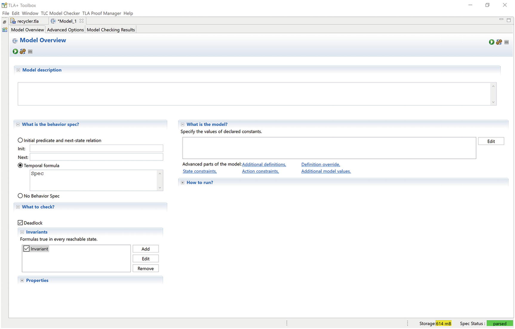

图 3-1

新增一个不变量 ，用于检查所有内容

An added invariant that checks everything

如果我们添加这些参数并重新运行模型，你会注意到与之前不同的两点。首先，错误信息更加清晰易懂。其次，我们的测试用例不再像之前那样在运行结束时才失败，而是在错误出现时立即失败。这使得我们更容易找出问题所在。

If we add them and rerun the model, you’ll note two differences with the failure. First of all, the error is much nicer. Second, instead of our spec failing at the very end of the run, it fails as soon as the error appears. This makes it easier to identify what went terribly wrong.

我们不需要定义运算符来添加不变量。我们可以将任何表达式放在“不变量”框中。但是，创建专用运算符更简洁，也更能清晰地向其他阅读规范的人传达你的意图。

We don’t need to define an operator to add an invariant. We can place any expression we want in the “Invariants” box. However, creating dedicated operators is cleaner and better signals your intent to anybody else who reads your spec.

从现在开始，我们将使用INVARIANT NameOfInvariant来记录您正在检查的不变量。在上面的例子中（图3-2 ），我们使用INVARIANT Invariant运行模型。

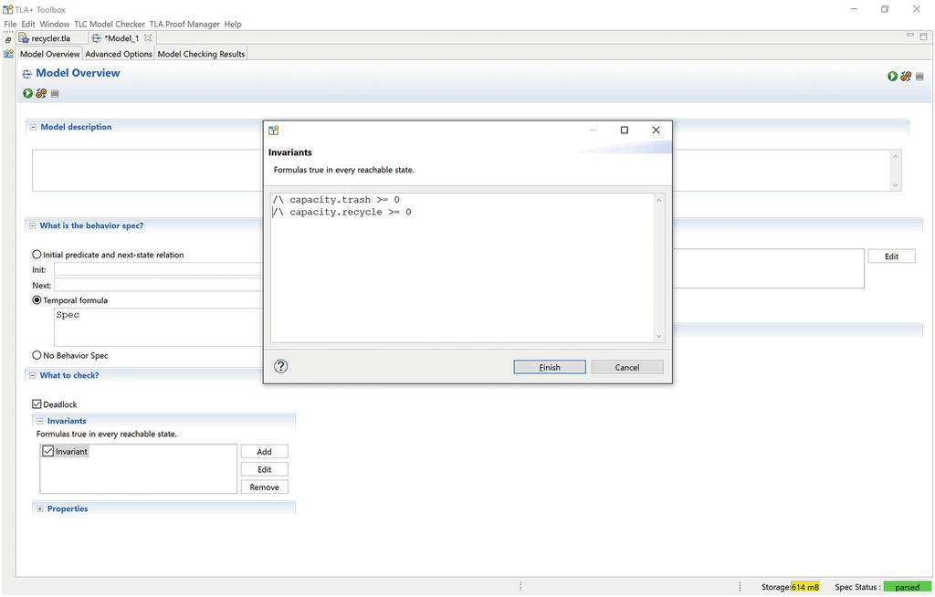

图 3-2

内联表达式

An inlined expression

### 逻辑运算符

### Logical Operators

利用不变量，我们可以表达诸如“还有剩余容量”或“箱子里的物品数量与计数相符”之类的简单属性。通常，我们需要表达更复杂的属性，无论是设置、条件语句还是不变量。我们可以使用两组运算符（每组两个运算符，一组用于布尔值，另一组用于集合）来显著增强表达能力。

With invariants, we can express simple properties like “there is some capacity left,” or “the number of items in the bin matches the count.” Often we want to express more complex properties, either for setups, conditionals, or invariants. We can significantly increase our expression power with two sets of two operators, one for Booleans and one for sets.

#### \A和\E

#### \A and \E

\A表示“集合中的所有元素”。它的使用形式为\A x \in set: P(x)，意思是“对于集合中的所有元素，P(x) 都为真”。以下是如何利用它来检查集合中的所有数字是否都小于给定的数字：

`AllLessThan(set, max) == \A num \in set: num < max>> AllLessThan({1, 3}, 4)TRUE>> AllLessThan({1, 3}, 2)FALSE>> AllLessThan({1, 3}, "FOO")[Error]`

\E表示“集合中存在某个元素”。它的使用形式为\E x \in set: P(x)，意思是“集合中至少存在一个元素使得 P(x) 为真”。例如，以下是如何检查给定序列中至少有一个元素属于给定集合的方法：

`SeqOverlapsSet(seq, set) == \E x \in 1..Len(seq): seq[x] \in set>> SeqOverlapsSet(<<1, 3>>, {2, 3, 4})TRUE`

### 笔记

### Note

如果集合为空，则无论你的表达式是什么， \E都将为假，\A都将为真。

If the set is empty, \E will be false and \A will be true, regardless of your expression.

我们可以用~\E表示“集合中没有元素”，用~\A表示“集合中并非所有元素”。\A和\E被称为**量词**。

We can write both ~\E for “there is no element in the set” and ~\A for “not all elements in the set.” \A and \E are called **quantifiers**.

定义多值量词时，有一些额外的语法糖。例如，“可交换”运算符是指参数顺序无关紧要的运算符。如果我们想检查一个运算符是否对某个集合满足可交换性，我们需要测试集合中的每一对值，交换输入顺序后调用该运算符是否仍然得到相同的值。这意味着要对两个值进行量化，而不是对一个值。我们可以用几种不同的方式来表达这一点：

```
\* We can pull multiple elements from the setIsCommutativeOver(Op(_, _), S) ==  \A x, y \in S: Op(x, y) = Op(y, x)\* We can have sequential clauses to the quantifierIsCommutativeOver(Op(_, _), S) ==  \A x \in S, y \in S: Op(x, y) = Op(y, x)\* We can "unpack" a tupleIsCommutativeOver(Op(_, _), S) ==  \A <<x, y>> \in S \X S: Op(x, y) = Op(y, x)








                      >> IsCommutativeOver(LAMBDA x, y: x + y, 1..10)TRUE>> IsCommutativeOver(LAMBDA x, y: x - y, 1..10)FALSE
```

#### =>和<=>

#### => and <=>

P => Q表示如果 P 为真，则 Q 也为真。反之则不然*。*换句话说，它等价于写成~P \/ Q。通常，当你只想在满足前提条件的情况下检查某个命题是否为真时，会使用这种写法。

P => Q means that if P is true, then Q is true. This does *not* go both ways. In other words, it’s equivalent to writing ~P \/ Q. Usually you use it when you only want to check for something being true when the preconditions are satisfied.

P <=> Q表示P 和 Q*要么*都为真，要么都为假。它可以用来检查两个布尔表达式是否等价。

`Xor(A, B) == (~A /\ B) \/ (A /\ ~B)OtherXor(A, B) == ~A <=> B>> \A A \in BOOLEAN, B \in BOOLEAN: Xor(A, B) = OtherXor(A, B)TRUE`

这里需要记住的是，BOOLEAN = {TRUE, FALSE}。

Recall here that BOOLEAN = {TRUE, FALSE}.

这里有个小陷阱：这两个运算符都遵循有效空格的连接规则。如果我写

`/\ P/\ Q=> R`

TLC 会将其解释为(P /\ Q) => R，而如果我写

`/\ P/\ Q => R`

TLC 会将其解释为P /\ (Q => R)。

TLC will interpret it as P /\ (Q => R).

### 表达式

### Expressions

我们一直在隐式地使用很多表达式。现在让我们增强它们的功能。所有这些关键字都可以用作任何表达式的一部分。这意味着在 PlusCal 算法中赋值变量时，您可以自由地使用一个位于IF语句内部的LET语句，而这个IF 语句又位于另一个LET 语句内部。

We’ve been implicitly using a lot of expressions. Let’s make them more powerful. All of these keywords can be used as part of any expression. This means that when assigning a variable in a PlusCal algorithm, you’re free to use a LET statement that’s inside an IF that’s inside another LET.

#### 允许进入

#### LET-IN

任何表达式都可以使用LET-IN向该表达式本身添加局部运算符和定义。

`RotateRight(seq) == LET last == seq[Len(seq)] first == SubSeq(seq, 1, Len(seq) - 1) IN <<last>> \o first>> RotateRight(<<1, 2, 3>>)<<3, 1, 2>>`

#### 如果-那么-否则

#### IF-THEN-ELSE

如果条件成立，则执行表达式1，否则执行表达式2。与大多数编程语言不同，所有if语句都必须包含ELSE语句。

`Max(x, y) == IF x > y THEN x ELSE y>> <<Max(2, 3), Max(3, 2)>><<3, 3>>`

### **如果……那么……**或者**如果……那么**……？

### **IF THEN** or **if then**?

TLA+ 条件语句和 PlusCal 条件语句有什么区别？ IF THEN是一个表达式，所以我们可以写成x := IF P THEN x + 1 ELSE x - 1。但是我们不能写成IF P THEN x := x + 1 ELSE x := x - 1。PlusCal版本专门用于控制流，所以它可以写成后一种情况（但不能写成前一种情况）。

What’s the difference between the TLA+ conditional and the PlusCal conditional? IF THEN is an expression, so we could do x := IF P THEN x + 1 ELSE x - 1. But we couldn’t do IF P THEN x := x + 1 ELSE x := x - 1. The PlusCal version is exclusively for control flow, so it can do the latter (but not the former).

#### 案件

#### CASE

案例陈述。后续案例用[]标记。

`CASE x = 1 -> TRUE [] x = 2 -> TRUE [] x = 3 -> 7 [] OTHER -> FALSE`

OTHER是默认值。如果没有匹配的 case 且没有默认值，TLC 会将其视为错误。如果有多个 case 语句匹配，则行为未定义。在 TLC 的当前实现中，它会选择第一个匹配的语句，但不要依赖此行为，请确保您的语句互斥。

OTHER is the default. If none of the cases match and there is no default, TLC considers that an error. If more than one case statement matches, the behavior is undefined. Under the current implementation of TLC, it will select the first matching statement, but don’t count on it and make sure your statements are mutually exclusive.

#### 选择

#### CHOOSE

CHOOSE x \in S : P(x)表示“选择一个 x 使得 P(x) 为真”。如果存在多个匹配的 x，TLC 将选择任意一个（在实现上，选择它找到的第一个匹配的 x）。如果没有匹配的 x，TLC 将引发错误。

`IndexOf(seq, elem) == CHOOSE i \in 1..Len(seq): seq[i] = elem>> IndexOf(<<8, 3, 1>>, 3)2>> IndexOf(<<8, 3, 1>>, 4)Attempted to compute the value of an expression of formCHOOSE x \in S: P, but no element of S satisfied P.`

CHOOSE与我们的逻辑运算符结合使用时，功能会变得异常强大。Max的标准表达方式如下：

`Max(set) == CHOOSE x \in set: \A y \in set: x >= y>> Max(1..10)10`

在大多数语言中，我们需要使用循环或递归函数来计算最大值（或者使用语言原语）。而在 TLA+ 中，我们只需说“从集合中选择一个比其他元素都大的元素”。就这么简单。

In most languages we’d have to either use a loop or a recursive function to compute the max (or use a language primitive). In TLA+, we simply say “CHOOSE an element of the set that’s bigger than the rest of them.” That’s it.

一个更复杂的例子：x 和 y 取何值才能满足方程组 2x *+* y *=* −2 和*3x* − 2y *=* 11？我们不需要设计算法来解代数方程，因为我们可以使用CHOOSE 函数：

`>> CHOOSE <<x, y>> \in (-10..10) \X (-10..10):>> /\ 2*x + y = -2>> /\ 3*x - 2*y = 11<<1, -4>>`

## 函数

## Functions

TLA+ 中的最后一个复杂数据类型是**函数**。函数 将一组输入（其**定义域**）映射到一组输出。映射关系可以手动设置，也可以通过表达式设置。所有函数都具有[x \in set |-> P(x)]的形式。例如，将一组数字中的每个元素映射到其对应的双精度浮点数的函数可以写成[x \in numbers |-> x * 2]。函数中也可以使用多个元素：[x, y \in set |-> P(x, y)]和[x \in set1, y \in set2 |-> Q(x,y)]都是有效的语法。

The last complex data type in TLA+ is the **function**. A function maps a set of inputs (its **domain**) to a set of outputs. The mapping can either be set manually or via an expression. All functions have the form [x \in set |-> P(x)]. A function that maps every element in a set of numbers to its double might be written as [x \in numbers |-> x * 2]. You can also use multiple elements in a function: [x, y \in set |-> P(x, y)] and [x \in set1, y \in set2 |-> Q(x,y)] are both valid syntax.

要调用函数，你可以写成`f[bar]`，就像调用元组或结构体一样。实际上，元组和结构体本质上就是函数的特例。元组是定义域为1 到 n 的函数，而结构体是定义域为字符串集合的函数。

`>> [x \in 1..2 |-> x*2]<<2, 4>>>> Head([x \in 1..2 |-> x*2])2`

### 提示

### Tip

如果f有两个值，你可以用f[a, b]和f[<<a, b>>]来调用它。

If f has two values, you can call it with both f[a, b] and f[<<a, b>>].

反过来也是如此：正如我们可以将序列和结构赋值给 PlusCal 变量一样，我们也可以赋值函数。这意味着我们可以用它们来表示计数器、标志等数据结构。

`Flags == {"f1", "f2"}(*--algorithm flagsvariables flags = [f \in Flags |-> FALSE];begin with f \in Flags do flags[f] := TRUE; end with;end algorithm; *)`

它有五种状态，其中三种状态是不同的。执行时，TLC 会将其中一个标志位设置为真，而将另一个标志位保持为假。

This has five states, three of which are distinct. On execution, TLC will set one of the flags to true while leaving the other false.

### 函数和运算符

### Functions and Operators

你可以将函数作为运算符使用。如果运算符不接受任何参数，则以下两种语法是有效的：

`Op == [x \in S |-> P(x)]Op[x \in S] == P(x)`

但是，如果运算符根据其参数定义一个函数，则需要使用第一种语法。

`MapToSomeNumber(set, num) == [x \in set |-> num]`

运算符和函数之间存在一些关键区别。运算符可以处理任意输入，而函数必须具有指定的定义域。函数可以由运算符创建并传递，并且它们不受递归或高阶运算符的限制。

`SumUpTo(n) == LET F[m \in 0..n] == IF m = 0 THEN 0 ELSE m + F[m-1] IN F[n]>> SumUpTo(10)55`

在PT辅助库中，我们还提供了`ReduceSet` 函数，你可以用它来使运算符对集合进行递归运算。这“隐藏”了函数的内部使用情况。你可以查看它的实现方式，但不必过于纠结于完全理解；毕竟，这就是我们创建包装器的原因。

`PT == INSTANCE PTSumUpTo(n) == PT!ReduceSet(LAMBDA x, y: x + y, 0..n, 0)>> SumUpTo(10)55`

### 笔记

### Note

如果您尚未导入 PT 文件，请立即导入。我们之后会经常用到它。您可以在简介末尾找到相关说明。

If you haven’t imported PT yet, do so now. We’ll be using it regularly from here on out. You can find the instructions at the end of the introduction.

我们有一些特殊的运算符可以用来操作函数。

There’s a few special operators we get for manipulating functions.

#### 领域

#### DOMAIN

DOMAIN 是一个特殊的前缀运算符，它给出函数可能的输入集合。如果func == [x \in set |-> ...]，则DOMAIN func = set。由于序列和结构体也是函数的一种形式，我们也可以在它们上使用 DOMAIN。DOMAIN seq = 1..Len(seq)。DOMAIN struct是结构体中键的集合。

`F[x \in BOOLEAN] == xG == <<6, 0, 9>>H == [F |-> DOMAIN F, G |-> DOMAIN G]>> H[F |-> {FALSE, TRUE}, G |-> 1..3]>> DOMAIN H{"F", "G"}`

#### @@

#### @@

f @@ g合并了两个函数。如果某个元素x同时属于两个定义域，则我们使用f[x]。这与以下定义相同：

`Merge(f, g) == [ x \in (DOMAIN f) \union (DOMAIN g) |-> IF x \in DOMAIN f THEN f[x] ELSE g[x] ]`

要使用@@，我们需要EXTENDS TLC。

`EXTENDS TLCf[x \in 1..2] == "a"g[x \in 2..3] == "b">> f @@ g<<"a", "a", "b">>>> g @@ f<<"a", "b", "b">>`

#### :>

#### :>

要使用:>，我们需要EXTENDS TLC。a : > b是函数[x \in {a} |-> b]。

`>> (2 :> 3)[2]3>> ("a" :> "b").a"b"`

### 函数集

### Sets of Functions

[set1 -> set2]表示将 set1 中的元素映射到 set2 中的元素的所有函数的集合。**我们用** -> **表示这个集合，而不是** |->。|->用于表示函数，而不是函数集合。你很可能会至少两次弄错。

`>> [s \in {"a", "b"} |-> {1, 2}][a |-> {1, 2}, b |-> {1, 2}]>> [{"a", "b"} -> {1, 2}]{ [a |-> 1, b |-> 1], [a |-> 1, b |-> 2], [a |-> 2, b |-> 1], [a |-> 2, b |-> 2] }`

随着我们编写越来越复杂的规范，函数集将变得越来越有用。一个直接的应用是，我们可以用它来创建序列集。在 Recycler 中，我们将项目列表定义为item \X item \X item \X item。如果我们想尝试六个项目，或者所有可能小于等于某个数量的列表，该怎么办？如果手动编写代码，会很笨拙，而且难以修改。“可变序列”的情况更是完全不可能实现。我们真正需要的是一个形如SeqOf(set, count)的运算符，它可以为我们生成所有这些列表。

Sets of functions will be increasingly useful as we write more complex specs. As an immediate use, we can use it to make sets of sequences. In the recycler, we defined the list of items as item \X item \X item \X item. What if we wanted to try with six items, or all possible lists up to some number? If we’re hand-coding it, it’s clumsy and difficult to change. And the “variable sequence” case is outright impossible. What we really want is some operator of form SeqOf(set, count) that can generate all of these for us.

这里我们可以利用序列本质上是具有特定定义域的函数这一事实。事实上，TLC 会将定义域为1..N的函数显示为序列！[x \in 1..3 |-> P(x)]就是序列<<P(1), P(2), P(3)>> 。那么，函数集[1..3 -> S]就是所有满足以下条件的序列：第一个值是S 中的*某个*元素，第二个值是 S 中的某个元素，以此类推，直到第三个值也是 S 中的*某个*元素。换句话说，它是S \XS \XS。

`SeqOf(set, count) == [1..count -> set]>> SeqOf({"a", "b", "c"}, 2){ <<"a", "a">>, <<"a", "b">>, <<"a", "c">>, <<"b", "a">>, ... }`

我们还可以利用这一点来扩展规范的初始状态空间。在上面的 PlusCal 示例中，我们最初将所有标志都设为 false。如果我们还想规范某些标志初始为 true 的情况，该怎么办呢？使用函数集，只需进行很小的改动：

`Flags == {"f1", "f2"}(*--algorithm flagsvariables flags \in [Flags -> BOOLEAN]begin \* . . .`

现在它有 15 个状态。与任何集合一样，我们可以对函数集进行映射和过滤。这样，我们就可以将规范限制为仅包含*至少*一个标志为真的初始状态：

`flags \in {config \in [Flags -> BOOLEAN]: \E f \in Flags: config[f]}`

This passes with 12 states.

接下来我们来看一个更复杂的函数示例。

Let’s move on to a more involved example of functions.

## 例子

## Example

背包*问题*是一个已知的NP完全优化问题。我们可以将其定义为：*我们有一个容量为N的背包和一组物品。每个物品都有一个价值和一个大小。你可以将任意数量的每种物品放入背包，只要所有物品价值的总和小于背包的容量即可。你能制作出价值最高的背包吗？*

The *Knapsack Problem* is an optimization problem that’s known to be NP-complete. We can define it as: *We have a knapsack of volume N and a set of items. Each item has a value and a size. You can fit any number of each item in the knapsack as long as the sum of them all is less than the capacity of the sack. What’s the most valuable knapsack you can make?*

实际上，*解决*这个问题对我们来说并不重要：这是一个算法问题，而不是规范问题。相反，我们将展示如何使用 TLA+ 运算符正式*定义*最有价值的背包。我们不让算法找到它，而是创建一个运算符，它本身*就是*答案。

Actually *solving* this problem is uninteresting to us: that’s an algorithms question, not a specification one. Instead, we will show how we can formally *define* the most valuable knapsack with TLA+ operators. Instead of having an algorithm find it, we create an operator that simply *is* the answer.

首先，我们来确定输入是什么，先通过硬编码，然后再进行泛化。我们将可能的输入项定义为一个字符串集合，并将最大容量定义为一个数字。

`EXTENDS TLC, Integers, SequencesPT == INSTANCE PTCapacity == 7Items == {"a", "b", "c"}`

如果每个元素都有一个大小和一个值，我们可以将其表示为一个结构体，例如[大小：2..4，值：0..5]。那么，有两种方法可以表示问题的输入。第一种方法是使用一组结构体，每个结构体包含一个元素、一个值和一个大小。

`HardcodedItemSet == { [item |-> "a", size |-> 1, value |-> 1], [item |-> "b", size |-> 2, value |-> 3], [item |-> "c", size |-> 3, value |-> 1]}`

这种方法可行，但存在一些问题。首先，很难找到给定项的值。我们需要编写类似这样的代码：

`ValueOf(item) == (CHOOSE struct \in HardcodedItemSet: struct.item = item).value>> ValueOf("a")1`

更糟糕的是，没有任何机制可以阻止无效数据。如果我有两个结构体，它们包含*相同的*项但值不同呢？这样一来，我们的问题就存在无效输入，导致出现毫无意义的结果。更好的办法是将输入定义为项名称到其大小和值的映射：

`HardcodedItemSet == [ a |-> [size |-> 1, value |-> 1], b |-> [size |-> 2, value |-> 3], c |-> [size |-> 3, value |-> 1]]`

现在`ValueOf(item)`就是`HardcodedItemSet[item].value`，并且我们保证所有项的名称都不同。这样就简单多了。我们可以先通过创建一组结构体来概括输入，这些结构体表示一个项可以拥有的所有值：

`ItemParams == [size: 2..4, value: 0..5]ItemSets == [a: ItemParams, b: ItemParams, c: ItemParams]`

键只是集合Items的元素，值只是集合ItemParams的元素。这代表了所有可能的项值配置。但是我们硬编码了 a、b 和 c，所以如果我们更改Items，ItemSets就不准确了。我们可以使用函数集来解决这个问题：

`ItemSets == [Items -> ItemParams]`

记住，这里是->，不是|->。尝试将ItemSets作为常量表达式求值，看看它包含什么。对于任何给定的问题，我们都会处理该集合中的一个元素；我们称之为ItemSet。

Remember, that’s a ->, not a |->. Try evaluating ItemSets as a constant expression to see what it consists of. For any given problem, we’d be working on a single element of that set; call it ItemSet.

这样我们就得到了我们关心的可能输入。接下来，我们需要衡量什么样的背包才算有效。我们可以将背包表示为一个函数[Items -> Count]，该函数表示背包中包含的每种物品的数量。例如，背包[a |-> 1, b |-> 2, c |-> 0]包含一个a、两个b，但没有c。

That gives us the possible inputs we care about. Next, we need a measure of what counts as a valid knapsack. We can represent a knapsack as a function in [Items -> Count], representing how many of each item the knapsack contains. For example, the knapsack [a |-> 1, b |-> 2, c |-> 0] contains a single a, two b’s, and no c’s.

为了便于解释和模型检验，我们将每种物品的最大数量任意限制为 4。那么所有背包的集合将是[物品 -> 0..4]。

We’ll arbitrarily cap the maximum number of each item at 4 for the sake of explanation and for model-checking purposes. Then the set of all knapsacks would be [Items -> 0..4].

但并非所有这些方法都有效。请记住，所有物品尺寸的总和必须小于背包的容量。对于给定的背包，给定物品的总尺寸为ItemSet[item].size * knapsack[item]。我们需要计算背包中所有物品尺寸的总和，这可以使用PT!ReduceSet函数来实现。

`KnapsackSize(sack, itemset) == LET size_for(item) == itemset[item].size * sack[item] IN PT!ReduceSet(LAMBDA item, acc: size_for(item) + acc, Items, 0)ValidKnapsacks(itemset) == {sack \in [Items -> 0..4]: KnapsackSize(sack, itemset) <= Capacity}`

由此，我们可以定义“最佳”有效背包：它的价值最高。我们计算价值的方式与计算容量的方式完全相同。

`\* A minor amount of duplicate codeKnapsackValue(sack, itemset) == LET value_for(item) == itemset[item].value * sack[item] IN PT!ReduceSet(LAMBDA item, acc: value_for(item) + acc, Items, 0)BestKnapsack(itemset) == LET all == ValidKnapsacks(itemset) IN CHOOSE best \in all: \A worse \in all \ {best}: KnapsackValue(best, itemset) > KnapsackValue(worse, itemset)`

让我们用这个方法来测试一下硬编码的例子。

`>> BestKnapsack(HardcodedItemSet)[a |-> 1, b |-> 3, c |-> 0]>> KnapsackValue([a |-> 1, b |-> 3, c |-> 0], HardcodedItemSet)10`

看起来不错。但我们应该测试一下，看看它是否适用于所有可能的物品集。

`>> {BestKnapsack(itemset) : itemset \in ItemSets}Attempted to compute the value of an expression of formCHOOSE x \in S: P, but no element of S satisfied P.`

为什么没有任何方法能满足要求？在这种情况下，我们没有任何信息来确定是*哪个*项集导致了问题。为了便于调试，我们将其改为 PlusCal 算法，以便获得跟踪信息。

`(*--algorithm debugvariables itemset \in ItemSetsbegin assert BestKnapsack(itemset) \in ValidKnapsacks(itemset);end algorithm; *)`

由于我们要添加 PlusCal 规范，请记住删除“计算常量表达式”并将“行为规范是什么？”设置为“时间公式”。运行此程序后，您应该会得到类似图3-3所示的结果。

[figure not shown]

图 3-3

错误

The error

如果所有物品都没有价值，那么所有背包的价值都相同，没有哪个背包的价值*高于*其他所有背包。

If none of the items have any value, then all knapsacks have the same value and there is no knapsack with a value *greater* than all the others.

我们可以把运算符改成使用>=，但这并非我们真正想要的！记住，如果多个元素满足 CHOOSE 条件，它会*随机*选择一个。这样就等于说两个背包的价值完全相同，其中一个就“更好”了。这是错误的。或者，我们可以添加一个“决胜条件”，比如选择物品数量最少的那个。但这在这里行不通（所有物品的大小和价值都相同），而且无论如何，我们现在都在修改核心定义来适应我们的运算符。定义本身并没有决胜条件，所以我们不应该添加。

We could change our operator to use >=, but that’s not actually what we want! Remember, if multiple elements satisfy a CHOOSE, it picks an *arbitrary* one. Then we’re saying that two knapsacks have the exact same value, and one is arbitrarily “better” than the other. So that’s wrong. Alternatively, we could add a “tie breaker,” such as the fewest items. But that doesn’t work here (all of the items have the same size and value) and regardless we’re now modifying the core definition to fit our operator. The definition doesn’t have a tie breaker, so we should not add one.

因此，最佳方案是返回所有不同的最佳背包组合，而不是仅仅返回一个任意的组合。我们可以通过两种方式实现这一点：

1. 1.

   选择一组有效的背包，其价值高于该集合之外的所有其他背包。这最符合“最佳背包”的定义。
2. 1.

   Choose the subset of valid knapsacks that are higher than everything outside of that set. This most closely matches the defintion of “best knapsacks.”

`BestKnapsacksOne(itemset) == LET all == ValidKnapsacks(itemset) IN CHOOSE all_the_best \in SUBSET all: \A good \in all_the_best: /\ \A other \in all_the_best: KnapsackValue(good, itemset) = KnapsackValue(other, itemset) /\ \A worse \in all \ all_the_best: KnapsackValue(good, itemset) > KnapsackValue(worse, itemset)`

1. 2.

   随意选择一个最佳背包，计算其价值，然后筛选出所有其他与之匹配的背包。这种方法更易于理解，速度也更快。
2. 2.

   Pick a best knapsack arbitrarily, calculate its value, and filter for all the other knapsacks that match it. This is more understandable and faster, too.

`BestKnapsacksTwo(itemset) == LET all == ValidKnapsacks(itemset) best == CHOOSE best \in all: \A worse \in all \ {best}: KnapsackValue(best, itemset) >= KnapsackValue(worse, itemset) value_of_best == KnapsackValue(best, itemset) IN {k \in all: value_of_best = KnapsackValue(k, itemset)}`

我更倾向于使用更简单的那个，但为了确保万无一失，我们还是应该确保它对所有可能的项目集都与前者匹配。

`Capacity == 4 \* To reduce the state space for faster testing>> \A is \in ItemSets: BestKnapsacksTwo(is) = BestKnapsacksOne(is)FALSE`

嗯，这真令人惊讶。试试写下面这些代码，看看有什么不同。

`LET is == CHOOSE is \in ItemSets: BestKnapsacksTwo(is) /= BestKnapsacksOne(is)IN <<is, BestKnapsacksOne(is), BestKnapsacksTwo(is)>>`

如果你进行评估，你会发现BestKnapsacksOne会将空集设置为all_the_best，并且\A x \in S显然为真。我们还需要限定all_the_best中至少存在*某个*元素。为此，我们将\A good改为\E good：

`BestKnapsacksOne(itemset) == LET all == ValidKnapsacks(itemset) IN CHOOSE all_the_best \in SUBSET all: /\ \E good \in all_the_best: /\ \A other \in all_the_best: KnapsackValue(good, itemset) = KnapsackValue(other, itemset) /\ \A worse \in all \ all_the_best: KnapsackValue(good, itemset) > KnapsackValue(worse, itemset)`

现在两者等效了。为了确保万无一失，我分别运行了它们，并确认在容量为7的情况下， BestKnapsacksTwo的确更快。最后，为了简化代码，我们使用内联运算符移除了所有KnapsackValue调用。

`BestKnapsacks(itemset) == LET value(sack) == KnapsackValue(sack, itemset) all == ValidKnapsacks(itemset) best == CHOOSE best \in all: \A worse \in all \ {best}: value(best) >= value(worse) IN {k \in all: value(best) = value(k)}`

## 概括

## Summary

我们学习了如何使用运算符、表达式和函数来编写复杂的运算符。然后，我们利用这些知识，将一个复杂的定义（一组使约束问题最大化的值）仅通过该定义本身来解决。

We learned how to use operators, expressions, and functions to write complex operators. We then used it to take a complex definition – a collection of values maximizing a constraint problem, and solve it solely through the definition.

不过，我们的背包模型规范存在一个问题，那就是我们把所有的整数值都硬编码了。与其强制容量为 7，物品大小范围为2 到 4，不如将它们指定为可配置的数字和范围，并在模型检查时才进行定义，这样会更好。此外，我们频繁使用`PT == INSTANCE PT`，现在应该好好研究一下它的实际含义了。最后，我们的规范运行速度开始变慢，如果能更方便地运行和调试就更好了。

One problem with our knapsack specification, though, is that we’ve hard-coded all of the integer values. It would be better if, instead of forcing Capacity == 7 and the range of item sizes as 2..4, we could specify them as configurable numbers and ranges and only define them when it’s time for the model checking. We’ve also been using PT == INSTANCE PT often enough that we should finally learn what that actually means. Finally, our specs are beginning to get a little slow, and it would be nice to more easily run and debug them.

下一章，我们将介绍模型常量和模块组织中的所有这些内容。

In the next chapter, we will cover all of these in model constants and module organization.

© Hillel Wayne 2018

希勒尔·韦恩实用TLA+https://doi.org/10.1007/978-1-4842-3829-5_4

# 4. 常量、模型和导入

# 4. Constants, Models, and Imports

希勒尔·韦恩<sup>1</sup>

（1）

美国伊利诺伊州芝加哥

前几章我们讲解了如何编写复杂的规范。然而，我们的模型相当僵化。例如，上一章的背包规范就包含一组硬编码的值：背包的总容量、物品的取值范围等等。本章我们将使用TLC配置来简化和通用化我们的模型，同时增加模块化和更好的调试功能。

In the past few chapters we covered how to write complex specifications. However, our models are fairly rigid. Our knapsack spec from the last chapter had a set of hard-coded values: total capacity of the knapsack, range of values for the items, etc. In this chapter we will use the TLC configuration to simplify and generalize our model, as well as add modularity and better debugging.

## 常量

## Constants

如果我们想动态地更改规范的参数该怎么办？例如，我们可能希望先在一个较小的状态空间上测试规范，以排除明显的错误，然后再在一个较大的状态空间上测试规范，以发现更细微的错误。我们可以通过添加**常量**来实现这一点，常量是在模型中而不是在规范中定义的值。添加常量的方法如下：

`EXTENDS Integers, TLCCONSTANTS Capacity, Items, SizeRange, ValueRange\* We could also do CONSTANTS Op(_, _...)`

常量可以像其他任何值一样使用。顾名思义，常量是不能修改的。

Constants can be used anywhere you’d use any other value. As you’d expect from the name, they cannot be modified.

对于任何给定的模型，我们在“模型概览”页面的“什么是模型？”部分中为常量赋值。您必须在规范中使用`CONSTANTS ConstantName`指定常量，它才会显示出来。对于常量运算符，我们只能定义运算符。对于常量值，我们有三种选择（图4-1）。

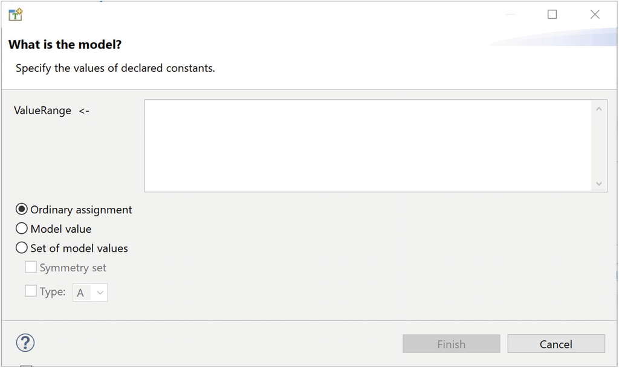

图 4-1

已声明的常量。只有当您将其定义为 CONSTANT 时，名称才会显示。

Declared constants. Names will only show up if you’ve defined them as CONSTANT.

在本文中，我们将使用C <- val指定对常量赋值。

In this text we will specify assignment to constants with C <- val.

### 普通任务

### Ordinary Assignment

我们可以将常量设置为任何其他 TLA+ 值：数字、集合、序列、函数等。

`Capacity <- 7ValueRange <- 0..3SizeRange <- 1..4Items <- {"a", "b", "c"}`

尝试使用这些值运行模型，然后探索不同的可能值。这些值是否会对我们定义的最佳背包模型造成问题？

Try running the model with these values and then exploring different possible values. Do any cause problems for our definition of BestKnapsacks?

### 模型值

### Model Values

如果将**模型值**赋给常量，则该常量将成为一种新类型，该类型仅等于它自身。如果 M 和 N 都是模型值，则M /= N。

If you assign a **model value** to a constant, that constant becomes a new type that’s only equal to itself. If M and N are both model values, M /= N.

我们将大量使用它们来添加“便捷”值，例如NULL。这是因为比较不同类型的值被认为是不符合规范的。你不能设置集合{TRUE, FALSE, "null"}，但如果NULL是一个模型值，则*可以*设置集合{TRUE, FALSE, NULL} 。

We’ll be using them a lot to add “convenience” values, like NULL. That’s because comparing values of different types is considered a spec failure. You cannot have the set {TRUE, FALSE, "null"}, but you *can* have the set {TRUE, FALSE, NULL} if NULL is a model value.

### 模型值集

### Sets of Model Values

您还可以定义一整套模型值。这必须作为“模型值集”添加，而不是作为“普通赋值”。使用常量时，模型值集通常比字符串集更可取。

`Items <- [ model value ] {i1, i2, i3}`

主要优势在于它为我们打开了**对称集**。让我们把上一章的调试算法加回来。我们需要更新它以使用BestKnapsacks，因为我们发现BestKnapsack不适用于这个问题。由于BestKnapsacks是一个集合，我们使用\subseteq而不是\in。

`(*--algorithm debugvariables itemset \in ItemSetsbegin assert BestKnapsacks(itemset) \subseteq ValidKnapsacks(itemset);end algorithm; *)`

如果你翻译这段文字并运行模型，你会发现 TLC 总共检查了大约 12,000 个状态，其中 8,000 个是不同的。然而，这些状态中的大多数对我们来说都是额外的工作。在一次运行中，如果我们把所有 i1 替换成 i2，i2 替换成 i3，i3 替换成 i1，结果都一样。这意味着这个集合是**对称的**。我们可以通过在常量弹出窗口中勾选“对称集”选项来告诉 TLC 这一点。TLC 可以利用这个信息跳过对冗余状态的检查，从而缩短运行时间。

`Items <- [ model value ] <symmetrical> {i1, i2, i3}`

### 认为

### ASSUME

如果在模型级别赋值常量，我们需要一种方法来确保你赋的是正确的值类型。如果你在规范中使用值作为一组数字，你肯定不希望有人将其赋值为字符串序列。ASSUME是一个关于常量的表达式，如果其值为 false，则会阻止规范运行。

```
CONSTANTS Capacity, Items, SizeRange, ValueRange
                      ASSUME SizeRange \subseteq 1..Capacity

                      ASSUME Capacity > 0

                      ASSUME \A v \in ValueRange: v >= 0
                    ItemParams == [size: SizeRange, value: ValueRange]ItemSets == [Items -> ItemParams]
```

尝试传入一个不可能的大小，例如SizeRange <- 0..4。您应该会看到规范立即报错“假设错误”。

Try passing in a size that should be impossible, SizeRange <- 0..4. You should see that the spec will immediately error with “Assumption is false.”

ASSUME可以使用常量和常量运算符作为表达式的一部分，但不能使用未定义为CONSTANT 的运算符。

ASSUME may use constants and constant operators as part of the expression but may not use operators not defined as CONSTANT.

#### 无限集合

#### Infinite Sets

我们目前所做的一切都是基于有限集合的。在99%的情况下，你都会用到有限集合。然而，TLA+ 也能够指定某些类型的无限集合。它不能从集合中选择元素，也不能将它们赋值给变量，但它*可以*测试元素是否属于该集合。如果我们扩展整数集，就能得到无限集合Int。我们也可以扩展自然数集，得到集合Nat == {0, 1, 2, ...}。这意味着我们可以这样写我们的假设：

```
ASSUME SizeRange \subseteq 1..Capacity
                        ASSUME Capacity \in Nat \ {0}

                        ASSUME ValueRange \subseteq Nat
```

这样就明确区分了类型，而不是隐式区分。具体采用哪种方式取决于个人偏好。

This makes the types explicit, as opposed to implicit. Which one you do is personal preference.

## TLC 运行时长

## TLC Runtime

### 配置

### Configuration

我们不会在每一页都涵盖所有内容，因为有些内容用途较为特殊，有些内容则超出本文范围。您可以在“帮助 > 目录”下查看所有内容的功能。以下是一些重要内容 （图4-2）。

We won’t cover everything on each page, because some of it is for niche purposes and some of it is out of scope. You can see what everything does under the “Help > Table of Contents.” Here are the important things (Figure 4-2).

- **什么是** **行为规范**：我们几乎总是选择“时间公式”。有时，如果 PlusCal 编译失败，它会自动更改为“无行为规范”。我们使用“无行为规范”来测试表达式，而无需运行任何代码。
- **What Is the** **Behavior Spec** : We almost always want “Temporal Formula” selected. Sometimes, if PlusCal fails to compile, it automatically changes to “No Behavior Spec.” We use “No Behavior Spec” to test expressions without running anything.
- **检查****内容**：*死锁*将在下一章学习并发时进行讲解。*不变量*用于放置安全不变量——几乎涵盖了我们目前测试过的所有内容。*属性*用于放置活性属性——我们将在第6章中介绍。

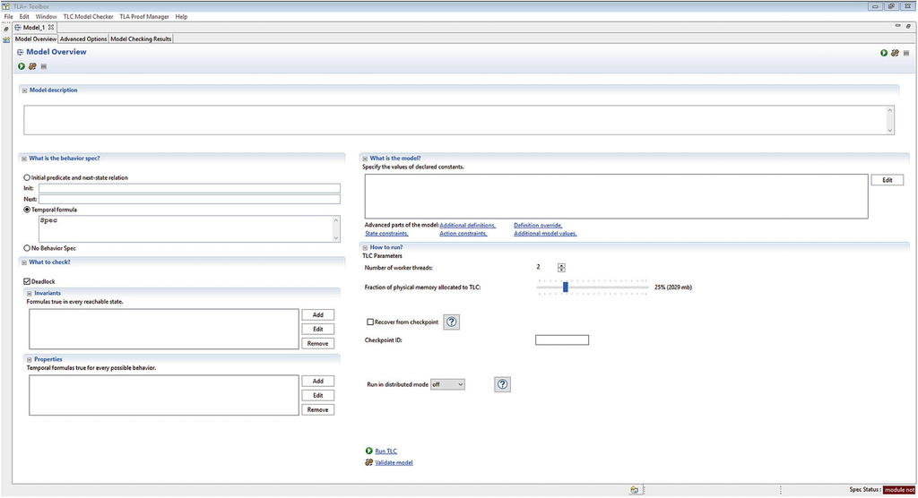

  图 4-2

  模型概述

- **What to** **Check** : *Deadlock* will be relevant in the next chapter, when we learn about concurrency. *Invariants* are where we place safety invariants – pretty much everything we’ve tested so far. *Properties* is where we place liveness properties – we’ll cover that in Chapter 6.

  Figure 4-2

  Model Overview

- **运行方式**：这里我们进行运行时优化，以加快 TLC 的运行速度。本书不会用到它，但您可以在工具箱帮助中了解更多相关信息。参见图4-3。

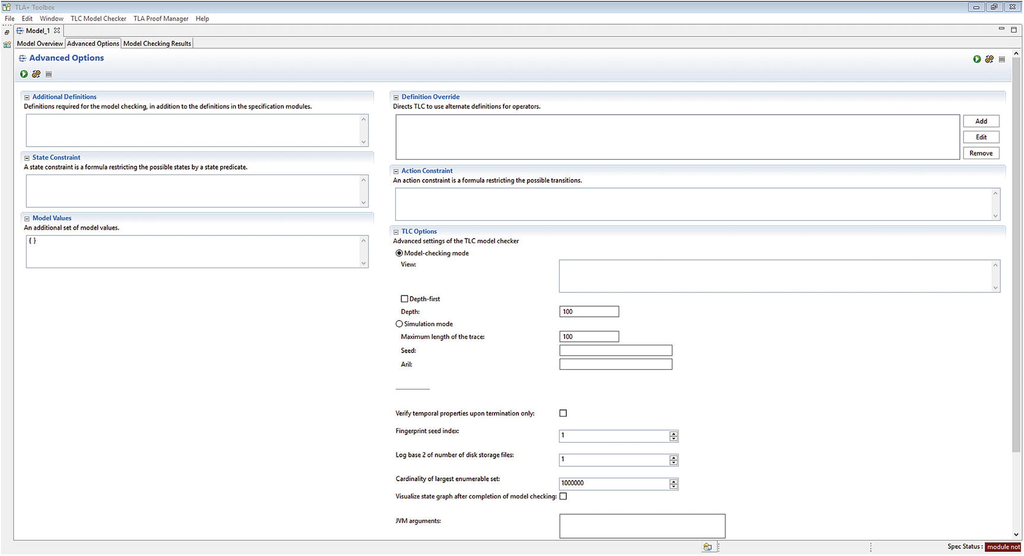

  图 4-3

  高级选项

- **How to Run**: Here’s where we do runtime optimizations to make TLC faster. We will not be using it in this book, but you can learn more about them in the Toolbox help. See Figure 4-3.

  Figure 4-3

  Advanced Options

- **附加定义** ：我们可以在这里添加额外的运算符，以便与状态约束和常量定义一起使用。例如，我们可以定义运算符F(x) == x*2，然后对于某个常量 C，进行普通赋值C <- F(1)。当我们需要对常量进行复杂的设置时，这将非常有用。
- **Additional Definitions** : We can add extra operators here to use with state constraints and defining constants. For example, we could define the operator F(x) == x*2 and then, for some constant C, make the ordinary assignment C <- F(1). It can come in handy if we need to do complex setups for our constants.
- **状态约束** ：一个对模型中所有状态都成立的表达式。与不变量不同，违反状态约束不会*导致*模型失效。TLC 会将该状态从搜索中移除。它不会检查该状态的任何不变量，也不会基于该状态预测任何后续状态。我们可以利用这一点来缩小探索空间，更快地完成模型检查，但代价是可能会遗漏一些不变量。我们还可以利用这一点将无界模型转换为有界模型。

  *动作约束的*功能类似，但超出了我们的讨论范围。
- **State Constraint** : An expression that will hold true for all states in our model. Unlike invariants, state constraint violations do *not* fail the model. Rather TLC will drop that state from the search. It will not check any invariants on that state, and it will not determine any future states from it. We can use this to prune the exploration space and finish model checking faster, at the cost of potentially missing invariance violations. We can also use this to turn an unbounded model into a bounded one.

  *Action Constraint* does something similar but is out of scope for us.
- **定义** **覆盖**：此功能允许您用自定义定义替换任何定义。例如，如果您想捉弄一下朋友，可以覆盖+(x, y) <- 3 。
- **Definition** **Override** : This lets you replace any definition with a custom one. For example, you could override +(x, y) <- 3 if you wanted to mess with your friends.

### 为什么要覆盖？

### WHY OVERRIDE?

覆盖的主要用途是让规范能够表示无限的可能性。如果我写

`with x \in ValueRange do skip;end with;`

然后定义常量ValueRange <- 1..10，读者可能不确定我的规范“应该”是适用于任意数字还是有界 ValueRange。因此，有些人更喜欢这样写。

`with x \in Int do skip;end with;`

然后添加重写Int <- 1..10。不过，本书中我们不会采用这种做法。

and then add the override Int <- 1..10. We are not going to follow this practice in this book, though.

- **TLC 选项** ：最有趣的是各种模式。默认情况下，我们使用*广度优先搜索进行模型检查*。我们可以将其更改为深度优先搜索。如果您的规范不是有限的，例如包含一个不断递增的计数器，这将非常有用。然而，即使是许多无限的规范也可以通过 TLC 进行模型检查，通常情况下，最佳选择是使用状态约束。*仿真模式*会将系统搜索替换为随机轨迹。这通常效率较低，但如果您已在较小的状态空间上验证了规范，现在想要在非常大的状态空间上对其进行压力测试，则有时此模式非常有用。
- **TLC Options** : The interesting ones are the modes. By default we are in *Model-checking mode* using a breadth-first search. We can change it to depth-first. This can be useful if your specification isn’t finite, such as if it has a constantly incrementing counter. However, even many infinite specs can be model checked by TLC, and often your best choice is to use a state constraint instead. *Simulation Mode* will replace the methodical search with random traces. This is generally less effective but can sometimes be useful if you’ve validated the specification over a small state space and now want to stress test it with a very large state space.

### 错误跟踪

### Error Traces

您已经了解并学会了如何解读错误跟踪信息。现在我们将介绍它的一个新用途：**错误跟踪探索**。它位于错误输出和错误跟踪信息之间。在这里，您可以向跟踪信息中注入任意表达式，并对其进行求值以进行调试。如果您添加了一个表达式，您应该可以看到该表达式在错误跟踪信息的每个步骤中都被求值。点击“恢复”即可移除该表达式。

You’ve seen and learned how to interpret error traces already. Now we’ll cover a new use: the **Error-Trace Exploration**. You’ll find it collapsed between the error output and the error trace. Here’s where you can inject arbitrary expressions into your trace and evaluate it for debugging. If you add an expression, you should see that evaluated for every step of the error trace. Click “Restore” to remove the expression.

错误跟踪还有一个非常强大的功能。每个表达式都使用步骤开始时的值。通过添加单引号 ( ' )，我们可以让它计算步骤结束时的*值*。这称为**带撇号的**值。如果我写Op(x', y)，它会计算 x 在该步骤中发生变化后 Op 的值。这同样适用于运算符：如果我写Op(x, y)'，它会计算*Op 的输出*变为什么值。附录 C 将详细介绍带撇号的值的理论。

There’s one additional and extremely powerful thing you can do with the error trace. Every expression uses the values it has at the beginning of the step. By adding a ' (single quote), we can instead ask it to evaluate what it is at the *end* of the step. This is called a **primed** value. If I write Op(x', y), it will evaluate what Op is after x changes in that step. This also works on operators, too: If I write Op(x, y)', it will evaluate what *Op’s output* changed to. We cover more on the theory of primed values in Appendix C.

### 警告

### Warning

两个带引号的运算符不能嵌套。`SumItemsOver (knapsack', "value")'`会报错。

You can’t nest two primed operators. SumItemsOver(knapsack', "value")' is an error.

### TLC模块

### The TLC Module

除了@@和:>之外，TLC 还提供了几个实用运算符。它们的特殊之处在于，它们的实现方式与形式化定义有所不同。这些实用运算符用于调试。

In addition to @@ and :>, TLC provides us with several utility operators. What makes them special is that they have overridden implementations distinct from their formal definitions. They are used for debugging.

#### 打印和打印T

#### Print and PrintT

Print(val, out)将val和out打印到用户输出，然后计算out 的值（图4-4）。

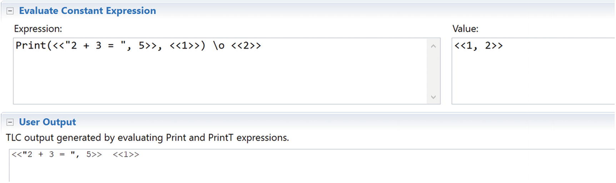

图 4-4

打印

Print

`PrintT(val)` 等价于编写`Print(val, TRUE)`。为了方便日志记录，TLC 还提供了`JavaTime`，其值等于当前 Unix 时间戳。

PrintT(val) is equivalent to writing Print(val, TRUE). To help with logging, TLC also provides JavaTime, which evaluates to the current epoch time.

#### 断言

#### Assert

如果 val 为TRUE ，则Assert(val, out)的结果为TRUE。如果 val 为 false，则测试失败并输出out。PlusCal关键字assert是根据Assert定义的。

`>> Assert(3 < 5, "3 is more than 5")TRUE>> Assert(3 > 5, "3 is more than 5")The first argument of Assert evaluated to FALSE; the second argument was:"3 is more than 5"`

如果要在断言中添加详细信息，一种快速的方法是使用元组或结构体：

`>> LET x == 3 y == 5 IN Assert(x > y, <<x, " is more than ", y>>)The first argument of Assert evaluated to FALSE; the second argument was:<<3, " is more than ", 5>>`

如果你想要更精细的处理，可以使用 TLC 辅助函数ToString(_)：

`>> LET x == 3 y == 5 IN Assert(x > y, ToString(x) \o " is more than " \o ToString(y))The first argument of Assert evaluated to FALSE; the second argument was:"3 is more than 5"`

#### 排列和排序序列

#### Permutations and SortSeq

Permutations(set)是集合set的所有可能排序方式的集合。SortSeq (seq, Op(_, _))顾名思义，根据Op对序列进行排序。

`>> Permutations({1, 2, 3}){ <<1, 2, 3>>, <<1, 3, 2>>, <<2, 1, 3>>, <<2, 3, 1>>, <<3, 1, 2>>, <<3, 2, 1>> }>> SortSeq(<<1, 2, 3>>, LAMBDA x, y: x > y)<<3, 2, 1>`

除此之外，我们还可以利用这一点来强制集合具有任意顺序。

`>> CHOOSE seq \in Permutations({1, 2, 3}): TRUE<<1, 2, 3>>`

## 进口

## Imports

一个规范可以包含多个模块。您创建的第一个模块是*主*模块 ，也是唯一运行的模块。其他模块可以为规范提供新的运算符、值和数据结构。

A specification can have multiple modules. The first module you create is the *main* module and the only one that is run. Other modules can provide new operators, values, and data structures to the specification.

您可以通过依次选择“文件”>“打开模块”>“添加 TLA+ 模块”在规范中创建一个新模块。您还可以将默认位于库路径中的任何模块包含在规范中。

You can create a new module in your spec by going to File > Open Module > Add TLA+ Module. You can also include any modules in your spec that are in your library path by default.

新模块不应包含任何 PlusCal 组件；它仅用于运算符。但是，它可以包含常量，这些常量将在导入时定义。

The new module should not contain any PlusCal; it is for operators only. It may, however, have constants, which we then define on import.

导入模块有两种方式：EXTENDS和INSTANCE。前者可以一次列出多个模块，而后者一次只能导入一个模块。两种方式都不能导入以LOCAL开头的运算符或实例。

There are two ways to import modules: EXTENDS and INSTANCE. The former can list multiple modules at once, while the latter only imports one at a time. Neither will import operators or instances prepended with LOCAL.

工具箱需要先了解该模块才能导入它。它通过以下三种方式之一发现模块：

1. 1.

   Toolbox 会自动识别与规范其余部分位于同一文件夹中的所有模块，并且默认情况下可以导入它们。
2. 1.

   The Toolbox automatically knows about all modules in the same folder as the rest of your spec, and you can import them by default.
3. 2.

   我们可以像本书引言中那样，在“首选项”>“TLA+首选项”下添加通用库路径。
4. 2.

   We can add a universal library path under Preferences > TLA+ Preferences, as we did in the introduction to the book.
5. 3.

   我们可以通过在左侧的规范资源管理器中右键单击项目并选择“首选项”来为项目添加额外的本地库路径。
6. 3.

   We can add an additional library path local to your project by right-clicking on the project in the left-hand Spec Explorer and selecting Preferences.

### 扩展

### EXTENDS

EXTENDS 语句会将模块放入同一命名空间。该模块不能包含任何常量。我们一直以来都是这样处理标准 TLA+ 库的，例如 TLC 和 Sequences。您的规范中只能有一个EXTENDS语句。所以这样写是可以的：

`EXTENDS TLC, Integers`

虽然这并非：

`EXTENDS TLCEXTENDS Integers`

### 实例

### INSTANCE

INSTANCE 的工作方式与EXTENDS类似，但有四点不同：

1. 1.

   同一条语句中不能导入多个模块。
2. 1.

   You cannot import multiple modules in the same statement.
3. 2.

   与运算符类似，您可以在实例前加上LOCAL前缀，使其成为模块私有实例。
4. 2.

   Like operators, you can prefix an instance with LOCAL to make it private to the module.
5. 3.

   你可以为模块添加命名空间。我们通过给运算符赋值来实现这一点，就像我们使用`PT == INSTANCE PT`一样。然后， PT中的运算符可以通过`PT!Op`调用。
6. 3.

   You can namespace modules. We do this by assigning to an operator, as we do with PT == INSTANCE PT. Then an operator in PT would be called with PT!Op.
7. 4.

   您可以导入**参数化**模块，或者在导入时定义常量的模块。
8. 4.

   You can import **parameterized** modules, or modules with constants defined at import time.

最好用一个例子来说明参数化。

`---- module Point ----LOCAL INSTANCE IntegersCONSTANTS X, YASSUME X \in IntASSUME Y \in IntPoint == <<X, Y>>Add(x, y) == <<X + x, Y + y>>====`

由于Point 类包含常量，我们需要在导入时定义它们。语法为INSTANCE Module WITH Constant1 <- Val1, Constant2 <- Val2, 等。

`INSTANCE Point WITH X <- 1, Y <- 2`

这样就把Add和Point放在了我们的模块命名空间中，但使用了 X 和 Y 的值。

`>> Point<<1, 2>>>> Add(3, 4)<<4, 6>>`

或者，我们可以将实例分配给一个运算符，该运算符充当命名空间。这样做的效果相同，但会将所有实例化的运算符都放在该命名空间下。

`P1 == INSTANCE Point WITH X <- 1, Y <- 2P2 == INSTANCE Point WITH X <- 2, Y <- 1`

`>> P1!Point<<1, 2>>>> P2!Point<<2, 1>>`

最后，我们可以对命名空间进行**部分**赋值。如果这样做，我们就可以在调用运算符的确切位置定义剩余的常量。

`P1(Y) == INSTANCE Point WITH X <- 1P2(X) == INSTANCE Point WITH Y <- 1P3(X, Y) == INSTANCE Point>> P1(3)!Point<<1, 3>>>> P2(3)!Add(1, 1)<<4, 2>>>> P3(1, 2)!Add(2, 3)<<3, 5>>`

如果在一个模块中定义了一个常量，之后又实例化该模块，并且没有为该常量指定特定值，则该常量将默认为实例化模块中同名的任何其他运算符或常量。换句话说，我们也可以像这样导入 Point：

`X == 1Y == 2P == INSTANCE Point`

我们没有使用WITH定义P，因此在这种情况下它默认为Point WITH X <- X, Y <- Y。

We did not define P using WITH, so it defaults in this case to Point WITH X <- X, Y <- Y.

## 概括

## Summary

本章我们学习了如何使用常量为同一个规范创建不同的模型。我们还介绍了如何为规范创建可重用的库，以及如何通过模块参数化简化规范。这样，我们就能简化背包算子，并使其适用于不同的状态空间。

In this chapter we learned how to use constants to create distinct models for the same spec. We also covered making reusable libraries for our specs and simplifying them with module parameterization. With this we are able to clean up our Knapsack operator and check it over different state spaces.

然而，仅靠单进程算法我们能做的毕竟有限。很多问题涉及多个进程同时运行，而它们的运行顺序是不确定的。下一章我们将学习如何编写**并发**规范，并了解形式化方法对于安全并发的重要性。

We can only go so far, though, with just single-process algorithms. For many problems, we’re dealing with multiple processes all acting simultaneously, where the order they run is nondeterministic. In the next chapter, we will learn how to write **concurrent** specifications and learn just why formal methods are so vital to safe concurrency.

© Hillel Wayne 2018

希勒尔·韦恩实用TLA+https://doi.org/10.1007/978-1-4842-3829-5_5

# 5. 并发性

# 5. Concurrency

希勒尔·韦恩<sup>1</sup>

（1）

美国伊利诺伊州芝加哥

我们所做的几乎所有事情都与时间相关。每一次变更都会将程序的瞬态状态一分为二：变更前的状态和变更后的状态。对于一个简单的系统，我们可以根据初始状态和代码行数精确定义任何状态。它的演化是确定性的、可预测的。

Almost everything we do is time dependent. Every mutation splits the temporal state of the program in two: one before the change, and one after. For a simple system, we can precisely define any state based on the initial state and the lines of code. It evolves in a deterministic, predictable way.

但很多程序并非如此简单。在**并发**系统中，不存在单一的时间线。我们有多个可以按任意顺序执行的操作，从而产生分散的、新的时间线。并发系统涵盖了从线程共享内存到独立参与者，再到现实世界变化的一切。而且，并发系统的设计向来极其困难。因为可能的行为实在太多，难以一一列举。

But many programs aren’t that simple. In a **concurrent** system, there is no single timeline. We have multiple actions that can happen in any order, producing a fractured spread of new time lines. Concurrent systems describe everything from threads sharing memory to independent actors to changes in our real world. And concurrent systems are notoriously hard to design correctly. There are simply too many possible behaviors to reason through.

So we’ll reason with TLA+ instead. We’ve already done some basic nondeterminism with either and with. In this chapter, we introduce the idea of **processes** and **labels**, which give us the structure we need to spec out and test generalized concurrent code.

## 标签

## Labels

在讨论并发之前，我们需要先了解标签。我们上次使用标签是在第二章的线示例里。这是因为我们目前编写的都是单进程应用程序，所以不需要标签。我们需要标签来准确地描述并发系统。

Before we talk about concurrency, we need to cover labels. The last time we used labels was back in Chapter 2 with the wire example. That’s because we don’t need labels for single-process applications, which we’ve been writing so far. We need labels to accurately describe concurrent systems.

标签决定了规范的*原子性粒度*。TLC 会在一个步骤（或**动作**）中执行标签内的所有内容。然后，它会检查所有不变式，并查找下一个要执行的标签（动作）。正如 TLC 会检查每个标签及其所有可能的行为一样，它也会检查所有可能的后续标签及其所有可能的行为。换句话说，如果你的系统是并发的，TLC 会测试所有可用的后续动作，以查找可能的错误。

Labels determine the *grain of atomicity* of your spec. TLC executes everything in a label in a single step, or **action**. Then it checks all invariants and looks for the next label to execute (action to take). Just as TLC checks all possible behaviors on every either and with, it also checks all possible behaviors on the set of next possible labels. In other words, if you have a concurrent system, TLC will test all available next actions for a possible error.

将 PlusCal 转换为 TLA+ 时，我们会得到一个额外的pc（“程序计数器”）变量，用于跟踪当前所在的标签。如果pc = "A"，则下一个状态将包含A标签下的所有内容。我们可以使用goto NameOfLabel跳转到同一进程中的某个标签。由于规范比程序小，因此在 PlusCal 中使用goto比在编程语言中更容易理解，而且它通常非常有用。

When translating PlusCal into TLA+, we get an extra pc (“program counter”) variable that tracks which label we're currently on. If pc = "A" then the next state will consist of everything under the A label. We can jump to a label in the same process with goto NameOfLabel. Since specifications are smaller than programs, goto is a lot easier to reason about in PlusCal than in a programming language, and it's often quite useful.

### 提示

### Tip

PlusCal 会自动在每个流程结束时定义一个“完成”标签。您不能将“完成”用作您自己的标签的一部分，但可以使用goto命令跳转到该标签。

PlusCal automatically defines a “Done” label at the end of every process. You cannot use “Done” as part of your own label, but you can jump to it with goto.

您可以根据需要添加任意数量的标签，主要成本在于性能。但是，标签数量也有最低要求。您必须按照以下规则放置标签：

- 你必须在每个流程的开头以及每隔一段时间之前添加一个标签。
- You must have a label at the beginning of each process and before every while.
- 标签不能放在宏或with语句中。
- You may not place a label inside a macro or a with statement.
- 每次goto 语句后都必须添加标签。
- You must place a label after every goto.
- 如果使用Either或if语句，并且任何可能的分支内部都有标签，则必须在控制结构的末尾放置标签。
- If you use an either or an if and any possible branch has a label inside it, you must place a label after the end of the control structure.
- 标签内不能对同一个变量进行两次赋值。
- You may not assign to the same variable twice in a label.

最后一条规则需要再解释一下。鉴于以下情况：

`Valid: either x := 1; or x := 2; end either;Invalid: x := 1; x := 2;`

有效是指标签的合法使用：即使 x 出现了两次，在任何一次标签执行中，也只能发生其中一次赋值。无效是指对 x 进行了两次赋值，因此是对标签的无效使用。这在处理函数时可能会成为一个问题。我们不能这样写：

`Invalid: struct.key1 = 1; struct.key2 = 2;`

因为那样会给结构体赋值两次。对于这种情况，PlusCal 提供了||运算符。你可以用|| 运算符合并两个赋值语句，它们会同时执行。

`Valid: struct.key1 = 1 || struct.key2 = 2;`

这样一来，我们就可以开始讨论并发性了。

With that, we’re ready to talk concurrency.

## 流程

## Processes

编程中常见的一种情况是*读写模式*。在这种模式下，两个或多个异步进程通过共享通道进行通信，其中一个进程主要负责写入消息，另一个进程主要负责接收消息。这种情况非常普遍：例如互联网服务中的发布/订阅机制、使用共享缓冲区的线程、环境传感器等等。我们将对共享通道有界的情况进行建模*，*其中“消息缓冲区长度不超过最大值”是一个不变式。

`EXTENDS TLC, Integers, SequencesCONSTANTS MaxQueueSize(*--algorithm message_queuevariable queue = <<>>;define BoundedQueue == Len(queue) <= MaxQueueSizeend define;process writer = "writer"begin Write: while TRUE do queue := Append(queue, "msg"); end while;end process;process reader = "reader"variables current_message = "none";begin Read: while TRUE do current_message := Head(queue); queue := Tail(queue); end while;end process;end algorithm;*)`

这个系统最重要的特点是并发**性**。这意味着进程的运行顺序没有强制规定：写入器可以先写入十几条消息，读取器才能读取六条；之后写入器可能只能再写入一条消息，读取器才能读取剩余的消息。我们通过使用 ` process`关键字来实现这一点。每个进程都必须被赋予一个值；在本例中，该值可以是字符串。与单进程算法不同，所有进程都必须显式地使用（并且以）标签开头。

The most important thing about this system is that it is **concurrent**. This means there’s no enforced order to when either process runs: the writer could write a dozen messages before the reader reads six, and then the writer could only add one more before the reader reads the rest. We do this by using the process keyword. Each process must be assigned to a value; in this case strings. Unlike with single-process algorithms, all processes must explicitly use (and begin with) labels.

TLC 可以选择任意进程运行。它会在该进程中执行一个标签，计算不变量，然后选择下一个进程中的下一个标签运行。请注意，pc不再是一个单一值，而是一个函数，表示每个进程当前可以执行的标签。

TLC is able to choose any process to run. It executes one label in that process, calculates invariants, and then chooses the next label in the next process to run. Note that pc is no longer a single value. Now it’s a function that represents the current label each process can execute.

读取器还有一个**局部变量**` current_message` ，写入进程或定义块中的任何内容都无法访问它。但是，如果进程中调用宏，则宏可以使用它。与全局变量类似，局部变量也可以使用`\in`定义，在这种情况下，TLC 将检查所有可能的初始状态。

The reader also has a **local variable** . current_message is inaccessible to the writer process or anything in a define block. However, a macro can use it if called in the process. Like global variables, local variables can also be defined with \in, in which case TLC will check all of the possible starting states.

运行此代码时，请使用`MaxQueueSize <- 2`和`INVARIANT BoundedQueue`。您应该会看到它立即失败。TLC 会立即运行读取器进程，该进程会尝试对空队列执行`Head` 操作。由于`Head` 操作对于空序列是未定义的，因此该规范失败。问题在于我们无法强制读取器等待队列中有内容。让我们来解决这个问题。

Run this with MaxQueueSize <- 2 and INVARIANT BoundedQueue. You should see it immediately fail. TLC starts by immediately running the reader process, which tries to Head an empty queue. Since Head is undefined for empty sequences, the spec fails. The problem is that we have no way of forcing the reader to wait until there’s something in the queue. Let’s fix that.

### 等待

### Await

await Expression会阻止步骤运行，直到Expression为真。你也可以使用when关键字。

`process reader = "reader"variable current_message = "none";begin Read: while TRUE do await queue /= <<>>; current_message := Head(queue); queue := Tail(queue); end while;end process;`

读取标签中的两个赋值操作都必须等到队列不为空才能执行。这意味着当队列为空时，读取操作无法**执行。此时唯一可用的操作是**写入，这意味着 TLC 必须执行写入操作。实际上，这强制读取器等待写入器向队列添加数据。添加此操作可以避免空读取的情况，因此 TLC 会显示另一个错误：写入器可以一直写入，直到队列长度超过BoundedQueueSize。我们通过在写入器中添加 await 来修复此问题。

`process writer = "writer"begin Write: while TRUE do queue := Append(queue, "msg"); await Len(queue) <= MaxQueueSize; end while;end process;`

这里，我把await放在了向队列添加元素*之后。这样做会产生略微不同的行为：只有当 await 为真且队列**已更新时*，该步骤才能执行。如果执行该操作会导致队列超过最大容量，则 await 会完全禁用该操作。初次遇到这种情况可能会有点令人困惑，因此我建议始终将 await 放在步骤的开头，除非有充分的理由。

Here, I put the await *after* the append to queue. This has slightly different behavior: the step can’t happen until the await is true with the *updated* queue. If taking the action would end with queue being above the maximum size, the await disables the action entirely. This can be a little confusing when you first encounter it, so I recommend always placing your awaits at the beginning of the step unless you have a good reason not to.

如果你运行这段代码，它应该会通过（9 个状态）。

If you run this, it should pass (9 states).

### 僵局

### Deadlocks

await会阻止进程继续运行，直到满足其条件为止。如果我们所有的进程都被阻止运行，会发生什么？

await prevents a process from continuing until its conditions are met. What happens when all of our processes are prevented from continuing?

我们再来看一下读取器可能无法正确处理消息的情况。这种情况可能发生在消息从队列中弹出后的几个阶段。在这种情况下，我们通常需要记录一些错误信息以便处理，这意味着读取器应该向队列中添加一个错误。以下是具体步骤：

```
                      macro add_to_queue(val) begin
                      await Len(queue) < MaxQueueSize;  queue := Append(queue, val);
                      end macro;
                    process writer = "writer"begin Write:  while TRUE do    add_to_queue("msg");  end while;end process;process reader = "reader"variable current_message = "none";begin Read:  while TRUE do    await queue /= <<>>;    current_message := Head(queue);    queue := Tail(queue);    either      skip;    or      NotifyFailure:        current_message := "none";        add_to_queue("fail");    end either;  end while;end process;
```

首先，由于两个进程都会向队列写入数据，我们将添加逻辑提取到一个名为`add_to_queue`的宏中。为了模拟读取进程失败，我们使用了一种常见的 PlusCal 模式，我称之为*“可能*模式”：一个带有两个分支的`either` 语句，其中一个分支什么也不做（跳过）。在另一个分支中，我们需要使用一个新的标签。这是因为我们已经在读取操作中修改了`current_message`和`queue`。由于不能在同一步骤中对同一个变量赋值两次，我们添加了`NotifyFailure`标签。由于`either`语句的一个分支中已经包含一个标签，如果我们想在进程中写入更多数据，则需要在 ` end either` 语句后添加一个新的标签。但是， `either`语句的结束就是`while`循环的结束，而`while`循环的结束就是进程的结束，因此我们不需要另一个标签。

First, since both of the processes write to the queue, we pull the add logic into a macro named add_to_queue. To simulate the reader process failing, we use a common PlusCal pattern I call *possibly*: an either with two branches, one of which does nothing (skip). In the other, we need to use a new label. This is because we’ve already modified both current_message and queue in the Read action. Since you cannot assign to the same variable twice in the same step, we add the NotifyFailure label. Since one of the branches of the either has a label in it, we’d need to put a new label after end either if we wanted to write more in the process. However, the end of the either is the end of the while block and the end of the while block is the end of the process, so we don't need another label.

尝试运行此代码。您应该会看到一个新的错误：*已达到死锁*。**死锁**是指您的测试用例中的所有进程都无法执行任何操作。这通常是由于await语句引起的，但也可能是由于使用了with x \in S（如果S为空集）而导致的。通常，死锁是不好的。如果您编写的测试用例中死锁并非坏事，则可以在模型的“模型概览”>“检查内容”>“死锁”下禁用此检查。

Try running this. You should see a new error: *Deadlock Reached*. A **deadlock** is when none of the processes in your spec can take any actions. Usually this is because of an await statement, but it can also happen with with x \in S if S is the empty set. Usually deadlocks are bad. If you’re writing a spec where a deadlock isn’t bad, you can disable the check in the model, under Model Overview > What to Check? > Deadlock.

#### 进程集

#### Process Sets

在实际应用中，一种常见的解决方法是增加读取器的数量：如果写入器和读取器都陷入死锁，*第二个*读取器可以从队列中弹出。实际上，这种方法有时确实有效。但它总是有效吗？或者在某些情况下，它是否仍然会导致死锁？为了验证这一点，我们将读取器从单个进程改为一组进程。

```
                        process reader \in {"r1", "r2"}
                      variable current_message = "none";begin Read:  while TRUE do    await queue /= <<>>;    current_message := Head(queue);    queue := Tail(queue);    either      skip;    or      NotifyFailure:        current_message := "none";        add_to_queue(self);    end either;  end while;end process;
```

这里我们做了两处改动。首先，我们不再给reader赋值，而是声明它属于集合{"r1", "r2"}。TLC 会创建reader的两个副本：每个元素一个，并分别给它们分配一组局部变量。在模型检查过程中，TLC 在每个步骤都可以选择推进“writer”、“r1”或“r2”。其次，为了区分消息队列中的两个 reader，我们调用add_to_queue时使用self而不是“fail”。如果一个进程有多个副本，例如“r1”和“r2”，则**self 的**值就是该副本被赋的值。

We made two changes here. The first is that instead of assigning reader to a value, we’re saying it’s \in the set {"r1", "r2"}. TLC will create two copies of reader: one for each element, and assign each of them its own set of local variables. During the model checking, at every step TLC can advance “writer” or “r1” or “r2”. Second, to distinguish the two readers in the message queue, we call add_to_queue with self instead of “fail”. If a process has multiple copies, such as “r1” and “r2”, **self** is whatever value that given copy is assigned to.

### 笔记

### Note

所有进程的进程名称必须具有可比性。由于writer的值是字符串，因此reader的值可以是字符串集合，也可以是模型值集合。

All process names across all processes must be comparable. Since the value for writer is a string, the value for reader can be either a set of strings or a set of model values.

如果我们运行这段代码，仍然应该会看到死锁。虽然多个读取器可以降低死锁发生的概率，但并不能完全消除死锁，TLC 仍然会捕获到这种错误。

If we run this, we should still see a deadlock. While multiple readers may reduce the chances of deadlocks, it does not eliminate them entirely, and TLC will still catch that error.

## 程序

## Procedures

如果我们想在进程间共享多步骤行为该怎么办？宏不能包含标签，因此无法用于此目的。PlusCal 语法的最后一个组成部分——**过程——**正是为了解决这个问题而设计的。为了演示，以下是我们将宏替换为单个标签过程后，规范的样子：

```
                    procedure add_to_queue(val="") begin
                    Add:    await Len(queue) < MaxQueueSize;    queue := Append(queue, val);    return;
                    end procedure;
                  process writer = "writer"begin Write:  while TRUE do    call add_to_queue("msg");  end while;end process;process reader \in {"r1", "r2"}variable current_message = "none";begin Read:  while TRUE do    await queue /= <<>>;    current_message := Head(queue);    queue := Tail(queue);    either      skip;    or      NotifyFailure:        current_message := "none";        call add_to_queue(self);    end either;  end while;end process;
```

运行这段代码，你应该会看到预期的死锁。过程的语法与宏相同，区别在于过程包含标签。此外，你可以像 定义进程一样为过程定义局部变量。但是，局部变量只能定义为等于表达式（=），而不能是集合中的元素（\in ）。我们使用return语句退出过程。return**语句不会向调用进程返回任何值，**它只是结束过程。

If you run this, you should see the same expected deadlock. A procedure has the same syntax as a macro, except that it has labels in it. In addition, you can define local variables for a procedure in the same manner you would processes. You can only define the local variables as equaling an expression (=), though, but not being some element of a set (\in). We exit the procedure with return. **Return does not return any value to the calling process.** It simply ends the procedure.

要在进程中调用一个过程，我们必须在过程名称前加上call前缀。被调用的过程后面必须紧跟一个标签、一个封闭代码块的结尾、goto 语句或return语句。

In order to call a procedure in a process, we have to prefix it with call. A called procedure must be immediately followed by a label, the end of an enclosing block, a goto, or a return.

过程必须定义在宏之后、进程之前。一个简单的记忆方法是：过程可以使用宏，但宏不能使用过程，因此过程必须位于宏之后。同样，进程可以调用过程和宏，但过程不能调用进程。

Procedures must be defined after macros and before processes. A good rule of thumb to remember this is that procedures can use macros but macros cannot use procedures, so procedures must follow macros. Similarly, processes can call procedures and macros, but procedures cannot use processes.

### 提示

### Tip

当使用包含过程或宏的进程集时，仍然可以在过程或宏内部使用self。它将指向调用进程的值。

When using process sets that use procedures or macros, you can still use self inside of the procedure or macro. It will refer to the value of the calling process.

## 例子

## Example

我们可以使用进程来模拟任何并发事件，而不仅仅是算法。一个常见的用例是使用进程来模拟*时间段*：即某些外部活动每隔一段时间发生一次。在这个例子中，我们将有多个客户端使用一些定期更新的共享资源。这是一个通用的实现，可以表示客户端调用限速 API、日志记录器清理树木、调度 CPU 时间等等。

We can use processes to model anything concurrent, not just algorithms. One common use case is to use processes to model *time periods* : where some external activity happens every so often. For this example, we’ll have several clients consume some shared resource that periodically renews. This is a generic implementation and can represent clients calling a rate-limited API, loggers cutting a tree farm, scheduling CPU time, etc.

首先，让我们设想一下，在没有任何续约流程的情况下，这会是什么样子。

`EXTENDS IntegersCONSTANT ResourceCap, MaxConsumerReqASSUME ResourceCap > 0ASSUME MaxConsumerReq \in 1..ResourceCap(*--algorithm cachevariables resources_left = ResourceCap;define ResourceInvariant == resources_left >= 0end define;process actor = "actor"variables resources_needed \in 1..MaxConsumerReqbegin UseResources: while TRUE do resources_left := resources_left - resources_needed; end while;end process;end algorithm; *)`

我们有两个常量：一个代表系统中所有可能的资源总量，另一个代表给定角色每回合可以消耗的最大资源量。角色会持续从全局资源池中消耗资源，最终耗尽所有资源。我们希望确保角色消耗的资源永远不会超过资源总量（耗尽至零是可以接受的）。

We have two constants: one that represents the total possible resources in the system, and one that represents the maximum a given actor can consume per tick. The actor will continuously consume from the global pool of resources, eventually depleting them all. We want to make it so that it never consumes more resources than are possible (depleting to zero is fine).

运行此代码时，设置ResourceCap <- 6、MaxConsumerReq <- 2和INVARIANT ResourceInvariant。这应该会因为违反ResourceInvariant而失败。由于没有任何机制阻止我们过度消耗资源，所以出现这种情况是合理的。让我们添加一个await 语句来确保这种情况不会发生。

`UseResources: while TRUE do await resources_left >= resources_needed; resources_left := resources_left - resources_needed; end while;`

好消息是，这不再违反ResourceInvariant 规则。坏消息是，这会导致死锁。一旦资源耗尽，actor 就无法执行任何操作。由于资源应该是可再生的，我们应该添加一个“时间”进程，定期刷新resources_left。

`process time = "time"begin Tick: resources_left := ResourceCap; goto Tick;end process;`

每次计时结束后， resources_left都会重置为上限值。这样，actor 就不会再发生死锁，我们的测试用例（22 个状态）也通过了。

Whenever time runs it resets resources_left back to the cap. Now the actor cannot ever deadlock, and our spec passes (22 states).

让我们把问题复杂化一些。通常情况下，会有多个消费者使用同一资源 ，而不仅仅是一个。如果他们不进行协调，即使每个消费者在局部范围内都是安全的，也常常会导致全局性问题。我们首先要概括系统中参与者的数量。

```
EXTENDS Integers
                    CONSTANT ResourceCap, MaxConsumerReq, Actors
                  ASSUME ResourceCap > 0
                    ASSUME Actors /= {}
                  ASSUME MaxConsumerReq \in 1..ResourceCap(*--algorithm cachevariables resources_left = ResourceCap;define  ResourceInvariant == resources_left >= 0end define;
                    process actor \in Actors
                  variables  resources_needed \in 1..MaxConsumerReq;begin  WaitForResources:    while TRUE do      await resources_left >= resources_needed;      resources_left := resources_left - resources_needed;    end while;end process;
```

时间保持不变。常量Actors必须是一组字符串或一组模型值。在这种情况下，通常使用模型值比使用字符串更可取。由于resources_needed是每个 Actor 本地的，因此它们不需要具有相同的值。尝试使用Actors <- [模型值] {a1, a2}并重新运行。您应该看到它仍然通过（69 个状态）。

time remains the same. The constant Actors will have to be a set of strings or a set of model values. In these kinds of cases, usually using a set of model values is preferable to using a set of strings. Since resources_needed is local to each actor, they don’t need to all have the same value. Try Actors <- [model value] {a1, a2} and rerun. You should see that it still passes (69 states).

如果参与者并非以原子方式消耗资源呢？一旦开始消耗，它们就会在一段时间内逐步消耗资源，而在此期间其他参与者也可能在消耗资源。此外，我们还要补充一点，它们仅在首次消耗资源时检查资源是否充足，并且在过程中不会进行任何一致性检查。

`process actor \in Actorsvariables resources_needed \in 1..MaxConsumerReq;begin WaitForResources: while TRUE do await resources_left >= resources_needed; UseResources: while resources_needed > 0 do resources_left := resources_left - 1; resources_needed := resources_needed - 1; end while; with x \in 1..MaxConsumerReq do resources_needed := x; end with; end while;end process;`

由于`UseResources`与 ` await`位于同一标签下，因此只有在资源充足的情况下我们才能执行它。然而，一旦执行，`while` 循环就会一直运行，直到资源耗尽。由于我们以破坏性的方式更新了`resources_needed`，因此需要在循环结束时将其重置。不过，这样一来，我们就可以将其更新为与流程开始时不同的值。例如，actor 可能先需要一个单位的资源，然后是两个单位，然后再是一个单位，以此类推。

Since UseResources is under the same label as the await, we can only step into it if there are enough resources available. However, once we do, the while loop will keep running until we’ve consumed our fill. Since we’re destructively updating resources_needed, we need to reset it at the end of the loop. However, this way we can update it to a different value than at the beginning of the process. The actor may first need one unit of resource, then two, then one again, etc.

如果我们运行这段代码，就会再次违反资源不变性。一个参与者可以开始消耗资源，但消耗到一半时，另一个参与者可以耗尽剩余的资源，此时第一个参与者就违反了资源不变性。

If we run this, we now violate ResourceInvariant again. One actor can start consuming, but halfway through another actor can deplete the rest of the pool, at which point the first actor breaks the invariant.

我们将尝试两种解决方法：一种不会成功，另一种会成功。第一种方法是限制每个参与者每次完成一次迭代后就刷新。目前上限是 6，目前有两个参与者，每个参与者每次完整迭代最多消耗 2 个资源。6 >= 2 * 2，所以限制它们的消耗次数应该可行，对吧？

We’ll try two fixes for this: one that won’t succeed and one that will. Our first fix will be to only let each actor complete once before refreshing. The cap is currently 6, there are currently two actors, and the most each can consume per complete iteration is 2. 6 >= 2 * 2, so limiting them should work, right?

我们需要添加一些额外的补充值。这些值并非系统的“真实”属性 ，而只是为了确保每个Actor在每个游戏刻只运行一次而添加的记账操作。我们可以通过为每个 Actor 添加一个名为`ran`的变量，并在每次游戏刻将其值设置为 `false` 来实现这一点。由于有两个不同的进程在使用它，我们需要将其设为全局值。

```
(*--algorithm cache
                    variables
                    resources_left = ResourceCap,  ran = [a \in Actors |-> FALSE];\* ...process actor \in Actorsvariables  resources_needed \in 1..MaxConsumerReqbegin  WaitForResources:    while TRUE do      await ~ran[self];      when resources_left >= resources_needed;      UseResources:        while resources_needed > 0 do          resources_left := resources_left - 1;          resources_needed := resources_needed - 1;        end while;        with x \in 1..MaxConsumerReq do          resources_needed := x;        end with;        ran[self] := TRUE;   end while;end process;process time = "time"begin  Tick:    resources_left := ResourceCap;    ran := [a \in Actors |-> FALSE];    goto Tick;end process;
```

这个模型通过了（389 个状态）。但这仅仅是因为我们探索的状态空间非常小，或许其他一些数值组合 会打破这个规律。我们可以通过让模型覆盖所有可能的最大容量范围来验证这一点，而不仅仅是我们选择的那个单一值。

`(*--algorithm cachevariables resource_cap \in 1..ResourceCap, resources_left = resource_cap, ran = [a \in Actors |-> FALSE];define ResourceInvariant == resources_left >= 0end define;\* . . .process time = "time"begin Tick: resources_left := resource_cap; ran := [a \in Actors |-> FALSE]; goto Tick;end process;`

当我们运行这段代码时，我们再次违反了ResourceInvariant 规则。TLC 选择resource_cap = 1，而1 < 2 * 2，因此我们的“修复”不再有效。这就是为什么考虑更大的状态空间很重要的原因。

When we run this, we once again violate ResourceInvariant. TLC picks resource_cap = 1, and as 1 < 2 * 2 our “fix” no longer works. This is why it’s important to look at larger state spaces.

### 对称集

### SYMMETRY SETS

更大的状态空间带来的缺点在于，“更大”很快就会变得难以处理。尝试重新运行模型，移除ResourceInvariant作为检查变量。这一改动会将搜索空间从 389 个状态扩展到 2085 个状态。如果再添加第三个参与者，状态数将达到 24,485 个！

The downside of larger state spaces is how “larger” gets intractable much too quickly. Try rerunning the model without ResourceInvariant as a checked invariant. That change balloons our search space from 389 to 2085 states. If you add a third actor, you now have 24,485 states!

对称集在这里就能发挥巨大作用。如果将Actor转换为对称集，模型只需 6040 个状态即可通过测试——不到原始状态空间大小的四分之一。对于运行速度较慢的测试用例，使用对称集通常是一个很好的初步优化方案。

This is where symmetry sets can make a big difference. If you convert Actors to a symmetry set, the model should pass with only 6040 states – less than a quarter the size of the original state space. Using symmetry sets is often a good first-pass optimization for your slower specs.

限制每个角色的运行次数行不通。我们试试用*信号量*。信号量是一个所有角色都可以访问的共享值，用于协调。我们可以让角色“预留”他们打算消耗的资源数量。他们不再检查世界中是否有足够的资源，而是检查信号量中剩余的资源量。由于我们可以立即减去剩余资源量，所以不必担心竞态条件。我们会移除所有与“运行”相关的冗余代码，因为它们没有帮助。

`variables resource_cap \in 1..ResourceCap, resources_left = resource_cap, reserved = 0; \* our semaphoredefine ResourceInvariant == resources_left >= 0end define;process actor \in Actorsvariables resources_needed \in 1..MaxConsumerReqbegin WaitForResources: while TRUE do await reserved + resources_needed <= resources_left; reserved := reserved + resources_needed; UseResources: while resources_needed > 0 do resources_left := resources_left - 1; resources_needed := resources_needed - 1; end while; with x \in 1..MaxConsumerReq do resources_needed := x; end with; end while;end process;\* 2process time = "time"begin Tick: resources_left := resource_cap; reserved := 0; goto Tick;end process;`

当ResourceCap <- 6 且 MaxConsumerReq <- 2 时，此方法仍然失败。TLA + 会发现类似如下的错误：

- 1. TLC 将resource_cap设置为 1。
- 1. TLC sets resource_cap to 1.
- 2. a1预留 1 个资源并进入UseResources。
- 2. a1 reserves 1 resource and enters UseResources.
- 3. 在 a1 执行任何操作之前，Tick 会执行，将保留值重置为 0。
- 3. Before a1 does anything, Tick happens, resetting reserved to 0.
- 4. a2预留 1 个资源并进入UseResources。
- 4. a2 reserves 1 resource and enters UseResources.
- 5. a1和a2都解析UseResources，使resources_left变为 -1。
- 5. Both a1 and a2 resolve UseResources, bringing resources_left to -1.

与其尝试每回合重置预留容量，不如尝试让参与者逐渐标记他们何时消耗了资源，不再需要预留容量。

Instead of trying reserved to reset every tick, let's try instead having the actors gradually mark when they've consumed resources and no longer need capacity reserved.

`UseResources: while resources_needed > 0 do resources_left := resources_left - 1; resources_needed := resources_needed - 1; reserved := reserved - 1; end while;\* ...\* 2process time = "time"begin Tick: resources_left := resource_cap; \* line deleted here goto Tick;end process;`

This passes (1588 states) .

## 概括

## Summary

本章介绍了并发规范以及如何在 PlusCal 中对其进行建模。我们还观察到，并发规范会遇到许多令人兴奋的新问题，例如竞态条件和死锁。此外，我们还了解了如何使用进程来建模副作用。

In this chapter, we introduced concurrent specifications and how we can model them in PlusCal. We also observed that there’s a wide range of exciting new problems that concurrent specifications run into, such as race conditions and deadlocks. We also saw how to model effects with processes.

并发建模是 TLA+ 最广为人知的应用场景之一。我们程序员非常擅长处理确定性代码，却不擅长处理并发系统，但后者的风险和危险要高得多。正如我们在示例中看到的，规范可以成为安全管理并发的强大工具。

Modeling concurrency is one of the best-known use cases for TLA+. We programmers are very good at reasoning about deterministic code and very bad at reasoning about concurrent systems, but the risks and dangers of the latter are so much higher. As we saw in our example, specification can be a powerful tool for safely managing concurrency.

下一章，我们将学习如何编写**时间属性**：一次性适用于整个行为的不变量。

In the next chapter, we will learn how to write **temporal properties**: invariants that apply to entire behaviors at once.

© Hillel Wayne 2018

希勒尔·韦恩实用TLA+https://doi.org/10.1007/978-1-4842-3829-5_6

# 6. 时序逻辑

# 6. Temporal Logic

希勒尔·韦恩<sup>1</sup>

（1）

美国伊利诺伊州芝加哥

到目前为止，我们所做的一切都是在测试不变量：即对于行为的所有状态都必须为真的语句。本章我们将介绍**时间属性**：即关于行为本身的语句。时间属性极大地扩展了我们可以检查的内容，提供了一系列其他工具难以匹敌的技术。以下是一些时间属性的示例：

- 该算法总是会终止吗？
- Does the algorithm always terminate?
- 队列中的所有消息都会被处理吗？
- Will all messages in the queue get processed?
- 如果系统受到干扰，随着时间的推移，它能否恢复到稳定状态？
- If disrupted, will the system return to a stable state over time?
- 数据库最终是否一致？
- Is the database eventually consistent?

时间特性非常强大，但也更难保证。系统具有一系列全新的失效模式，这些模式都适用于时间特性。一如既往，随着系统分析难度的增加，对其进行规范和模型检验就显得尤为重要。

Temporal properties are very powerful but also much harder to guarantee. Systems have a whole new set of failure modes that apply to temporal properties. As always, as a system gets harder to analyze, specifying and model checking it becomes more important.

## 终止

## Termination

最简单的时序属性是**终止性**。它要求算法最终必须结束。如果算法崩溃或进入无限循环，则违反了终止性。

The simplest temporal property is **Termination**. This is the requirement that the algorithm eventually ends. If the algorithm crashes or enters an infinite loop, then it violates termination.

为了更好地理解这一点，想象一下我们有一辆汽车停在红绿灯前。系统中有两个进程。红绿灯交替*闪烁*（黄灯是实现细节）。*汽车*必须等到绿灯亮起才能行驶。以下是相关规范：

```
NextColor(c) == CASE c = "red" -> "green"                  [] c = "green" -> "red"(*--algorithm trafficvariables  at_light = TRUE,  light = "red";process light = "light"begin  Cycle:    while at_light do      light := NextColor(light);    end while;end process;





                  process car = "car"begin  Drive:    when light = "green";    at_light := FALSE;end process;end algorithm;*)
```

创建一个模型，然后在“模型概览”>“检查内容”>“属性”下，选中“终止”选项。运行模型之前，尝试预测将会发生什么。

Create a model and, under Model Overview > What to Check? > Properties, check Termination. Before you run it, try to predict what will happen.

一旦你有了猜测，就运行 TLC。你应该会看到它失败。最初的几个步骤可能因系统而异，但最终结果都一样：指示灯 是绿色的，但波形图“断断续续”。参见图6-1。

[figure not shown]

图 6-1

口吃

Stuttering

这意味着什么？

What does that mean?

### 口吃

### Stuttering

TLA+ 是“动作*时间*逻辑”（Timeporal Logic of Actions）的缩写。模型中的每一步都代表一个时间上的动作。TLC 的工作原理是：在每个步骤中，它会检查所有已启用的标签，并从中选择一个。然而，它还有另一种选择：完全不执行任何动作。我们称之为**“卡顿”（stuttering**）。在大多数情况下，卡顿不会改变规范：如果没有动作发生，那么一切都和以前一样，无关紧要。唯一的特殊情况是，如果规范不断卡顿，反复执行，并且始终不执行任何其他动作。这就好比规范被冻结在时间中，永远无法改变。

TLA+ is the “*Temporal* Logic of Actions.” Every step of the model represents a single action in time. TLC works by looking at all of the enabled labels at each step and picking one. However, it also has another option: it can take no action at all. We call this **stuttering**. In most cases, stuttering doesn’t change the spec: if no action happens, then everything’s the same as before and it didn’t matter. The one special case is if the spec keeps stuttering, over and over again, and never takes any other action. It’s as if the spec is frozen in time, never able to change.

到目前为止，卡顿现象并不重要。我们所有的不变式都是**安全**检查，用于检查模型是否会达到无效状态。由于在有效状态下卡顿不会使模型停留在无效状态，因此 TLC 没有理由尝试卡顿。然而，大多数时间属性都属于所谓的**活性**检查。活性检查用于验证系统最终是否会按照预期执行操作。在这里，TLC 始终无法完成对Cycle 的评估，因此规范永远不会终止。

Up until now, stuttering hasn’t mattered. All of our invariants are **safety** checks, which checks the model can’t reach an invalid state. Since stuttering on a valid state leaves you in a valid state, TLC had no reason to try stuttering. Most temporal properties, though, are what’s called **liveness** checks. A liveness check is one that verifies the system eventually does what you expect it to do. Here, TLC never finishes evaluating Cycle so the spec never terminates.

卡顿 对我们来说可能很有用。它可以表示服务器崩溃、进程超时或等待的信号始终未到。TLA+ 默认“一切皆有可能崩溃”比相反的做法要好：否则我们的模型可能仅仅因为一个隐含的假设而有效。如果您想明确排除卡顿，则需要添加**公平性**。

Stuttering can be useful to us. It can represent a server crashing, or a process timing out, or an awaited signal never coming. It’s better that TLA+ defaults to “everything can crash” than the converse: otherwise our models may only work because of an implicit assumption. If you want to explicitly rule out stuttering, you need to add **fairness**.

### 公平、弱与强

### Fairness, Weak and Strong

公平性分为两种：弱公平和强公平。如果**弱公平操作保持启用状态，它最终也会执行。我们可以通过将流程称为**公平流程来声明流程中的每个标签都是弱公平的。以下是添加公平性后的规范：

```
                      fair process light = "light"
                    begin  Cycle:    while at_light do      light := NextColor(light);    end while;end process;
                      fair process car = "car"
                    begin  Drive:    when light = "green";    at_light := FALSE;end process;
```

首先，看看当只有一个过程公平时会发生什么。如果只有汽车是公平的，那么红绿灯可能永远不会变绿。如果只有红绿灯是公平的，它最终会变成绿灯，但汽车可能永远不会动。试试这个例子，然后再看看当*两个*过程都公平时会发生什么。

First, see what happens when only one process is fair. If only the car is fair, then the light might never cycle. If only the light is fair, it will eventually cycle to green, but the car might never move. Try this, and then see what happens when *both* processes are fair.

你仍然应该看到规范失败！我们漏掉了一种情况：如果信号灯在绿灯和红灯之间不断循环呢？“驾驶”操作会先启用，然后禁用，再启用，如此无限循环。但弱公平性只能保证操作在*保持*启用状态时才会执行。如果信号灯始终为绿灯，汽车最终会通过。但由于信号灯可以不断循环，汽车会被困住。

You should still see the spec fail! There’s one case we didn’t cover: What if the light keeps cycling between green and red? The Drive action is enabled, then disabled, then enabled again, ad infinitum. But weak fairness only guarantees the action will happen if it *stays* enabled. If the light is always green, the car will eventually drive through. But since it can keep cycling, the car is stuck.

这就是**强公平性**发挥作用的地方。一个强公平的行动，如果反复启用，最终一定会发生。中间可能会有间隔，但只要存在某种循环，让它不断被再次启用，它就一定会发生。我们可以将一个过程称为“公平+过程” ，从而使其具有强公平性。

```
                      fair+ process car = "car"
                    begin  Drive:    when light = "green";    at_light := FALSE;end process;
```

最终，此操作总会终止。即使指示灯持续循环闪烁，驱动操作也会反复启用，因此保证会执行。请注意，这仍然要求指示灯是弱公平的 ：如果指示灯不公平，它可能只会循环变为红色并保持红色。实际上，人们很少使用强公平；假设系统是弱公平的要安全得多。但是，了解这一点在某些情况下仍然很有用。

This, finally, will always terminate. Even if the light keeps cycling, the Drive action is repeatedly enabled and so is guaranteed to happen. Note that this still requires the light to be weakly fair : if it’s unfair, it can simply cycle to red and stay there. In practice, people don’t often use strong fairness; it’s a much safer to assume the system is only weakly fair. However, it’s worth knowing about for the cases where it is useful.

### 提示

### Tip

你也可以让流程中的个别操作变得公平。例如，对于一个不公平的流程，如果标记A，则写成A:+会使其变得弱公平。在弱公平的流程中，A:+会使其变得强公平。

You can also make individual actions in a process fair. For label A: in an unfair process, writing A:+ will make it weakly fair. In a weakly fair process, A:+ will make it strongly fair.

您还可以通过编写--fair algorithm而不是--algorithm来使规范全局公平。

You can also make the spec globally fair by writing --fair algorithm instead of --algorithm.

## 时间算子

## The Temporal Operators

对于所有这些，假设 P 和 Q 是布尔语句。

For all of these assume P and Q are Boolean statements.

### []

### []

[]**始终**为真。[]P表示对于所有行为中的所有状态，P 都为真。这非常有用，以至于 TLC 的设计正是围绕它展开的：说 P 是一个不变量，实际上是说[]P是一个时间属性的一种优化方式，而且 TLC 使用的算法速度更快，能够更准确地评估不变量。因此，我们很少显式地使用它，除非是指定特别高级的属性。

[] is **always**. []P means that for P is true for all states in all behaviors. This is useful enough that TLC is designed around it: saying P is an invariant is an optimized way of saying that []P is a temporal property, and in fact TLC uses a much faster algorithm to evaluate invariants. As such we rarely use it explicitly, except for specifying especially advanced properties.

你也可以写成~[]P，这意味着 P 至少在一个状态下为假。

You can also write ~[]P, which means that P will be false for at least one state.

### <>

### <>

<>**最终**成立。<>P表示对于每一种行为，至少存在一个状态使得 P 为真。P 之前可能为假，之后也可能为假，但重要的是它在某个时刻为真。在交通示例中，<>(light = "green")是一个满足的时序属性 。但如果我们改写为

`variables at_light = TRUE, light = "green";`

那么<>(light = "red")将是一个*未满足的*时间属性：TLC 可以找到一个可能的执行，其中灯永远不会是红色的。

then <>(light = "red") would be an *unsatisfied* temporal property: TLC can find a possible execution where the light is never red.

你也可以写成~<>P ，这意味着 P 永远不为真。注意，这与[]~P相同，事实上，<>P 的形式定义就是~[]~P。

You can also write ~<>P, which means that P is never true. Note that this is the same as saying []~P, and in fact <>P is formally defined as ~[]~P.

### 笔记

### Note

终止定义为“最终所有进程都已完成”：终止 == <>(\A self \in ProcSet: pc[self] = "Done")。

Termination is defined as “eventually all processes are done”: Termination == <>(\A self \in ProcSet: pc[self] = "Done").

当前版本的 TLC 无法使用<>检查*变量*集作为属性的一部分是否属于集合。因此，您可以写<>(set = {})，但如果您写<>(x \in set)，则set必须是常量或无参数运算符。

The current version of TLC cannot check set membership of a *variable* set as part of a property with <>. So you can write <>(set = {}), but if you write <>(x \in set), set must either be a constant or a parameterless operator.

### ~>

### ~>

~>表示**导致**。P ~> Q意味着如果存在某个状态使得 P 为真，那么 Q 要么现在为真，要么在未来的某个状态下为真。一旦确定了这一点，它就是不可逆的：即使 P 之后变为假，Q 也必然发生。如果我们写

`L == (light = "green") ~> ~at_light`

如果信号灯*始终未*变为绿灯*，或者*信号灯变为绿灯后车辆在某个时刻离开信号灯，则 L 为真。与<>不同，~>会在 P 为真时“触发”。在基本规范中，(light = "red") ~> (light = "green")成立。但如果我们这样写：

`Cycle: while at_light do light := NextColor(light); end while; light := "red";`

那么这个条件*就不*成立了。第一次红灯亮起后，它随后会变成绿灯，这没问题。但*第二*次红灯亮起后， 它最终却不会 再变成绿灯，所以这个条件不成立。

then it would *not* hold. The first time the light turns red, it later turns green, which is fine. But the *second* time it turns red it doesn’t eventually turn green again, so the property is false.

~P ~> Q和P ~> ~Q具有预期的含义。~(P ~> Q)会导致 TLC 爆炸。

~P ~> Q and P ~> ~Q have their expected meanings. ~(P ~> Q) makes TLC explode.

你也可以使用P ~> []Q。如果 P 为真，则存在某种状态，使得 Q 为真并永远保持为真。

You can also do P ~> []Q. If P is true, then there is some state where Q becomes true and forever stays true.

### [ ]<> 和 <>[ ]

### [ ]<> and <>[ ]

[]<>P表示 P 最终总是为真，<>[]P表示 P 最终总是为真。对于有限范围的规范，它们含义相同：P 在终止时为真。对于无限范围的规范，<>[]P表示存在某个点，P 变为真且永远为真，而[]<>P表示如果 P 变为假，它最终会再次变为真。另一种理解方式是[]<>P <=> (~P ~> P)：P 为假会导致 P 在之后变为真。

[]<>P means that P is always eventually true, <>[]P means that P is eventually always true. For a finite spec, these mean the same thing: P is true at termination. For an infinite spec, <>[]P means that there is some point where P becomes true and forever stays true, while []<>P means that if P ever becomes false, it will eventually become true again. Another way to think about it is that []<>P <=> (~P ~> P): P being false leads to P being true later.

在我们当前的规范版本中，`[]<>(light = "green")`和`<>[](light = "green")`都为真，而`[]<>(light = "red")`和`<>[](light = "red")`都为假。如果我们把灯光改为

`while TRUE do light := NextColor(light); end while;`

那么，<>[](light = "green")变为 false，而[]<>(light = "red")变为 true。

then <>[](light = "green") becomes false and []<>(light = "red") becomes true.

与<>一样，TLC 无法检查 作为属性一部分的变量集的成员资格，该属性使用<>[]或[]<>。

As with <>, TLC cannot check set membership of a variable set as part of a property with <>[] or []<>.

## 生命力的局限性

## Limitations of Liveness

希望你现在正在思考两件事：

1. 1.

   时间属性可能非常强大。
2. 1.

   Temporal properties can be incredibly powerful.
3. 2.

   时间属性可能非常令人困惑。
4. 2.

   Temporal properties can be incredibly confusing.

事实上，你通常不需要用到它们。大多数情况下，你想要表达的意思可以用不变量来表示。其余时间，你通常只需要使用 `[]`、`<>` 和简单的 `~>` 就足够了。只要你不写类似`<>~(P ~> []Q)`这样的代码，应该就没问题。

Fact is, you don’t often need them. Most often what you want can be expressed as an invariant. The rest of the time you’re usually fine with [], <>, and simple uses of ~>. As long as you’re not writing something like <>~(P ~> []Q) you’re probably fine.

从实际角度来看，时间属性的主要局限在于检查活性非常慢。不变量是逐个状态进行检查的，而时间属性则需要检查一系列状态。TLC 使用了一种不同的算法来处理活性检查，这种算法速度更慢且无法并行化。

From a practical perspective, the main limitation of temporal properties is that checking liveness is slow. Very slow. Invariants are checked on individual states at a time, while temporal properties have to be checked over sequences of states. TLC uses a different algorithm for this, which is slower and is not parallelizable.

在检查时间特性时，请将其与不变量放在不同的模型中。这样，您就可以在检查耗时较长的时间特性之前，更快地测试不变量。此外，还可以考虑在较小的域上测试活性。如果您可以使用MaxFoo <- 5来检查不变量，那么检查MaxFoo <- 3 的活性可能也需要相同的时间。当然，您也可以让 TLC 运行更长时间。让模型运行一天来检查固然令人不快，但这总比设计中出现错误要好。

When checking temporal properties, place them in a separate model from your invariants. This way you can test the invariants much more quickly before checking the slower temporal properties. Also consider testing liveness over a smaller domain. If you can check invariants with MaxFoo <- 5, it might take the same time to check liveness for MaxFoo <- 3. You can, of course, simply leave TLC running for a longer time. Having a model take a day to check is unpleasant, but it’s better than having a mistake in your design.

时间属性还有另一个*极其*重要的限制：**不要将时间属性和对称集混用**。常规的模型常量集可以，但对称集**不行**。TLC 通过跳过冗余状态来优化对称集，这可能会导致它漏检活性错误。使用 TLC 时几乎所有错误 都是误报：检查器会报告一些实际上并不存在于设计中的规范错误。这是极少数的漏报之一：它可能会错误地告诉您某个规范有效。如果您不小心犯了这种错误，TLC 会发出警告。

There’s one other, *extremely* important limitation of temporal properties: **do not combine temporal properties and symmetry sets**. Regular sets of model constants are fine, but **not** symmetry sets. TLC optimizes symmetry sets by skipping redundant states, which may lead to it missing a liveness error. Almost all of the mistakes you can make using TLC are false positives: the checker will report spec errors that aren’t actually in the design. This is one of the extremely few false negatives: it could potentially tell you that a spec is valid when it really has errors. TLC will warn you if you accidentally do this.

## 例子

## Example

既然您已经了解了如何使用时间属性，让我们将其应用到一个比交通信号灯更有趣的例子中。*德克尔算法*是历史上第一个成功允许两个线程共享单个资源而不会出现竞态条件的算法。它保证两个线程最终都会执行更新操作，但不会同时执行，并且无需使用任何 CPU 特有的功能。您只需要一些共享内存。我们将使用 TLA+ 来指定它，并展示它如何按预期工作。

Now that you know how to use temporal properties, let’s apply it to a more interesting example than a traffic light. *Dekker’s Algorithm* was, historically, the first successful algorithm to allow two threads to share a single resource without having a race condition. It guarantees that both threads will eventually perform their update, but not at the same time, and without using any CPU-specific features. The only thing you need is some shared memory. We will specify it in TLA+ and show it works as expected.

与我们编写的所有其他规范不同，这里的原子性粒度是单个 CPU 指令。我们可以通过为每一行指令（无论是条件语句还是赋值语句）使用新的标签来模拟这一点。我们将线程更新资源的指令集表示为*临界区*，或CS。

`EXTENDS TLC, IntegersCONSTANT Threads(*--algorithm dekkervariables flag = [t \in Threads |-> FALSE];fair process thread \in Threadsbegin P1: flag[self] := TRUE; \* all threads except self are false P2: await \A t \in Threads \ {self}: ~flag[t]; CS: skip; P3: flag[self] := FALSE; P4: goto P1;end process;end algorithm; *)`

我们可以将这个不变量表示为“同一时间最多只有一个线程处于临界区”。由于这最好通过检查程序计数器 ( pc)来表示，因此我们需要将其放在 PlusCal 转换之后。根据您对此处逻辑的熟悉程度，我们可以用几种不同的方式来编写这段代码。

`AtMostOneCritical == \/ \A t \in Threads: pc[t] /= "CS" \/ \E t \in Threads: /\ pc[t] = "CS" /\ \A t2 \in Threads \ {t}: pc[t2] /= "CS"`

这是最简单的写法。它表示所有线程都不在CS中，或者说只有一个线程在CS中。这种写法有点笨拙：为什么要把“最多有一个线程”拆分成“没有线程或者恰好有一个线程”呢？我们可以用更简洁的方式重写：

`AtMostOneCritical == \A t1, t2 \in Threads: t1 /= t2 => ~(pc[t1] = "CS" /\ pc[t2] = "CS")`

任意两个线程不能同时处于CS状态。我们需要使用t1 /= t2子句来确保它们是不同的线程。否则，TLC 可能会将同一个线程同时设置为t1和t2。

For any two threads, they both can’t be in CS at the same time. We need the t1 /= t2 clause in there to make sure they’re different threads. Otherwise, TLC can pick the same thread as both t1 and t2.

总之，我们运行一下测试用例，线程数设置为 1..2，参数为 INVARIANT AtMostOneCritical，并设置死锁。测试用例应该在执行三步后因死锁而失败。两个线程可以同时启用该标志。早期尝试的解决方案是让这些标志进入一个循环，不断地启用和禁用它们，直到其中一个标志进入临界区。

`fair process thread \in Threadsbegin P1: flag[self] := TRUE; P2: while \E t \in Threads \ {self}: flag[t] do P2_1: flag[self] := FALSE; P2_2: flag[self] := TRUE; end while; CS: skip; P3: flag[self] := FALSE; P4: goto P1;end process;`

确认此修复有效（91 个状态）。我们完成了，对吧？嗯，不完全是。我们只证明了它不会死锁，并且临界区内没有两个线程：安全属性。我们还需要证明所有线程都能成功到达临界区。我们可以将时间属性表示为：

`Liveness == \A t \in Threads: <>(pc[t] = "CS")`

TLC 可以处理这种特性，因为线程集合是一个常量。这意味着所有线程最终都会到达cs步骤。如果我们把活性（Liveness）作为一个临时属性添加进去，规范就会失效：两个线程都会无限循环地卡在P2阶段。这被称为*活锁*。

TLC can handle this property because the set, Threads, is a constant. This means that all threads eventually reach the cs step. If we add Liveness as a temporal property, the spec fails: both threads get endlessly stuck cycling in P2. This is called a *livelock*.

### 警告

### Warning

一个常见的错误是将时间运算符放在错误的位置。如果你写成<>\A t \in Threads: pc[t] = "CS"，那么你实际上是在说“存在一个状态，其中所有线程*同时*处于CS ”，这直接与我们的AtMostOneCritical不变量相矛盾。

A common mistake is putting the temporal operator in the wrong place. If you write <>\A t \in Threads: pc[t] = "CS", you’re instead saying “there is a state where all the threads are *simultaneously* in CS”, which directly contradicts our AtMostOneCritical invariant.

德克尔的算法解决了这个问题：

`(*--algorithm dekkervariables flag = [t \in Threads |-> FALSE], next_thread \in Threads;fair process thread \in Threadsbegin P1: flag[self] := TRUE; P2: while \E t \in Threads \ {self}: flag[t] do P2_1: if next_thread /= self then P2_1_1: flag[self] := FALSE; P2_1_2: await next_thread = self; P2_1_3: flag[self] := TRUE; end if; end while; CS: skip; P3: with t \in Threads \ {self} do next_thread := t; end with; P4: flag[self] := FALSE; P5: goto P1;end process;end algorithm; *)`

这将通过（256 个状态）。我们已保证两个线程的存活属性。

This will pass (256 states). We’ve guaranteed our liveness properties for two threads.

虽然德克尔算法简单且满足所有性质，但它存在一些问题。首先，它仅适用于两个线程：如果将其扩展到线程数小于等于 1 到 3，则会失效。虽然三个线程中的两个总能到达CS，但有一个线程却无法到达。这被称为*资源饥饿*。尝试进行一些简单的修改，看看能否将其推广。记住，要将每个操作放在单独的标签中，如果无法成功推广也不要感到惊讶。成功的推广会变得非常复杂。

While Dekker’s Algorithm is simple and satisfies all properties, it has a couple of problems. The first is that it only applies for two threads: if you extend it to Threads <- 1..3 it will fail. While two of the three threads will always reach CS, one thread won’t. This is called *resource starvation* . Try making some simple changes and seeing if you can generalize it. Remember to place every operation in a separate label, and don’t be surprised if you can’t manage it. The successful generalizations get very convoluted.

Dekker算法的另一个问题是它的鲁棒性不足。如果其中一个线程崩溃，另一个线程就无法完成。为了说明这一点，我们可以创建两个独立的进程：一个是公平进程，另一个是常规进程。由于TLC不需要评估常规进程，它可以通过不推进常规进程来“模拟”崩溃的进程。在这个版本中，由于我们知道它必须恰好有两个线程，所以我直接将其硬编码为两个线程。

```
EXTENDS TLC, Integers, Sequences\* CONSTANT ThreadsThreads == 1..2(*--algorithm dekkervariables  flag = [t \in Threads |-> FALSE],  next_thread \in Threads;
                    procedure thread()
                  begin  P1: flag[self] := TRUE;  P2:    while \E t \in Threads \ {self}: flag[t] do      P2_1:        if next_thread /= self then          P2_1_1: flag[self] := FALSE;          P2_1_2: await next_thread = self;          P2_1_3: flag[self] := TRUE;        end if;    end while;  CS: skip;  P3: next_thread := 3 - next_thread;  P4: flag[self] := FALSE;  P5: goto P1;
                    end procedure;
                  \* self is only defined for sets
                    fair process fair_thread \in {1}

                    begin
                    Fair:    call thread();
                    end process;

                    process crashable_thread \in {2}

                    begin
                    Crashable:    call thread();
                    end process;
                  end algorithm; *)
```

我还把线程逻辑提取到了一个过程里：这两个线程的行为完全相同，唯一的区别在于它们是否公平。我还写了`\in {1}`，因为`self`只对进程集合有定义，即使该集合只有一个元素。由于我们正在测试恢复能力，我们希望即使不公平的进程停止，规范仍然有效。因此，我们调整了存活子句，使其只检查公平的进程：

`Liveness == \A t \in {1}: <>(pc[t] = "CS")`

这样做会失败。崩溃的线程可能会到达P2_1_1 阶段，但永远不会执行，导致正常的线程在P2 阶段无限循环。与推广到三个线程的情况一样，修复这个容错性错误需要对算法进行重大修改，而这超出了本书的讨论范围。

This fails. The crashing thread can reach P2_1_1 and never execute it, causing the fair thread to cycle in P2 forever. As with generalizing to three threads, fixing the resiliency bug requires major changes to the algorithm that are outside the scope of this book.

## 概括

## Summary

本章我们学习了公平性、活性、终止性和卡顿。我们还学习了时间运算符，了解了它们的强大之处以及可能遇到的问题。我们还演示了德克尔算法的一个例子。

In this chapter we learned about fairness, liveness, termination, and stuttering. We also learned about temporal operators, how they are powerful, and how they can be tricky. We did an example of Dekker’s Algorithm.

至此，本书的核心内容已全部涵盖。接下来的章节将不再介绍任何新的语法或规则。本书的其余部分将教你如何更好地使用 TLA+，以及如何将其应用于各种各样的实际问题。

With this, we have now covered all of the core material of the book. In the next chapters, we will not introduce any new syntax or rules. The rest of the book will teach you how to use TLA+ better and how to apply it to a wide variety of real-world problems.

# 第二部分应用TLA+

# Part IIApplying TLA+

© Hillel Wayne 2018

希勒尔·韦恩实用TLA+https://doi.org/10.1007/978-1-4842-3829-5_7

# 7. 算法

# 7. Algorithms

希勒尔·韦恩<sup>1</sup>

（1）

美国伊利诺伊州芝加哥

TLA+ 作为一种规范语言的优势之一在于，其运算符比程序函数更具表达力和功能性。但这同时也是一个缺点：如果你的规范使用了“过于强大”的运算符，就无法直接将其转换为代码。通常情况下，这并无大碍：如果你正在规范一个大型系统，你可能并不需要担心排序函数是否正确。

One of the benefits of TLA+ being a specification language is that operators can be far more expressive and powerful than program functions can be. This is also a drawback: if your spec uses a “too powerful” operator, you cannot directly translate it to code. Usually this is fine: if you’re specifying a large system, you probably aren’t worrying that your sort function is correct.

不过，如果您直接编写新的排序算法，则需要对其进行明确定义。本章将介绍如何使用 TLA+ 编写和验证算法。虽然我们也会实现这些算法，但我们的重点在于验证，而不是实现本身。

If you’re directly writing a new sorting algorithm, though, you want to specify it. This chapter is about how we can write and verify algorithms with TLA+. While we will be implementing them, our focus is on the verification, not the implementation.

我们所说的“算法”，是指旨在终止并产生输出的代码，而不是永远运行或持续与其环境交互的代码。

By “algorithm,” we’re assuming that algorithms are code intended to terminate and produce an output, rather than run forever or continuously interact with its environment.

## 单进程算法

## Single-Process Algorithms

*大多数*单进程算法规范都遵循一个模板：

`---- MODULE name ----EXTENDS \* whateverExpected(input) == \* ...Helpers == \* ...(*--algorithm namevariables input \in \* ... output; \* ... \* helper variablesbegin \* algorithm implementation assert output = Expected(input);end algorithm; *)====`

预期值是我们实际想要实现的：它接收一些输入，并返回算法在正确情况下*应该输出的值。*辅助函数是指算法会用到的、超出我们验证范围的任何内容。例如，如果我们要为 Python 编写代码，我们可能会创建一个排序运算符，因为 Python默认会返回sorted() 函数。

Expected is what we’re actually trying to implement: it takes some input and returns the value our algorithm *should*, if correct, output. Helpers are anything that the algorithm will use that is outside of our verification scope. For example, if we were specifying some code for Python, we might make a Sort operator, as Python would give us sorted() by default.

对于 PlusCal 算法，我们需要指定它适用于给定的输入范围，并将返回值存储在output中。这里我们没有定义output的初始值，因为算法需要自行赋值。TLC 会创建常量DefaultInitValue <- [模型常量]并将output初始化为该值。我们也把辅助变量放在这里，因为我们不能在算法中间定义新变量（除非使用with 语句）。在算法主体中，我们编写算法的实现。最后，我们确保得到的输出值符合预期。

For the PlusCal algorithm , we want to specify it works for a given range of inputs, and we will store the return value in output. Here we aren’t defining an initial value for output, since that’s something the algorithm would have to assign. TLC will create the constant DefaultInitValue <- [model constant] and initialize output to that. We also place any helper variables here, as we can’t define new variables in the middle of an algorithm (barring use of with). In the body, we write our implementation of the algorithm. Finally, we make sure that whatever output value we get matches our expectation.

当然，这只是一个初步的指导原则，并非硬性规定。如果我们的算法很复杂，我们可以添加过程和宏来将其分解成多个部分。我们还可以添加断言语句作为保护机制或健全性检查。或者，我们可能需要添加一个全局不变式，使其在规范的每个步骤中都成立，就像我们在处理大型系统时所做的那样。

Of course, this is just a starting guideline, not a strict rule. If our algorithm is complex, we might add procedures and macros to break it into parts. We might add assert statements as guards or sanity checks. Or we might want to add a global invariant to hold at every step of the spec, like we do with our larger systems.

以下是填写完毕后的示例：

`EXTENDS Integers, TLCadd(a, b) == a + b(*--algorithm addvariables in_a \in -5..5, in_b \in -5..5, output;begin output := in_a + in_b; assert output = add(in_a, in_b);end algorithm; *)`

我们来看一些例子。

Let’s do some examples .

## 最大限度

## Max

*给定一个数字序列，返回该序列中的最大元素。例如，* *max(<<1, 1, 2, -1>>) = 2*。

*Given a sequence of numbers, return the largest element of that sequence. For example,* *max(<<1, 1, 2, -1>>) = 2*.

首先，我们需要找到预期的运算符。我们知道，对于一个集合，我们可以使用CHOOSE x \in set: \A y \in set: y <= x来获取最大值。序列的最大值就是其取值范围的最大值。综合以上内容：

`EXTENDS SequencesMax(seq) == LET set == {seq[i]: i \in 1..Len(seq)} IN CHOOSE x \in set: \A y \in set: y <= x`

我们也可以找到对应最大数字的索引，然后返回该索引处的数值。这虽然有些重复劳动，但有些人可能会觉得这种方法更清晰易懂。

`Max(seq) == LET index == CHOOSE x \in 1..Len(seq): \A y \in 1..Len(seq): seq[y] <= seq[x] IN seq[index]`

总之，以下是该算法的完整版本：

`EXTENDS Integers, Sequences, TLCCONSTANTS IntSet, MaxSeqLenASSUME IntSet \subseteq IntASSUME MaxSeqLen > 0PT == INSTANCE PTMax(seq) == LET set == {seq[i]: i \in 1..Len(seq)} IN CHOOSE x \in set: \A y \in set: y <= xAllInputs == PT!SeqOf(IntSet, MaxSeqLen)(*--algorithm maxvariables seq \in AllInputs, i = 1, max;begin max := seq[1]; while i <= Len(seq) do if max < seq[i] then max := seq[i]; end if; i := i + 1; end while; assert max = Max(seq);end algorithm; *)`

虽然AllInputs函数“功能过于强大”，不适合在我们的算法中使用，但我们仅用它来生成输入，而不用于实现算法本身。

`defaultInitValue <- [ model value ]IntSet <- -5..5MaxSeqLen <- 5`

这样做会失败。查看错误信息，它试图计算`<<>>[1]`，而该值未定义。顺便一提，这也是我们不将输出赋值给变量的原因之一。尝试将`max`的定义替换为`max = seq[1]`，并比较两个错误输出。

This fails. Looking at the error, it tried to calculate <<>>[1], which is undefined. This is, incidentally, a reason why we don’t assign output in the variable. Try replacing the definition of max with max = seq[1] and comparing the two error outputs.

我们可以通过在算法开头添加断言 `Len(seq) > 0`来明确这个**前提条件。这告诉读者，只有传入一个非空列表时，此实现***才*有效。之后，我们可以从可能的初始状态中移除空序列，因为我们已经明确指出`<<>>`是一个无效值。这意味着我们也需要从`AllInputs`中移除`{<<>>}`。

```
                    AllInputs == PT!SeqOf(IntSet, MaxSeqLen) \ {<<>>}
                  (*--algorithm maxvariables seq \in AllInputs, i = 1, max;begin  assert Len(seq) > 0;  max := seq[1];
```

### 定义覆盖

### DEFINITION OVERRIDES

有些人不喜欢AllInputs。你可能会认为我们是在说该算法只适用于最多包含五个元素的序列！更好的做法是说输入可以是*任何*整数序列：\in Seq(Int)。

Some people don’t like the AllInputs. You could argue that we’re saying the algorithm is only specified for sequences of at most five elements! It’d be better to say the input can be *any* sequence of integers: \in Seq(Int).

但是，`Int`是一个无限的数字集合，而`Seq(Int)`是一个无限的序列集合。TLC 无法枚举它们。如果我们想以这种方式编写规范，我们需要告诉 TLC 在检查模型时使用不同的值。例如，我们可以让它将`Int`替换为1 到 5。这称为**定义覆盖**。有关使用定义覆盖的更多信息，请参阅第4章。

But Int is an infinite set of numbers and Seq(Int) is an infinite set of sequences. TLC can’t enumerate that. If we want to write the spec this way, we need to tell TLC to use a different value when checking the model. We might, say, have it replace Int with 1..5. This is called a **definition override** . See Chapter 4 for more information on using definition overrides.

这应该通过（1,576,685 个状态），这意味着我们“查找最大值”的实现是正确的，至少对于我们测试的参数而言是这样。

This should pass (1,576,685 states), meaning our implementation of “find max value” is correct, at least for the parameters we tested.

## 左脚垫

## Leftpad

*给定一个字符、一个长度和一个字符串，返回一个在左侧填充该字符至长度 n 的字符串。如果 n 小于字符串的长度，则输出原始字符串。例如，`* *Leftpad(" ", 5, "foo") = " foo"`* *，而 `* *Leftpad(" ", 1, "foo") = "foo"`。*

*Given a character, a length, and a string, return a string padded on the left with that character to length n. If n is less than the length of the string, output the original string. For example,* *Leftpad(" ", 5, "foo") = " foo"* *, while* *Leftpad(" ", 1, "foo") = "foo".*

Leftpad 是学习定理证明器的一个重要里程碑。它算法简单，但其完整规范却出人意料地复杂。对于 TLA+ 版本，我们将使用字符序列而非字符串，因为这样能更好地与 TLA+ 运算符配合使用。

Leftpad is a popular milestone in learning a theorem prover. It’s a simple algorithm with a surprisingly complex complete specification. For the TLA+ version, we will use a sequence of characters instead of a string, since that works somewhat better with the TLA+ operators.

调用运算符Leftpad(c, n, str)。完整规范如下：

1. 1.

   Len(Leftpad(c, n, str)) = Max(n, Len(str))。
2. 1.

   Len(Leftpad(c, n, str)) = Max(n, Len(str)).
3. 2.

   输出的后缀与str 匹配。
4. 2.

   The suffix of the output matches str.
5. 3.

   str之前的所有字符都是c。
6. 3.

   All of the characters before str are c.

换句话说，在字符串 str前面加上一定数量的字符c，使得最终长度为n。

`Leftpad(c, n, str) == LET outlength == PT!Max(Len(str), n) padlength == CHOOSE padlength \in 0..n: padlength + Len(str) = outlength IN [x \in 1..padlength |-> c] \o str>> Leftpad(" ", 1, <<"f", "o", "o">>)<<"f", "o", "o">>>> Leftpad(" ", 5, <<"f", "o", "o">>)<<" ", " ", "f", "o", "o">>`

由于我们可以用任意字符填充，状态空间会迅速膨胀。出于优化考虑，我们不应该测试所有可能的字母数字字符。相反，我们应该为c和str都选择一个受限的子集。

`Characters == {"a", "b", "c"}(*--algorithm leftpadvariables in_c \in Characters \union {" "}, in_n \in 0..6, in_str \in PT!SeqOf(Characters, 6), output;begin output := in_str; while Len(output) < in_n do output := <<in_c>> \o output; end while; assert output = Leftpad(in_c, in_n, in_str);end algorithm; *)`

这段代码在 125,632 个状态下通过测试。尝试添加错误，看看 TLC 是否能捕获它们。如果我们把Len(output) < in_n替换成Len(output) <= in_n会发生什么？

This passes with 125,632 states. Try adding errors to see that TLC catches them. What happens when we replace Len(output) < in_n with Len(output) <= in_n?

一个特殊情况是，如果我们替换`in_n \in -1..6`。错误在于没有满足 `leftpad` 条件的填充。这是因为`0..-1`是空集，所以`leftpad`中`padlength`未定义。这意味着要么我们的定义有误，因为它没有定义用负数填充的含义；要么规范有误，因为我们不应该能够*用*负数填充。换句话说，`leftpad` 是否接受任何整数，还是只接受非负整数？

One odd case is if we replace in_n \in -1..6. The error is that there is no padding that satisfies leftpad. This is because 0..-1 is the empty set, so padlength is undefined in Leftpad. This means either our definition is wrong, because it doesn’t define what it means to pad with a negative number; or the spec is wrong, because we’re not supposed to be *able* to pad with a negative number. In other words, does Leftpad take any integer, or only nonnegative integers?

整数情况很简单。我们只需要将Leftpad的定义扩展为str ，其中n < 0。

`Leftpad(c, n, str) == IF n < 0 THEN str ELSE LET outlength == PT!Max(Len(str), n) padlength == CHOOSE padlength \in 0..n: padlength + Len(str) = outlength IN [x \in 1..padlength |-> c] \o str`

如果Leftpad 函数应该接受非负整数，那么它是正确的，我们的规范是错误的。和max 函数一样，我们需要添加一个前提条件。

`(*--algorithm leftpadvariables in_c \in Characters \union {" "}, in_n \in 0..6, in_str \in PT!SeqOf(Characters, 6), output;begin assert in_n >= 0; output := in_str; while Len(output) < in_n do output := <<in_c>> \o output; end while; assert output = Leftpad(in_c, in_n, in_str);end algorithm; *)`

## 算法的性质

## Properties of Algorithms

验证正确性很简单：只需运行规范并确认最终结果正确即可。验证其他属性（例如性能特征或边界）则比较困难。有时我们可以通过添加辅助变量并在最后断言它们的值来解决这个问题。

Verifying correctness is easy enough: just run the spec and confirm you have the right result at the end. Verifying other properties like performance characteristics or bounds are more difficult. We can sometimes handle this by adding auxiliary variables and asserting their values at the end.

我们以二分查找为例。一个正确的二分查找实现大约需要*log₂* ( *n )*<sub>次</sub>比较。我们能验证某个算法确实能做到这一点吗？

Let’s take binary search. A correct implementation of binary search will take approximately *log*<sub>2</sub>(*n*) comparisons. Can we verify an algorithm does that?

首先，我们来编写一个“二分查找”。二分查找唯一需要的额外运算符是所有有序序列的集合。我们可以通过对PT!SeqOf进行运算，并过滤掉所有无序序列来获得这些有序序列。

`OrderedSeqOf(set, n) == { seq \in PT!SeqOf(set, n): \A x \in 2..Len(seq): seq[x] >= seq[x-1] }`

综合起来 ：

`MaxInt == 4Range(f) == {f[x]: x \in DOMAIN f}(*--algorithm definitely_binary_searchvariables i = 1, seq \in OrderedSeqOf(1..MaxInt, MaxInt), target \in 1..MaxInt, found_index = 0;begin Search: while i <= Len(seq) do if seq[i] = target then found_index := i; goto Result; else i := i + 1; end if; end while; Result: if target \in Range(seq) then assert seq[found_index] = target; else \* 0 is out of DOMAIN seq, so can represent "not found" assert found_index = 0; end if;end algorithm; *)`

这绝对是二分查找！它有效（1666 个状态），而且总是能得到正确结果，所以就是二分查找，毫无疑问。

Definitely a binary search! It works (1,666 states), it always gets the correct result, so it’s binary search, no questions asked.

好的，或许还有一个问题：二分查找的最坏情况时间复杂度是 O(log(n))，而这里看起来最坏情况的时间复杂度是 O(n)。虽然我们无法精确计算运行时间，但我们可以统计while循环的迭代次数，并将其作为运行时间复杂度的粗略指标。与其定义Log，不如反过来：如果我们取循环迭代次数的指数，它应该小于序列的长度。我们可以用类似于第三章定义阶乘的方式来定义Pow2 ，即定义一个在集合0 到 n上的递归函数。

`Pow2(n) == LET f[x \in 0..n] == IF x = 0 THEN 1 ELSE 2*f[x-1] IN f[n]>> {Pow2(x): x \in 0..5}{1, 2, 4, 8, 16, 32}`

### 笔记

### Note

正如第三章所述，我们也可以将广义指数函数定义为二元运算符，定义为a ** n，记为a*f[x-1]。为简单起见，我们这里不这样做。

As mentioned back in Chapter 3, we could also make a generalized exponent function as a binary operator, defined as a ** n and writing a*f[x-1]. For simplicity, we’re not doing it here.

因此，我们的复杂度断言变为：对于某个迭代计数器counter，Pow2(counter) <= Len(seq)。然而，在实践中，我们需要在对counter进行幂运算之前将其减 1。为了理解这一点，一个包含一个元素的列表最多需要一次迭代（如果该元素与目标匹配，则迭代结束），即 2^ <sup>0</sup>。对于两个或三个元素，我们需要两次检查（2^ <sup>1</sup>），而对于四个元素，我们最多需要三次。但是，2 <sup>^3</sup> = 8，所以Pow2(3) = 8 > 4 = Len(seq)。如果我们减 1，则不变量成立（2 <sup>^3 - 1</sup> = 4）。类似地，对于 10 个元素，我们应该需要四次迭代，并且 2 <sup>^4 - 1</sup> < 10 < 2^ <sup>4</sup>。但这并不会改变复杂度，因为

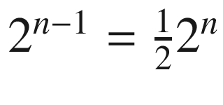

，而且我们在确定算法复杂度时可以忽略常数。

`variables i = 1, seq \in OrderedSeqOf(1..MaxInt, MaxInt), target \in 1..MaxInt, found_index = 0, counter = 0;Search: while i <= Len(seq) do counter := counter + 1; if seq[i] = target then found_index := m; goto Result; end if; i := i + 1 end while;Result: if Len(seq) > 0 then assert Pow2(counter-1) <= Len(seq); end if; if target \in PT!Range(seq) then assert seq[found_index] = target; else assert found_index = 0; end if;`

现在这种方法失败了，因为我们的“二分查找”效率太低。相比之下，这才是*真正的* 二分查找 ：

```
                    (*--algorithm binary_search
                  variables low = 1,          seq \in OrderedSeqOf(1..MaxInt, MaxInt),          high = Len(seq),          target \in 1..MaxInt,          found_index = 0,          counter = 0;beginSearch:  while low <= high do    counter := counter + 1;    with      m = (high + low) \div 2    do        if seq[m] = target then            found_index := m;            goto Result;        elsif seq[m] < target then            low := m + 1;        else            high := m - 1;        end if;    end with;
                    end while;
                    Result:    if Len(seq) > 0 then      assert Pow2(counter-1) <= Len(seq);    end if;    if target \in Range(seq) then      assert seq[found_index] = target;    else      assert found_index = 0;    end if;end algorithm; *)
```

测试通过（1483 个状态）。尝试将MaxInt 设置为 7，测试也通过（141,675 个状态）。测试更高的MaxInt 值需要修改模型中的“高级选项”>“最大可枚举集的基数”，所以我们先避免这样做。我们已经演示了如何测试最坏情况下的渐近复杂度。遗憾的是，使用 TLA+ 测试平均复杂度和最佳复杂度超出了我们的能力范围，您应该考虑使用其他工具。

This passes (1483 states). Try again with MaxInt == 7, which also passes (141,675 states). Testing on higher values of MaxInt require us to modify Advanced Options > Cardinality of Largest Enumerable Set in our model, so let’s avoid that. We’ve demoed how to test asymptotic complexity for a worst-case scenario. Testing average and best-case complexity is outside the scope of what we can easily do with TLA+, unfortunately, and you should start reaching for another tool.

细心的读者可能已经注意到我们实现的二分查找算法中存在一个不易察觉的错误。虽然它作为一个抽象算法运行正常，但在实际机器上，low + high 的值可能会超出整数范围。为了验证这一点，我们保存该计算过程并断言其结果小于MaxInt：

`while low <= high do counter := counter + 1; with lh = low + high, m = lh \div 2 do assert lh <= MaxInt; if seq[m] = target then found_index := m; goto Result;`

`with lh = high - low, m = high - (lh \div 2) do`

这样就不会再发生溢出，并且仍然保持相同的性能和正确性。如果您在编写规范时可能会遇到这种情况，那么理想情况下，您应该创建一个不变式， 确保所有操作都不会导致变量溢出。我们可以通过将m和lh设置为全局变量，然后对所有变量添加不变式来实现这一点：

`NoOverflows == \A x \in {m, lh, low, high}: x <= MaxInt`

## 多进程算法

## Multiprocess Algorithm

多进程算法与单进程算法类似，区别在于我们需要在所有进程终止时检查断言。与其将断言硬编码到程序中，不如将其编码为存活要求。这意味着使用“最终总是”（<>[]）运算符，该运算符会检查算法*最终*是否以某个特定条件为真而结束。

Multiprocess algorithms are similar to single-process algorithms, except that we want to check our assertion when all of the processes terminate. Instead of hard-coding an assertion in, we should encode it as a liveness requirement. This means using the “eventually always” (<>[]) operator, which checks that the algorithm *ends* with a certain thing being true.

记住，如果你不想模拟算法运行中途崩溃的情况，就应该使用公平的流程。

`EXTENDS Integers, Sequences, TLC(*--algorithm counter_incrementervariables counter = 0, goal = 3;define Success == <>[](counter = goal)end define;fair process incrementer \in 1..3variable local = 0begin Get: local := counter; Increment: counter := local + 1;end process;end algorithm; *)`

不出所料，这种方法失败了，因为我们的进程可能会基于过时的内存信息递增。如果我们把这两个标签合并成一个标签，就能成功处理 22 个状态。

This, unsurprisingly, fails, as our processes can increment based off stale memory. If we merge the two labels into one label, this succeeds with 22 states.

## 概括

## Summary

我们验证了单进程算法的正确性，以及它们的一些其他非功能性属性，例如最坏情况下的性能以及它们不会超出计算机的最大值。我们还简要概述了如何将这些思想扩展到多进程算法，使用时间属性而不是简单的断言。

We verified single-process algorithms were correct and some additional nonfunctional properties about them, such as their worst-case performance and that they didn’t overflow our computer’s maximum value. We also briefly summarized how to extend these ideas to multiprocess algorithms, using temporal properties instead of bare assertions.

许多算法都是针对特定数据结构定义的。许多系统规范的设计也假定数据以特定方式组织。下一章，我们将展示如何为算法和规范编写可重用的数据结构。

Many algorithms are defined for specific data structures. And many specs for systems are designed assuming you have your data organized in a specific way. In the next chapter, we will show how to write reusable data structures for algorithms and specifications.

脚注

1

https://ai.googleblog.com/2006/06/extra-extra-read-all-about-it-nearly.html

https://ai.googleblog.com/2006/06/extra-extra-read-all-about-it-nearly.html

2

https://dl.acm.org/citation.cfm?id=600875

https://dl.acm.org/citation.cfm?id=600875

© Hillel Wayne 2018

希勒尔·韦恩实用TLA+https://doi.org/10.1007/978-1-4842-3829-5_8

# 8. 数据结构

# 8. Data Structures

希勒尔·韦恩<sup>1</sup>

（1）

美国伊利诺伊州芝加哥

当我们想要编写涉及某种数据结构的规范时，我们需要对该数据结构进行某种定义 。此外，我们需要一个独立于算法的定义。这意味着我们应该将数据结构编写为独立的模块，并在规范中对其进行扩展或实例化。我们将以链表（LL）为例，并将其定义在一个名为LinkedLists.tla的文件中。

When we want to write a specification involving some data structure, we need some sort of definition of the data structure . Further, we need one that’s independent of the algorithm. That means we should write data structures as separate modules that are extended or instantiated in our spec. We’ll use the example of linked lists (LL), in a file we’ll call LinkedLists.tla.

### 警告

### Warning

如果您要为此创建新的规范，请不要将LinkedLists.tla设置为根文件。而是将根文件设置为其他名称，例如 main.tla，并将LinkedLists.tla添加为辅助模块。这样可以方便后续的测试。您可以通过“文件”>“打开模块”>“添加 TLA+ 模块”来完成此操作。

If you’re making a new specification for this, do not make LinkedLists.tla the root file. Instead, make the root file something else, such as main.tla, and add LinkedLists.tla as a secondary module. This will make it easier to test later. You can do this under File > Open Module > Add TLA+ Module.

链表 是一种底层数据结构，其中链表中的每个元素（节点）都是一个数据结构，包含数据以及指向下一个节点的指针。链表中的最后一个节点指向空元素，因此我们知道它是最后一个节点。然而，关键在于，链表的最后一个元素可能并不*指向*空元素。相反，原本应该是“最后一个”的元素可能指向更早的内存地址。这种情况称为循环。

A linked list is a low-level data structure where each element (node) of the LL is a data structure containing the data and a pointer to the next node. The last node in the list points to a null element, which is how we know it’s the last one. Critically, though, the LL might not *have* a last element that points to null. Instead, what would be the “last” element could instead point to an earlier memory address. This is called having a cycle.

在大多数情况下，带有环路的链表是不受欢迎的，表明系统存在缺陷。这为我们提供了多种规范用途：我们可能希望确保某些算法永远不会生成带有环路的链表；或者我们可能希望编写一个检测环路的算法；又或者我们可能希望确保即使输入带有环路的链表，系统也能正常工作。为了支持所有这些用例，我们希望LinkedLists.tla能够生成所有可能的链表，并允许我们从中选择符合我们规范所需属性的子集。

In most cases, LLs with cycles are unwanted and indicate there is a bug in the system. This gives us several uses for speccing them: we may want to ensure some algorithm never produces LLs with cycles, or we may want to write an algorithm that detects cycles, or we may want to ensure a system still works properly even if fed a cyclic LL. To support all of these use cases, we want LinkedLists.tla to generate all possible LLs and let us select the subset that has the properties we need for our spec.

在 TLA+ 中，我们通常将数据结构表示为函数或结构体（结构体本身也是函数）。按照惯例，模块应该有一个LinkedLists(Nodes)运算符，用于生成所有匹配的函数，其中Nodes是内存地址集合。

In TLA+, we generally represent data structures as functions or structures (which are also functions). By convention the module should have a LinkedLists(Nodes) operator that generates all matching functions where Nodes is the set of memory addresses.

虽然链表中包含数据，但这些数据并非链表核心拓扑结构的关键。对于基本情况，重要的是，对于给定的节点，我们知道下一个节点是什么。那么，我们的链表将是函数集[Nodes -> Nodes]中的某个元素。我们将首先定义节点之间所有可能的映射关系。

`PointerMaps(Nodes) == [Nodes -> Nodes]LinkedLists(Nodes) == \* ...`

接下来，我们需要定义一个最终节点。它就是一个指向空值的节点，这意味着我们需要一个空值。我们可以添加一个NULL常量 ，然后断言所有节点都不为空。这意味着要使用TLC来实现Assert 操作。我们将使用LOCAL INSTANCE而不是EXTENDS，这样任何扩展LinkedLists.tla 的规范都不会同时导入 TLC 操作符。

Next, we need a concept of a final node. It’s simply a node that points to a null value, which means we need a null value. We can add a NULL constant and then assert that none of the nodes are in NULL. This means using TLC to get Assert. We will use LOCAL INSTANCE instead of EXTENDS, so that any spec extending LinkedLists.tla does not also import the TLC operators.

目前我们掌握的情况如下：

`CONSTANT NULLLOCAL INSTANCE TLC \* For AssertPointerMaps(Nodes) == [Nodes -> Nodes \union {NULL}]LinkedLists(Nodes) == IF NULL \in Nodes THEN Assert(FALSE, "NULL cannot be in Nodes") ELSE \* ...`

快完成了。指针映射是所有可能的内存映射的集合。但并非所有可能的映射都是线性映射（LL）。考虑映射[n \in Nodes |-> NULL]（图8-1）。这不是单个线性映射，而是*多个不相交的线性映射*，每个线性映射都包含一个元素。我们需要某种方法将函数空间限制在“真正的”线性映射上。真正的线性映射是指，从合适的初始元素开始，不断移动到下一个节点，最终会到达所有其他节点，最终要么循环，要么到达NULL。

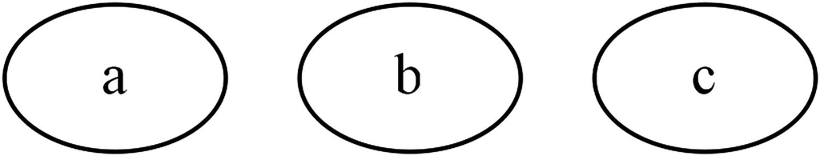

图 8-1

[n \in {"a", "b", "c"} |-> NULL]

[n \in {"a", "b", "c"} |-> NULL]

如何收集从给定起点可达的节点子集？一种方法是使用递归运算符，例如`PT!ReduceSet`。我们可以先添加第一个节点，然后添加与第一个节点相连的节点，再添加与*该节点*相连的节点，依此类推。但是递归运算符很繁琐，难以正确实现，而且在开始之前，我们还需要某种方法来找到第一个节点。

How do we collect the subset of nodes reachable from a given starting point? One way is to use a recursive operator, such as PT!ReduceSet. We’d begin to add some first node, then whatever add first connects to, then whatever *that* connects to, and so on. But recursive operators are messy and hard to get right, plus we would need some way of finding first before we even start.

更好的方法是注意到，如果我们“追踪”逻辑链中的节点，就会得到一个序列。因此，如果给定的PointerMap 是一个逻辑链，我们可以找到一个节点序列，其中每个后续元素都是前一个元素的下一个节点。例如，如果我们的逻辑链是[a |-> b, b |-> NULL, c |-> a]，那么对应的序列就是<<c, a, b>>。

A better approach would be to notice that if we “follow” the nodes in the LL, we have a sequence. So if a given PointerMap is a single LL, we can find a sequence of nodes where every subsequent element is the next node of the element before it. For example, if our LL was [a |-> b, b |-> NULL, c |-> a], that would be the sequence <<c, a, b>>.

此外，所有节点都必须出现在序列中。否则，对于映射[a |-> NULL, b |-> NULL]，我们可以选择序列<<a>>并声称该映射是有效的 LL。

`\* PointerMap is an element of PointerMapsisLinkedList(PointerMap) == LET nodes == DOMAIN PointerMap all_seqs == [1..Cardinality(nodes) -> nodes] IN \E ordering \in all_seqs: \* each node points to the next node in the ordering /\ \A i \in 1..Len(ordering)-1: PointerMap[ordering[i]] = ordering[i+1] \* all nodes in the mapping appear in the ordering /\ \A n \in nodes: \E i \in 1..Len(ordering): ordering[i] = n`

最后一条子句简化为`nodes \subseteq Range(ordering)`，为了简便起见，我们可以直接使用它。现在我们可以使用`isLinkedList` 来选择与链表对应的指针映射。

`\* While Range is defined in PT, we don't want\* a generic module reliant on PT!Range(f) == {f[x]: x \in DOMAIN f}isLinkedList(PointerMap) == LET nodes == DOMAIN PointerMap all_seqs == [1..Cardinality(nodes) -> nodes] IN \E ordering \in all_seqs: /\ \A i \in 1..Len(ordering)-1: PointerMap[ordering[i]] = ordering[i+1] /\ nodes \subseteq Range(ordering)LinkedLists(Nodes) == IF NULL \in Nodes THEN Assert(FALSE, "NULL cannot be in Nodes") ELSE {pm \in PointerMaps(Nodes) : isLinkedList(pm)}`

然而，如果我们调用`LinkedLists(Nodes)`，则只会传入包含其域内所有节点的指针映射，因此只会得到长度为`Cardinality(Nodes)`的链表。为了获得更短的链表，我们只需扩展`LinkedLists` 函数，使其生成所有可能的节点子集，为每个子集定义所有指针映射，然后对所有生成的指针映射调用`isLinkedList` 函数即可。

`LinkedLists(Nodes) == IF NULL \in Nodes THEN Assert(FALSE, "NULL cannot be in Nodes") ELSE LET node_subsets == (SUBSET Nodes \ {{}}) pointer_maps_sets == {PointerMaps(subn): subn \in node_subsets} \* pointer_maps_sets is a set of set of functions, \* so we need to union them all together all_pointer_maps == UNION pointer_maps_sets IN {pm \in all_pointer_maps : isLinkedList(pm)}`

每个链表都应该有一个起点。我们可以把它定义为链表中没有任何其他元素指向它的节点吗？不完全是这样。对于任何链表，*最多*只有一个节点不被任何其他节点指向。如果存在这样一个孤立节点 ，它必然是链表的首节点。但是，在某些情况下，称为“环”，不存在孤立节点：链表的最后一个元素指向第一个元素（图8-2）。

`>> CHOOSE ll \in LinkedLists({"a", "b"}): {"a", "b"} \subseteq Range(ll) [a |-> "b", b |-> "a"]`

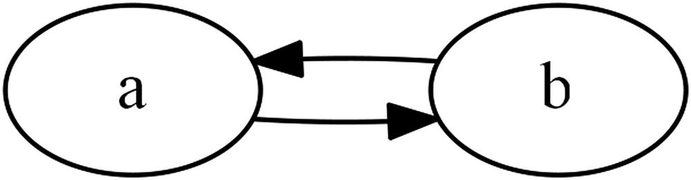

图 8-2

[a |-> "b", b |-> "a"]

[a |-> "b", b |-> "a"]

在那种特定情况下，从哪个节点开始都无所谓，所以我们可以随意选择一个。对于其他情况，我们应该选择孤立节点 作为起点。

`Ring(LL) == (DOMAIN LL = Range(LL))First(LL) == IF Ring(LL) THEN CHOOSE node \in DOMAIN LL: TRUE ELSE CHOOSE node \in DOMAIN LL: node \notin Range(LL)`

### 提示

### Tip

我们也可以把“First”写成

We could also write First as

首先(LL) == 选择域 LL 中的节点：~Ring(LL) => 不在 Range(LL) 中的节点

First(LL) == CHOOSE node \in DOMAIN LL: ~Ring(LL) => node \notin Range(LL)

如果链表是一个环，那么我们有FALSE => node \notin Range(LL)，这始终为TRUE。

If the linked list is a ring, then we have FALSE => node \notin Range(LL), which is always TRUE.

我们将Ring(LL)定义为布尔运算符，以便可以像First 运算符那样与其他运算符结合使用。如果您的规范需要符合特定条件的数据结构，通常的做法是先定义一个运算符来测试给定实例是否符合这些条件，然后将该运算符与 set 过滤器和CHOOSE运算符结合使用。这样，您就可以轻松地在规范中组合条件。例如，以下是如何选择一个非环的循环 LL ：

`Cyclic(LL) == NULL \notin Range(LL)>> CHOOSE ll \in LinkedLists({"a", "b"}): Cyclic(ll) /\ ~Ring(ll)[a |-> "b", b |-> "b"]`

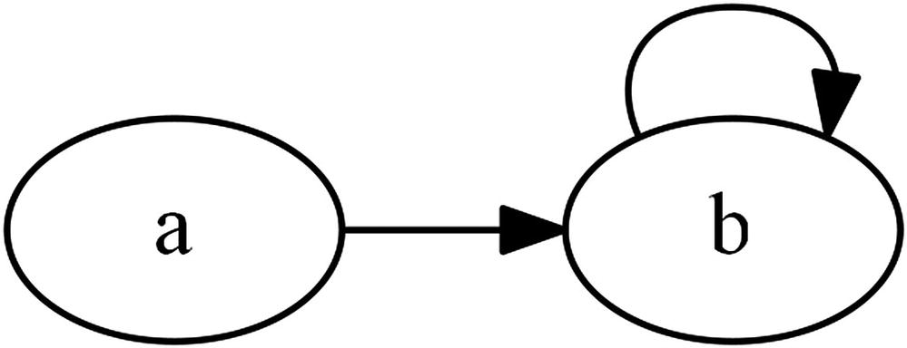

图 8-3

[a |-> "b", b |-> "b"]

[a |-> "b", b |-> "b"]

虽然我们编写了很多运算符，但它们大多是模块内部的，我们应该将它们设为本地运算符。总结一下：

```
---- MODULE LinkedLists ----CONSTANT NULLLOCAL INSTANCE FiniteSets \* For CardinalityLOCAL INSTANCE Sequences \* For lenLOCAL INSTANCE TLC \* For AssertLOCAL INSTANCE Integers \* For a..bLOCAL PointerMaps(Nodes) == [Nodes -> Nodes \union {NULL}]LOCAL Range(f) == {f[x]: x \in DOMAIN f}LOCAL isLinkedList(PointerMap) ==  LET    nodes == DOMAIN PointerMap    all_seqs == [1..Cardinality(nodes) -> nodes]  IN \E ordering \in all_seqs:    /\ \A i \in 1..Len(ordering)-1:      PointerMap[ordering[i]] = ordering[i+1]    /\ nodes \subseteq Range(ordering)LinkedLists(Nodes) ==


                    IF NULL \in Nodes THEN Assert(FALSE, "NULL cannot be in Nodes") ELSE  LET    node_subsets == (SUBSET Nodes \ {{}})    pointer_maps_sets == {PointerMaps(subn): subn \in node_subsets}    all_pointer_maps == UNION pointer_maps_sets  IN {pm \in all_pointer_maps : isLinkedList(pm)}Cyclic(LL) == NULL \notin Range(LL)Ring(LL) == (DOMAIN LL = Range(LL))First(LL) ==  IF Ring(LL)  THEN CHOOSE node \in DOMAIN LL:        TRUE  ELSE CHOOSE node \in DOMAIN LL:        node \notin Range(LL)====
```

## 验证

## Validation

我们对链表的定义相当复杂，因此我们可能需要对其进行健全性检查。我们可以创建一个规范，导入LinkedLists库并包含一些评估运算符，例如Valid。这就是为什么我让你为这个项目创建一个单独的根文件：这样我们就可以在根文件中完成所有的健全性检查。以下是一些我们可能需要检查的内容：

- 应该有一些LL循环。
- There should be some LL with a cycle.
- 应该有一些*没有*循环的LL。
- There should be some LL *without* a cycle.
- 对于每一组节点，都存在一个环覆盖所有这些节点。
- For every set of nodes, there is some ring that covers all of those nodes.
- 所有 LL 最多只有一个没有父节点的节点，最多有一个有两个父节点的节点（在环的情况下），并且没有超过两个父节点的节点。
- All LLs have at most one node without a parent, at most one node with two parents (in the case of a cycle), and no nodes with more than two parents.

你应该尝试写出所有这些句子作为练习 。我们来看其中一个：我们将循环定义为“不存在指向NULL的节点”。我们也可以将其定义为“LL 中存在一个有两个父节点的节点”。让我们证明这两种定义是等价的。

`---- MODULE main ----EXTENDS TLC, Integers, FiniteSets, SequencesCONSTANTS Nodes, NULLINSTANCE LinkedLists WITH NULL <- NULLAllLinkedLists == LinkedLists(Nodes)CycleImpliesTwoParents(ll) == Cyclic(ll) <=> \E n \in DOMAIN ll: Cardinality({p \in DOMAIN ll: ll[p] = n}) = 2Valid == /\ \A ll \in AllLinkedLists: /\ Assert(CycleImpliesTwoParents(ll), <<"Counterexample:", ll>>)====`

我们需要“无行为规范”，因为我们不验证任何算法，只验证数据结构是否正确。然后我们可以运行“验证常量表达式”命令。

`NULL <- [ model value ]Nodes <- [ model value ] {a, b, c}>> Valid<<"Counterexample:", (a :> a)>>`

我们忘记了环是每个节点都有一个父节点的循环。我们对链表 的定义可能是正确的，但“循环蕴含两个父节点”是不正确的。让我们调整它以使其适用于环。

`CycleImpliesRingOrTwoParents(ll) == Cyclic(ll) <=> \/ Ring(ll) \/ \E n \in DOMAIN ll: Cardinality({p \in DOMAIN ll: ll[p] = n}) = 2Valid == /\ \A ll \in AllLinkedLists: /\ Assert(CycleImpliesRingOrTwoParents(ll), <<"Counterexample:", ll>>)>> ValidTRUE`

尝试在Valid 函数中添加更多连接符作为测试条件。你发现什么意想不到的结果了吗？你希望在LinkedList 函数中添加哪些有用的运算符？

Try adding a few more tests as conjunctions to Valid. Do you find anything surprising? Are there any useful operators you’d want to add to LinkedLists?

## 例子

## Example

我们费了九牛二虎之力才做出了链表模块，所以不妨把它用在算法中。*龟兔赛跑*算法是检测链表环路的著名方法。在链表的开头放置两个迭代器，一个速度较慢的“乌龟”，一个速度较快的“兔子”。每一步，乌龟指针移动一个节点，兔子指针移动*两个*节点。如果两个指针最终指向同一个节点，则说明链表存在环路。这是一个单进程算法，因此我们可以使用上一章学到的标准模板。

`EXTENDS TLCCONSTANTS Nodes, NULLINSTANCE LinkedLists(*--fair algorithm tortoise_and_harevariables ll \in LinkedLists(Nodes), tortoise = First(ll), hare = tortoise;macro advance(pointer) begin pointer := ll[pointer]; if pointer = NULL then assert ~Cyclic(ll); goto Done; end if;end macro;begin while TRUE do advance(tortoise); advance(hare); advance(hare); if tortoise = hare then assert Cyclic(ll); goto Done; end if; end while;end algorithm; *)`

尝试使用`Nodes <- [ model value ] {a, b, c, d}`检查终止性。它应该在 2248 个状态的情况下通过。尝试移除其中一个高级节点，看看有问题的规范是如何失败的。为什么我们需要编写公平算法而不是简单的算法？尝试移除它，看看会发生什么。

Try checking Termination with Nodes <- [ model value ] {a, b, c, d}. It should pass with 2,248 states. Try removing one of the advances to see how the broken spec fails. Why do we need to write fair algorithm instead of just algorithm? Try removing it to see what happens.

## 概括

## Summary

我们展示了如何编写可在其他规范中复用的数据结构。我们的示例是创建一个链表模块，我们编写并验证了该模块。我们还将该模块用于另一个算法中。

We showed how to write a data structure that we can reuse in other specs. Our example was making a linked list module, which we wrote and validated. We also used this module as part of another algorithm.

下一章，我们将学习如何使用状态机来帮助设计和添加抽象规范的细节。

In the next chapter, we will learn how to use state machines to help design and add detail to abstract specs.

© Hillel Wayne 2018

希勒尔·韦恩实用TLA+https://doi.org/10.1007/978-1-4842-3829-5_9

# 9. 状态机

# 9. State Machines

希勒尔·韦恩<sup>1</sup>

（1）

美国伊利诺伊州芝加哥

规范比代码更具表达力。但这也带来了一个问题：如何从规范过渡到实际应用并不总是那么清晰。一种解决方法是编写一个非常抽象的规范，然后将其扩展为一个更详细、更底层的“实现”，使其更接近最终要编写的程序。一种非常常见的实现方式是使用**状态机**。在本章中，我们将学习如何表示状态机，以及如何在编写规范时使用它们。

Specifications are more expressive than code. This comes at a cost: it’s not always clear how to go from a specification to reality. A technique for handling this is to write a very abstract spec and expand it into a more detailed, lower-level “implementation” that is closer to the program you’ll be writing. One very common pattern for doing this is to use a **state machine**. In this chapter, we will learn how to represent them and use them in writing our specifications.

## 状态机

## State Machines

状态机是一个系统，它拥有有限的内部“状态”集合以及连接这些状态的一系列转换。外部事件可以触发这些转换。例如，一扇门可能处于锁定或解锁状态 ，也可能处于打开或关闭状态。我们可以执行的操作包括锁定和解锁门，以及打开和关闭门。我们还可以进一步规定，我们只能打开未锁定的门。我们可以将状态机写成一个巨大的非此即彼链：

`(*--algorithm doorvariables open = FALSE, locked = FALSE;begin Event: either \* unlock await locked; locked := FALSE; or \* lock await ~locked; locked := TRUE; or \* open await ~locked; await ~open; open := TRUE; or \* close await open; open := FALSE; end either; goto Event;end algorithm; *)`

这个系统有八个状态。不过，其中只有四个状态是不同的，这符合我们的预期。需要注意的是，这种行为是不确定的 ：例如，当门处于未解锁且关闭状态时，我们可以选择锁门或开门。这是两种不同的状态转换。大多数状态机（至少大多数有趣的状态机）都是并发的。

This passes with eight states. Only four of those states are distinct, though, which matches our expectations. Note the behavior is nondeterministic : when the door is unlocked and closed, for example, we can either lock it or open it. That’s two separate transitions that are possible. Most state machines (at least most interesting state machines) are concurrent.

什么是故障模式？我们考虑这样一种情况：如果门是关着的，我们需要钥匙才能锁上或打开它。但如果门是开着的，我们就可以不用钥匙锁上或打开它，例如通过转动另一侧的锁。我们可以这样表示新的状态机：

`(*--algorithm doorvariables open = FALSE, locked = FALSE, key \in BOOLEAN;begin Event: either \* unlock await locked /\ (open \/ key); locked := FALSE; or \* lock await ~locked /\ (open \/ key); locked := TRUE; or \* open await ~locked /\ ~open; open := TRUE; or \* close await open; open := FALSE; end either; goto Event;end algorithm; *)`

现在，测试可能会出现死锁：如果我们没有钥匙，就可以打开门，锁上，然后再关上门。一种解决方法是让门只有在解锁状态下才能关闭，就像大多数门栓的工作方式一样。如果将“关闭”条件改为等待打开/~已锁定，测试就能再次通过（14 个状态）。其中只有 7 个状态是不同的：由于有钥匙，初始状态的数量是原来的两倍，但如果*没有*钥匙，就无法达到门已关闭并锁定的状态。

Now the spec can deadlock: if we don’t have the key, then we can open the door, lock it, and then close the door again. One way around this is to make the door only closable if it’s unlocked, like how most deadbolts work. If you change the “close” guard to await open /\ ~locked, the spec passes again (14 states). Only 7 are distinct: we have twice as many initial states due to having a key, but if we *don’t* have a key then reaching the closed locked door state is impossible.

随着状态机变得越来越复杂，我们可以将其拆分成独立的进程来简化它们。我们将一些事件放入每个进程中。如果我们为开门和关门分别设置独立的进程，状态机看起来会是这样的：

`(*--algorithm doorvariables open = FALSE, locked = FALSE, key \in BOOLEAN;process open_door = "Open Door"begin OpenDoor: await open; either \* lock/unlock locked := ~locked; or \* close await ~locked; open := FALSE; end either; goto OpenDoor;end process;process closed_door = "Closed Door"begin ClosedDoor: await ~open; either \* lock/unlock await key; locked := ~locked; or await ~locked; open := TRUE; end either; goto ClosedDoor;end process;end algorithm; *)`

这样处理后，状态机可以处理 12 个状态 。虽然代码行数实际上增加了大约 1.5 倍，但对于大型状态机来说，这种风格通常更简洁清晰。它还能更清晰地展现状态机的并发性，让我们了解在处理复杂示例时将使用的框架。最后，它允许我们通过标签添加非原子转换，这在编写分布式状态机时至关重要。

This passes with 12 states . This actually ends up being about 1.5x more lines, but this style is often more concise and clearer for larger state machines. It also makes the concurrency of the state machine more evident, showing us the framework we’d be using for complex examples. Finally, it lets us include non-atomic transitions via labels, which becomes important when we try to write distributed state machines.

我们使用await来控制单进程和多进程状态机中的事件流。我们可以大致将所有 PlusCal“状态机”描述为如下结构：由await和either语句控制的分支和进程。

We used await to shape the event flow in both the single-process and the multiprocess state machine. We can roughly describe all PlusCal “state machines” as looking like this: branches and processes controlled by await and either statements.

## 脚手架实现

## Scaffolding Implementations

大多数现实问题并非显式的状态机，但许多问题*看起来*像状态机，并且可以抽象地用状态机来描述。然后，我们可以基于该状态机来实现我们的规范，填充状态转换在代码中实际实现的细节，并确保它保持相同的不变性。例如，我们将描述一个简单的数据模式：一些客户端可以从数据库读取数据并写入数据。我们首先将其描述为一个不包含数据库的状态机，然后逐步细化，以更精确地模拟客户端如何“读取”和“写入”数据。

Most real-life problems aren’t explicitly state machines. But many *look* like state machines and can be abstractly specified as state machines. Then we can implement our spec off that state machine, filling in the details on how the transitions are actually implemented in code and making sure it preserves the same invariants. As an example of this, we will spec a simple data pattern. Some clients can read from and write to a database. We first specify this as a state machine without a database, and then progress to a more-detailed one that more accurately models how, exactly, the clients “read” and “write.”

### 精炼

### REFINEMENT

**TLA+ 通过细化**将“脚手架”的概念形式化。细化规范的方法是编写第二个更详细的规范，并证明详细规范中的每个有效行为也都是通用规范的有效行为。但这需要一些 PlusCal 中没有的工具，因此超出了本书的讨论范围。目前，我们只能使用一种更非正式的版本。

TLA+ formalizes the concept of “scaffolding” with **refinement** . You refine a spec by writing a second, more detailed spec and showing that every valid behavior of the detailed spec is also a valid behavior of the general spec. But this requires some tooling we don’t have access to in PlusCal, and so it is outside the scope of this book. For now, we’ll have to use a more informal version.

在我们的第一个实现中，我们甚至没有数据库，客户端 直接读写数据。我们将用常量`Data`表示可以写入数据库的所有可能值，并假设数据库最多存储一个这样的值。

`EXTENDS Integers, Sequences, TLCCONSTANTS Data, NULL, Clients(*--algorithm databasevariables db_value \in Data;process clients \in Clientsvariables result = NULL;begin Client: either \* read result := db_value; assert result = db_value; or \* write with d \in Data do db_value := d; end with; end either; goto Client;end process;end algorithm; *)`

这一切应该相当简单。目前唯一使用的内部状态是`db_value`，我们只有读取`db_value`（显然正确）和修改`db_value`这两种状态转换。除了死锁之外，我们唯一检查的是`result = db_value`，这是我们的主要不变式。

All of this should be fairly simple. The only used internal state so far is db_value, and the only transitions we have are reading db_value (trivially correct) and modifying db_value . The only thing we check (aside from deadlock) is assert result = db_value, which is our primary invariant.

放

`Clients <- [ model value ] {c1}NULL <- [ model value ]Data <- [ model value ] {d1, d2}`

20 个状态的测试通过了。您可能还需要检查一下，如果有两个客户端（110 个状态），测试是否也通过了。我们将在规范中添加一些实现细节后，再讨论双客户端的情况。

This passes with 20 states. You may also want to check that it passes with two clients (110 states). We will return to the two-client case once we’ve added some implementation details to the spec.

这是我们规范中最抽象的版本。实际上，我们不能让客户端直接写入数据库；客户端必须与控制数据库的机制进行通信 。关键在于，我们添加到状态机中的任何细节都不会改变规范的整体结构。我们构建的更复杂的状态机都是这个简单状态机的更精细版本，并且仍然会保留相同的高级不变性。

This is the most abstract version of our spec. In reality, we can’t just have the client directly writing to the database; we’d have to have them communicate with whatever controls the database . The key here, though, is that any details we add to the state machine won’t change this overall spec structure. The more complex state machines we make will be more elaborate versions of this simple state machine and will still preserve the same high-level invariants.

我们将实现客户端与数据库的实际通信方式。客户端不会直接进行读写操作，而是会发送一个*查询请求*，然后等待*响应*后再继续执行。数据库会接收查询请求，根据请求结果执行读写操作，并返回响应。我们首先只实现写入操作，以便了解需要添加哪些机制来支持它。

```
variables  query = [c \in Clients |-> NULL];  db_value \in Data;
                    macro request(data) begin
                    query[self] := [type |-> "request", data |-> data]
                    end macro;

                    macro wait_for_response() begin
                    await query[self].type = "response";
                    end macro;
                  process clients \in Clientsvariables result = NULL;begin  Request:    while TRUE do      either \* read        result := db_value;        assert result = db_value;      or \* write        with d \in Data do          request(d);        end with;        Wait:          wait_for_response();      end either;    end while;end process;
```

以上是一个更详细的状态机，更接近实际实现。我们还在状态机中添加了一个新的属性 ` query`。现在，我们的写入操作分为两步：一步是执行查询，另一步是等待响应。然而，这仍然是一个不完整的步骤。首先，我们的请求宏不允许我们发送读取请求。其次，如果没有实际的客户端响应，我们的规范将会发生死锁。我们需要添加一些功能，用于接收请求查询 并根据查询结果更新数据库。

```
                    define
                    Exists(val) == val /= NULL  RequestingClients == {c \in Clients: Exists(query[c]) /\ query[c].type = "request"}
                    end define;
                  \* our macros\* ...
                    process database = "Database"

                    begin
                    DB:    with client \in RequestingClients, q = query[client] do      db_value := q.data;      query[client] := [type |-> "response"];    end with;  goto DB;
                    end process;
```

现在客户端可以写入数据库了，状态机再次通过验证（共 50 个状态）。接下来，我们用读取操作完成状态转换。为此，我们需要在查询中区分读取请求和写入请求。

`macro request(data) begin query[self] := [type |-> "request"] @@ data;end macro;`

现在，客户端不再传递单个值，而是传递一个包含请求数据的结构体。对于读取操作，数据仅包含一个表示要读取数据的标签。对于写入操作，数据包含一个表示要写入数据的标签，以及 要写入数据库的具体数据。

`process clients \in Clientsvariables result = NULL;begin Request: while TRUE do either \* read request([request |-> "read"]); Confirm: wait_for_response(); result := query[self].result; assert result = db_value; or \* write with d \in Data do request([request |-> "write", data |-> d]); end with; Wait: wait_for_response(); end either; end while;end process;`

我们还需要修改数据库：

`process database = "Database"begin DB: with client \in RequestingClients, q = query[client] do if q.request = "write" then db_value := q.data; elsif q.request = "read" then skip; else assert FALSE; \* What did we even pass in end if; query[client] := [type |-> "response", result |-> db_value]; end with; goto DB;end process;`

该提案已获得56个州的通过。

This passes with 56 states.

在完善高层状态机的过程中，我们也添加了一些新的行为。发出请求和获取响应不再是原子操作。我们希望确保实现的版本保留相同的不变式：在本例中，断言 result = db_value 。抽象状态机和详细状态机对于单个客户端是匹配的。但是对于两个客户端呢？尝试使用Client <- [ model value ] {c1, c2}重新运行这两个版本。

In adding detail to our high-level state machine, we also added new behaviors. Making a request and getting a response is no longer an atomic operation. We want to make sure the implemented version preserves the same invariants: in this case, the assert result = db_value. The abstract state machine and the detailed state machine match for a single client. But what about two clients? Try rerunning both versions with Client <- [ model value ] {c1, c2}.

你应该能看出它们并不一致：抽象版本通过了（110 个状态），而详细版本却失败了。添加通信层意味着 c1 可以请求读取数据并获得响应，但 c2 可以在 c1 读取响应之前向数据库写入数据。

You should see they don’t agree: the abstract version passes (110 states) while the detailed version fails. Adding that communication layer means that c1 can request a read and get a response, but c2 can write to the database before c1 reads its response.

和往常一样，我们可以做两件事：要么改变实现方式，要么重新思考我们真正的需求是什么。这里值得探讨的是，抽象机的不变式究竟意味着什么。是指客户端始终知道数据库中的内容，还是指数据库始终对客户端诚实？这两种解释都与最初的不变式相符。

As always, there are two things we can do: we can change the implementation, or we can rethink what our requirements really are. Here it is worth asking what the invariant of the abstract machine actually means. Is it that the client always knows what’s in the database, or that the database is always honest with the client? Both of these interpretations are compatible with the original invariant.

前一种情况比较困难，我们需要回头重新开始。后一种情况，我们可以通过进一步完善我们的不变量来实现。

The former case is more difficult, and we’d have to backtrack and start again. In the latter case, we can achieve it by further elaborating on our invariant.

## 幽灵变量

## Ghost Variables

正式表述“数据库对客户端诚实”的一种方法是，声明客户端接收到的数据*在请求时是正确的。我们的实现仅跟踪**当前*数据。我们可以对其进行修改，使其也存储历史记录。然而，这与我们实际的物理系统无关：历史记录仅用于检查不变性，而与我们想要的交互的实际实现无关。

One way to formalize “the database is honest with the client” is to say that whatever the client receives was correct data *at the time of the request*. Our implementation only tracks what the data is *currently*. We can alter it to also store history. This, though, would be irrelevant to our actual, physical system: the history only matters for checking the invariant, not for the actual implementation of the interactions we want.

关键在于，我们的规范包含了两层含义。首先，它展示了状态机的预期工作方式。其次，它代表了状态机所处的更广泛的上下文。即使实现中没有跟踪先前的值，它仍然是我们更广泛上下文的一部分。我们可以做的是，为这个上下文添加更多细节，看看是否能得到一个正确的系统。

The trick here is that our specification is doing two things. First, it shows how our state machine is intended to work. Second, it represents the wider context our state machine exists in. Even if the implementation doesn’t track prior values, that’s still part of our wider context. What we can do is add more detail to that context and see if that gets us to a correct system.

我们用来验证不变性的上下文数据被称为**辅助**数据或**幽灵**数据。我们还可以有幽灵算子、幽灵进程等等。重要的是，幽灵数据仅用于检查不变性。虽然我们的规范可以影响幽灵数据，但幽灵数据不能改变规范的行为。规范可以定义哪些状态被视为破坏不变性，但它不能阻止模型检查器到达这些状态。

Contextual data that we track to verify invariants is called **auxiliary**, or **ghost**, data. We can also have ghost operators, ghost processes, etc. What’s important is that the ghost data is only used for checking invariants. While our spec can affect our ghost data, our ghosts cannot change the behavior of the spec. It may define which states are considered invariant breaking, but it cannot prevent the model checker from reaching those states.

一如既往，眼见为实。让我们在规范中添加一个虚拟变量，用于跟踪数据库在响应请求时的值：

`variables query = [c \in Clients |-> NULL], ghost_db_history = [c \in Clients |-> NULL]; \* db_value is no longer global\* ...process database = "Database" variable db_value \in Data;begin DB: with client \in RequestingClients, q = query[client] do if q.request = "write" then db_value := q.data; elsif q.request = "read" then skip; else assert FALSE; end if; ghost_db_history[client] := db_value; query[client] := [type |-> "response", result |-> db_value]; end with;`

我们将额外数据捕获到`ghost_db_history`中。数据库进程可以写入该变量，但不能（也无法）读取它。客户端将断言`ghost_db_history` 的值，而不是`db_value`，这意味着我们不再需要将`db_value`设置为全局变量。虽然这不会改变行为，但它使规范更加严谨。

`Request: either \* read request([request |-> "read"]); Confirm: wait_for_response(); result := query[self].result; assert result = ghost_db_history[self];`

客户端也不会读取ghost_db_history。它只出现在一个断言中，因此仅用于检查一个不变式。这样，我们的双客户端模型就能通过测试（6098 个状态）。如果我们实现这个模型，数据库将不会跟踪历史记录，因为ghost_db_history不属于实现的一部分。但它仍然符合我们现有的规范。

The client isn’t reading ghost_db_history either. It only appears in an assertion and so is only used to check an invariant. With this, our two-client model passes (6,098 states). If we implemented this, the database would not be tracking history, since ghost_db_history isn’t part of the implementation. But it would still conform to the spec we have.

现在，我们建立了初始抽象状态机和最终规范之间的关系。如果我们把不变式理解为“响应是请求处理时数据库的值”，那么最终规范就实现了初始状态机。如果我们把不变式理解为“客户端始终读取数据库的当前值”，那么最终规范就没有实现初始状态机。

We now have a relationship between our initial, abstract state machine and our final spec. If we read the invariant as “the response is the value of the database at the time the request is processed,” then our final spec implements the initial state machine. If we read the invariant as “the client always reads the current value of the database,” then our final spec does not implement the initial state machine.

## 概括

## Summary

我们学习了如何编写状态机模式，如何将其用于设计规范的实现，以及幽灵值在检查规范属性中的作用。我们设计了一个客户端数据库系统，并证明了其运行正确。

We learned how to write a state machine pattern, how to use it as a means of designing the implementations of specs, and the value of ghost values for checking properties of a spec. We designed a client-database system and showed that it behaves correctly.

TLA+ 帮助我们创建了一个符合更高层级规范的实现。在下一章中，我们将更进一步，使用 TLA+ 将一组非正式的业务需求转化为规范，并在过程中使这些需求形式化。

TLA+ helped us create an implementation that matched a higher-level specification. In the next chapter, we will go one step higher and use TLA+ to turn a set of informal business requirements into a specification, formalizing the requirements in the process.

© Hillel Wayne 2018

希勒尔·韦恩实用TLA+https://doi.org/10.1007/978-1-4842-3829-5_10

# 10. 业务逻辑

# 10. Business Logic

希勒尔·韦恩<sup>1</sup>

（1）

美国伊利诺伊州芝加哥

我们使用 TLA+ 来查找设计中的缺陷。但它还有另一个更微妙的好处：我们还能发现规范中存在歧义的地方。正式地描述问题会迫使你明确系统真正想要的功能。这在对“业务逻辑”、功能和需求进行建模时尤为重要。为了更好地说明这一点，我们将使用 TLA+ 来描述一个简单的库系统，并展示描述过程本身如何能够发现规范中的缺陷。

We use TLA+ to find flaws in our designs. But there’s another, subtler benefit: we also find places where the spec is ambiguous. Formally specifying your problem forces you to decide what you actually want out of your system. This is especially important when we model “business logic,” features, and requirements. To work through this, we’ll use TLA+ to spec a simple library system and show how the act of specifying can itself find faults in the spec.

在我们的系统中，读者可以借阅、续借和归还图书。他们还可以预约图书：被预约的图书无法被其他人借阅。系统内部必须保持一致（所有图书都有记录），并且任何想要借阅图书的人最终都应该能够借到。这些功能看似简单，但它们之间的交互方式可能会导致一些意想不到的结果。

In our system, people should be able to check out books, renew books, and return them. They will also be able to reserve books: a reserved book cannot be checked out by anybody else. The system should be internally consistent (all books are accounted for), and anybody who wants a book should eventually be able to check it out. Most of these seem like simple features, but how they interact can lead to surprising behavior.

除了最终的规格说明之外，我还会展示开发过程以及我们可能遇到的难题。这是我们编写规格说明的一个示例*，*缺少这部分内容是不完整的。

In addition to the final specs, I’ll be showing the development process and the dead ends we can run into. This is an example of *how* we write specifications and would be incomplete without it.

## 要求

## The Requirements

我们从标准设置 、扩展和常量开始。这里似乎有两个常量：一个代表书籍集合，另一个代表人员集合。

`---- MODULE main ----EXTENDS Integers, TLC, SequencesCONSTANTS Books, PeoplePT == INSTANCE PT====`

不过仔细想想，“书籍”这个词本身就有些歧义。我们是只考虑一种类型的书籍，还是多种类型？如果只考虑一种类型，规范会更简洁，检查起来也可能更快；如果考虑多种类型，规范就能更贴近我们的问题领域。我决定采用后一种方案。考虑到图书馆的馆藏会随着时间推移而变化 ，我们可以用一个变量来表示这种变化。

`(*--algorithm libraryvariables library = \* ???end algorithm; *)`

问题二：每本书只有一本，还是可以有多本？如果是前者，我们可以将图书馆定义为一个集合。如果是后者，我们实际上希望它是一个书籍到数字的映射，类似于[书籍 -> 数量] 。同样，后一种情况更接近实际图书馆的实际情况。这意味着我们需要引入另一个常量来表示可能的副本数量范围。我们仍然可以通过将该范围设置为{1}来测试每本书只有一本的模型。

`CONSTANTS Books, People, NumCopiesASSUME NumCopies \subseteq Nat(*--algorithm libraryvariables library \in [Books -> NumCopies]; end algorithm; *)`

我们将赋予每个人从图书馆借书或还书的功能。他们拥有一个私有的“书籍”变量来跟踪他们拥有的书籍，以及“借阅”操作和“还书”操作 。

`process person \in Peoplevariables books = \* ???begin Person: either \* Checkout skip; or \* Return skip; end either; goto Person;end process;`

我们又面临一个问题：书籍应该是什么？是像图书馆那样的集合还是累加器？这会导致不同的行为 。如果我们指定书籍为集合，就意味着假设人们一次只能借阅一本书。我们需要向客户询问：人们是否应该可以借阅多本书？假设客户的回答是“否”。这就引出了另一个需求：

- “每个人一次只能借阅一本书。”
- “People can only check out one copy of a book at a time.”

由于我们需要对集合进行添加和删除操作，我想添加几个方便的二元运算符。这些运算符应该放在算法之上，因为它们的运行不依赖于任何变量。

`set ++ x == set \union {x}set -- x == set \ {x}`

为了实现人员流程 ，我决定暂时假设他们最终都会采取行动，这样可以确保流程的公平性。但随着时间的推移，这个假设可能不再成立；毕竟，有人可能会忘记还书。此外，我决定暂不为“借阅”或“还书”分别添加标签，因为目前这里还没有并发问题。

```
                    define
                    AvailableBooks == {b \in Books: library[b] > 0}
                    end define;

                    fair process person \in People
                  variables  books = {};begin  Person:    either        \* Checkout:        with b \in AvailableBooks \ books do          library[b] := library[b] - 1;          books := books ++ b;        end with;    or        \* Return:        with b \in books do          library[b] := library[b] + 1;          books := books -- b;        end with;    end either;  goto Person;end process;end algorithm; *)
```

在我们的系统中，任何人都可以借阅任何图书馆里有的、自己还没有的书籍。这定义了我们这个不包含任何不变式的最小系统 。

In our system, a person can grab any library book that is available and that they don’t already have. This defines our minimal system without any invariants .

### 添加不变量

### Adding Invariants

在确定不变量之前 ，我们先创建第一个模型。如前所述，我们的多副本系统可以“模拟”单副本系统。我们将该模型命名为OneCopyPerBook，并使用以下常量赋值：

`NumCopies <- 1..1People <- [model value] {p1, p2}Books <- [model value] {b1}`

运行此程序以确认没有崩溃。看起来没问题。现在该添加一些不变量了。首先，我们将重点关注简单的安全属性，以确保一切正常。

Run this to confirm we don’t have any crashes. Looks good. Time to add some invariants. First we’ll focus on simple safety properties to make sure nothing’s going wrong.

首先，我们要添加的是一种常见的 TLA+ 模式，称为TypeInvariant。TypeInvariant是**一个**约定俗成的术语，指的是能够捕捉系统“逻辑性”的运算符。系统可能仍然无法完全满足规范，但至少在物理上是可行的。例如，图书馆的藏书数量不能为负数：这毫无意义。图书馆的藏书数量也不能超过NumCopies的可能数量。

The first we’ll add is a common TLA+ pattern called **TypeInvariant**. TypeInvariant is the conventional term for an operator that captures the ‘sensibility’ of the system. The system may still not satisfy the spec, but at least it’s physically possible. One example of this is that the library cannot have a negative number of books in it: it’s simply not meaningful to have that. Nor can the library have more than the possible NumCopies of books in it.

### 类型系统

### TYPE SYSTEMS

TypeInvariant 定义了变量的类型：如果规范正确，所有变量都将是正确的类型。这就像某些编程语言的静态类型系统一样。但是，静态类型的表达能力越强，检查起来就越困难，这就是为什么大多数语言只有“整数”类型，而没有“小于 100 的所有素数”类型。不过，在 TLA+ 中，我们可以正常使用这些类型。如果类型检查失败，我们的规范将无法满足TypeInvariant 的要求，我们稍后会看到具体原因。

TypeInvariant defines the types of our variables: if the spec is correct, all variables will be of the correct type. This is just like how some programming languages have static type systems. But the more expressive static types get, the harder it is to check them, which is why most languages have an “integer” type but not an “all prime integers below 100” type. In TLA+, though, we can use these types just fine. If it doesn’t type check, our spec will fail to hold TypeInvariant and we’ll see exactly why.

同样，每个人的书籍库中只有人名、原始数字或其他任何内容（书籍*除外*）是没有意义的。PlusCal 的抽象在这里略有泄露：存在多个进程，每个进程对应集合People的一个元素，因此 TLA+ 将私有变量转换为从People到Books集合的函数。由于TypeInvariant检查的是对私有变量的约束，我们需要将其放在转换之后。

`\* END TRANSLATIONTypeInvariant == /\ library \in [Books -> NumCopies ++ 0] /\ books \in [People -> SUBSET Books]====`

### 笔记

### Note

TypeInvariant需要放在====上面，因为 ==== 是模块的底部。

TypeInvariant needs to go above the ====, as that’s the bottom of the module.

请OneCopyPerBook检查此不变式并确认系统仍然有效（16 个状态）。作为健全性检查，请将`library \in [Books -> NumCopies ++ 0]`替换为`library \in [Books -> NumCopies]`，并确认 TLC 是否检测到错误。

Have OneCopyPerBook check this invariant and confirm the system still works (16 states). As a sanity check, replace library \in [Books -> NumCopies ++ 0] with library \in [Books -> NumCopies] and confirm that TLC finds an error.

### 添加活体

### Adding Liveness

现在我们来添加一个时间属性 。有些人想要某些特定的书籍。我们希望确认他们最终能够获得这些书籍。我们只需做一些小的改动即可实现这一点。

```
fair process person \in Peoplevariables  books = {},  wants \in SUBSET Books;begin  Person:    either        \* Checkout:        with b \in AvailableBooks \ books do          library[b] := library[b] - 1;          books := books ++ b;          wants := wants -- b;\* Rest is sameTypeInvariant ==  /\ library \in [Books -> NumCopies ++ 0]  /\ books \in [People -> SUBSET Books]  /\ wants \in [People -> SUBSET Books]
                      Liveness ==
                      /\ <>(\A p \in People: wants[p] = {})
```

将“存活性”添加到OneCopyPerBook并重新运行。你应该会看到失败。p2想要阅读这本书，但p1可以不断地借阅、归还，然后再借阅。p2始终没有机会阅读这本书，因此我们的“存活性”约束被违反了。

Add Liveness to OneCopyPerBook and rerun. You should see this fail. p2 want to read the book, but p1 could keep checking it out, returning it, and then checking it out again. p2 never gets a chance to read the book, so our liveness constraint is violated.

## 添加预订

## Adding Reservations

如果某人预订了一本书，其他人就无法借阅。预订变量有几种可能的类型。[Books -> People]表示每本书都只能被一个人预订。这显然存在几个问题。首先，我们需要添加一个模型值NULL 来表示未被预订的书籍，这会给模型增加不必要的复杂性。其次，同一时间只能有一个人预订一本书，那么如果其他人尝试预订会发生什么？我们是直接阻止他们，还是覆盖已有的预订？这两种情况都不是图书馆想要的结果。

If a person reserves a book, it cannot be checked out by anybody else. There are a few possible types for a reserve variable. [Books -> People] means that every book is reserved by exactly one person. This immediately seems wrong for several reasons. First, we’d need to add a model value NULL to represent a book that isn’t reserved, which adds unnecessary complexity to our model. Second, only one person can reserve a given book at a time, so what happens if somebody else tries? Do we simply prevent them, or does it override the existing hold? Neither of these seem like desired behavior for the library.

我们的第二个选择是[Books -> SUBSET People]。一方面，这意味着任何一本书都可以被多人预约，预约顺序无关紧要。这自然也包括无人预约的情况，因为{} \in SUBSET People。另一方面，图书馆可能希望对预约设置某种优先级，例如“先预约的人优先借阅”。

Our second choice is [Books -> SUBSET People]. On the one hand, this means that any book can be held by several people, and the order they placed the holds doesn’t matter. This naturally includes nobody reserving, as {} \in SUBSET People. On the other hand, maybe the library wants there to be some sort of priority for holds, such as “people who placed them first get the book first.”

第三种选择是[Books -> Seq(People)]，其中Books映射到一个有序的人员序列。所以我们向客户提出一个问题：有序预约还是无序预约？我们先从无序预约开始，因为它假设最少。需要注意的是，预约机制有一些特殊之处：如果集合为*空*，则任何人都可以借阅该书。如果集合非空，则只有集合中的人员才能借阅。

`variables library \in [Books -> NumCopies], reserves = [b \in Books |-> {}];define AvailableBooks == {b \in Books: library[b] > 0} BorrowableBooks(p) == {b \in AvailableBooks: reserves[b] = {} \/ p \in reserves[b]}end define;`

在BorrowableBooks中，我们还可以使用=>运算符来编写过滤器：reserves[b] /= {} => p \in reserves[b]。不过，我们将继续使用上面的版本。然后，我们更新Person操作 ：

`Person: either \* Checkout: with b \in BorrowableBooks(self) \ books do library[b] := library[b] - 1; books := books ++ b; wants := wants -- b; end with; or \* Return: with b \in books do library[b] := library[b] + 1; books := books -- b; end with; or \* Reserve: with b \in Books do reserves[b] := reserves[b] ++ self; end with; end either; goto Person;`

这种方法行不通，因为借阅者可以反复预约 和续借同一本书。这样一来，其他人就被排除在外，永远没有机会阅读！如果图书馆同意这项改动，我们会采用有序的预约序列。但是，序列中可能会出现重复条目。是否应该允许重复条目？如果允许，那么预约队列是否有限制？如果不允许重复条目，我们就必须设计系统来防止这种情况发生。为了便于理解，我们假设每次只能在列表中保留一个位置。

```
                    NoDuplicateReservations ==
                    \A b \in Books:    \A i, j \in 1..Len(reserves[b]):        i /= j => reserves[b][i] /= reserves[b][j]TypeInvariant ==  /\ library \in [Books -> NumCopies ++ 0]  /\ books \in [People -> SUBSET Books]  /\ wants \in [People -> SUBSET Books]  /\ reserves \in [Books -> Seq(People)]  /\ NoDuplicateReservations
```

接下来我们修改其余代码：

`variables library \in [Books -> NumCopies], reserves = [b \in Books |-> <<>>];\* ... BorrowableBooks(p) == {b \in AvailableBooks: \/ reserves[b] = <<>> \/ p = Head(reserves[b])}\* Reserve:with b \in Books do reserves[b] := Append(reserves[b], self);end with;\* ...`

这会破坏TypeInvariant 特性，因为它允许重复。让我们通过阻止重复预留来解决这个问题：

`\* Reserve:with b \in {b \in Books: self \notin PT!Range(reserves[b])} do reserves[b] := Append(reserves[b], self);end with;`

这个问题再次出现，因为我在编写这份规范时忘记*删除*已经完成的预留名额。我们来解决这个问题。

`\* Checkout: with b \in BorrowableBooks(self) \ books do library[b] := library[b] - 1; books := books ++ b; wants := wants -- b; if reserves[b] /= <<>> /\ self = Head(reserves[b]) then reserves[b] := Tail(reserves[b]); end if; end with;`

我们需要`reserves[b] /= <<>>`来避免在空序列上检查头部。确认找到 80 个状态后此操作通过。

We need reserves[b] /= <<>> to avoid checking Head on an empty sequence. Confirm this passes with 80 states found.

### 更新假设

### Updating Assumptions

接下来，我克隆了OneCopy ，并创建了一个新的模型“One Copy, Two Books, One Person”：

`NumCopies <- 1..1People <- [model value] {p1}Books <- [model value] {b1, b2}`

### 警告

### Warning

如果您设置了“运行模型”的快捷方式，它可能会触发旧模型的运行。

If you have a shortcut for “run model,” it may trigger a run of the old model.

这样做行不通。第一个错误是，有人可能对某本书感兴趣，但却始终没有借阅。这与其说是我们系统的问题，不如说是我们需求中缺少一个前提条件：“*只要尝试借阅，*人们最终都能借到他们想借的书。” 我们可以 通过只允许人们借阅他们想读的书来将这个前提条件添加到我们的规范中：

`Person: while TRUE do either with b \in (BorrowableBooks(self) \intersect wants) \ books do`

现在系统陷入了死锁：如果用户对任何书籍都不感兴趣，系统就无法运行。我们可以通过禁用死锁来解决这个问题，但这可能会让真正的死锁漏网。因此，我们不妨假设用户的偏好并非一成不变。仅仅因为我*现在不想读*b1 ，并不意味着我以后也不会想读它。我也可以添加一个“取消借阅”的操作，但这会削弱规范：我们不希望图书馆系统只有在用户放弃使用的情况下才能正常运行。

`\* Reserve with b \in {b \in Books: self \notin PT!Range(reserves[b])} do reserves[b] := Append(reserves[b], self); end with; or \* Want with b \in Books \ wants do wants := wants ++ b; end with; end either;`

好的一方面是，这不再会导致死锁。坏的一方面是，它再次违反了活性原则：

1. 1.

   p1需要b1和b2。
2. 1.

   p1 wants b1 and b2.
3. 2.

   p1检查b1。p1现在想要b2 。
4. 2.

   p1 checks out b1. p1 now wants b2.
5. 3.

   p1将b1添加到需求中。p1现在想要b1和b2 。
6. 3.

   p1 adds b1 to wants. p1 now wants b1 and b2.
7. 4.

   p1检查b2。p1现在想要b1 。
8. 4.

   p1 checks out b2. p1 now wants b1.
9. 5.

   p1将b2添加到wants 中。转到 1。
10. 5.

    p1 adds b2 to wants. GOTO 1.

它始终不希望出现空的情况，因此违反了规范。添加额外操作后，规范中出现了更多歧义：目前，存活机制并非*指*“每个人都能阅读他们想读的每一本书”，而是指“存在某个时间点，没有人想再读任何书”。如果我持续添加新书，即使我仍然读完了所有想读的书，系统也会崩溃。

At no point is wants empty, so the spec is violated. Adding the extra actions revealed more ambiguity in our spec: currently liveness does *not* say “everybody gets to read every book they want.” It says, “there is some point where nobody wants to read any more books.” If I steadily add new books to read, the system fails, even if I still read every book I want to.

此外，这意味着当时*每个人都必须感到满意。如果你重新运行*OneCopyPerBook，你会发现 TLC 可以找到至少有一个人将一本书列入愿望清单的痕迹。更准确的属性应该是“如果一个人想读一本书，最终他可能并不想读它”。

`Liveness == \A p \in People: \A b \in Books: b \in wants[p] ~> b \notin wants[p]`

回想一下，`~>`表示“导致”：每次有人想读b 时，都会存在一个未来状态，即他们不想读b。现在， OneCopyPerBook测试通过了（284 个状态），但Two Books 测试仍然失败： p1现在只是不断重复阅读b1，而不是循环阅读两本书。在我看来，这似乎是用户操作错误：用户实际上并没有尝试阅读b2。如果我们假设用户只有在读完一本书后才会添加新书，并且一次可以添加任意数量的书籍，会发生什么情况呢？

`or \* Want await wants = {}; with b \in SUBSET books do wants := b; end with;`

目前已有 328 个州通过了《两本书》的审查。

Two Books now passes with 328 states.

### 即将到期的预订

### Expiring Reservations

我们知道，在我们的假设下，如果只有一个人和两本书，或者两个人和一本书，那么这个系统是有效的。接下来要尝试的是两个人和两本书的情况，我称之为2P 2B 模型：

`NumCopies <- 1..1People <- [model value] {p1, p2}Books <- [model value] {b1, b2}`

令人惊讶的是，这种情况会导致死锁。有人可以预约一本自己并不感兴趣的书，从而阻止其他人阅读。我们可以限制可以预约的书籍种类，但这并不现实：图书馆必须能够处理这种情况。模型表明，我们不能总是指望人们会借走他们预约的书籍，而这可能会阻止人们阅读他们想读的书。因此，必须有某种方法可以取消预约。

Surprisingly, this deadlocks. Someone can reserve a book they don’t care about and block everybody else from reading it. We could restrict which books you can reserve, but that’s not realistic: this is a scenario the library actually has to be able to handle. The model shows us that we cannot always rely on people to always check out the books they hold, and that this can prevent people from reading the books they want. So there must be some way to invalidate the hold.

但这岂不是又回到了原点？如果预约会过期，我们就无法保证每个人最终都能读完所有想读的书。预约可能还没来得及借阅就过期了，然后被别人抢先一步。事实证明，无论我们做什么，都*无法*保证“实时性”！除非采用更复杂的系统，或者对用户行为施加不切实际的限制，否则我们无法确保每个人最终都能读完所有想读的书。在试图解决业务需求中的歧义时，我们发现这些需求本身就存在矛盾。在开始编写代码之前，了解这一点非常重要！

But then doesn’t that put us back where we started? If reservations can expire, we can’t guarantee that everybody eventually reads all the books they want. It could keep expiring before they have a chance to check it out, and then somebody else grabs it first. It turns out we *cannot* guarantee Liveness, no matter what we do! Without a significantly more complicated system, or placing unrealistic restrictions on how the people behave, we cannot ensure that everybody eventually reads all of the books they want to read. By trying to resolve the ambiguity in the business requirements, we found that they were self-contradictory. That’s something worth knowing before we start coding this!

如果我们放宽要求呢？与其说每个人最终都会读完所有想读的书，不如说每个人最终都有机会读到*自己*想读的书。换句话说，至少存在一种情况，他们能够借到这本书。在实践中，这相当于图书馆只允许你预约，比如五天。如果你在五天内没有决定借阅，那么你已经错过了机会，图书馆也尽力了。

What if we relax the requirements? Instead of saying that everybody eventually reads every book they want, we could say that everybody eventually gets a *chance* to read the book(s) they want. In other words, there exists at least one state where they could take out the book. In practice, this would correspond to the library only letting you reserve for, say, five days. If you don’t decide to check out the book in that time, you had your chance and the library did everything it could.

最直接的放松方式是说，对于每个人想要的一本书，要么这个人会读这本书，要么这个人会在某个时候排在预订名单的前面。

`Liveness == \A p \in People: \A b \in Books: b \in wants[p] ~> \/ b \notin wants[p] \/ p = Head(reserves[b])`

但是，如果您运行此代码，将会报错。如果 TLC在reserves[b]为空的状态下评估Liveness，它会尝试查找Head(<<>>)，而 Head(<<>>) 是未定义的。对于大多数规范而言，空序列是一种特殊情况，必须在更广泛的系统上下文中处理。由于我们试图判断某人是否拥有预留权限，如果序列为空，则显然他们没有预留权限。为了清晰起见，我们应该将这两个预留子句放在一个单独的运算符中：

```
                      NextInLineFor(p, b) ==
                      /\ reserves[b] /= <<>>  /\ p = Head(reserves[b])Liveness ==  \A p \in People:    \A b \in Books:        b \in wants[p] ~>          \/ b \notin wants[p]          \/ NextInLineFor(p, b)
```

最后，我们为每本书创建一个过期流程，我会将其放在 PlusCal 规范的底部。

`fair process book_reservations \in Booksbeg/in Expire: await reserves[self] /= <<>>; reserves[self] := Tail(reserves[self]); goto Expire;end process;end algorithm; *)`

这样做仍然行不通：玩家1可能想要借阅b1，但却一直预订b2，始终没有去取走b1。为了进行实验，我决定让玩家只能预订他们想要的书，而不是随机预订任何书籍：

`\* Reserve with b \in {b \in wants: self \notin PT!Range(reserves[b])} do reserves[b] := Append(reserves[b], self); end with;`

但这也没用，而且失败的方式完全出乎我的意料。我们遇到了以下故障模式：

1. 1.

   p1需要b1和b2。
2. 1.

   p1 wants b1 and b2.
3. 2.

   p1预留了b1。p = Head(reserves[b1])。为了满足存活性，剩下的就是她预留或结账b2。
4. 2.

   p1 reserves b1. p = Head(reserves[b1]). All that’s left to satisfy liveness is that she reserves or checks out b2.
5. 3.

   她的B1预订到期了。
6. 3.

   Her reservation for b1 expires.
7. 4.

   根据我们的系统，她已经借完b1了。但是只有当她实际借阅了这本书时，我们才会从wants[p1]中移除b1 。现在我们仍然有b1 在 wants[p1] 中。她根本不在乎我们的系统是否有效，她仍然想借这本书！
8. 4.

   According to our system, she’s done with b1. But we only remove b1 from wants[p1] if the person actually checks out the book. We still have b1 \in wants[p1]. She doesn’t care that our system works, she still wants to check out the book!
9. 5.

   p1储备b1。
10. 5.

    p1 reserves b1.
11. 6.

    她的预订到期了……
12. 6.

    Her reservation expires…

我们可以尝试通过限制人们的行为来解决这个问题，但这同样不现实。归根结底，我们无法在实现实时性方面取得进展，因为实时性是一个难题，它要求我们能够控制整个系统 。但人不受我们控制：我们无法强迫他们为我们做事。任何依赖于用户行为规范的实时性条件都将难以实现。如果图书馆要求“每个想借书的人最终都能读到”，我们无法绝对保证这一点，除非我们对人类行为做出不切实际的假设。

We can try fixing this by restricting people’s behavior, but that is, again, unrealistic. Ultimately, we’re unable to make headway on liveness because liveness is a hard problem that requires us to have control over the entire system . But humans aren’t under our control: we can’t force them to do things for us. Any liveness conditions that depend on the users behaving properly are going to be intractable. If the library requires that “everybody who wants a book eventually gets to read it,” we can’t absolutely guarantee them that, not without unrealistic assumptions about how humans behave.

`EXTENDS Integers, TLC, Sequences, FiniteSets\* This goes in Advanced Options > State Constraint\A p \in People: Cardinality(wants[p]) <= 1`

现在，2P 2B已在 414 个州获得通过。因此，我相当确信，如果一个人想读一本书并采取措施，图书馆预约系统能够保证他们最终有机会读到这本书。我们的最终规范：

```
EXTENDS Integers, TLC, Sequences, FiniteSetsCONSTANTS Books, People, NumCopiesASSUME NumCopies \subseteq NatPT == INSTANCE PTset ++ x == set \union {x}set -- x == set \ {x}(*--algorithm library



                      variables  library \in [Books -> NumCopies],  reserves = [b \in Books |-> <<>>];define  AvailableBooks == {b \in Books: library[b] > 0}    BorrowableBooks(p) ==    {b \in AvailableBooks:      \/ reserves[b] = <<>>      \/ p = Head(reserves[b])}end define;fair process person \in Peoplevariables  books = {},  wants \in SUBSET Books;begin  Person:    while TRUE do      either        \* Checkout:        with b \in (BorrowableBooks(self) \intersect wants) \ books do          library[b] := library[b] - 1;          books := books ++ b;          wants := wants -- b;          if reserves[b] /= <<>> /\ self = Head(reserves[b]) then            reserves[b] := Tail(reserves[b]);          end if;        end with;      or        \* Return:        with b \in books do          library[b] := library[b] + 1;          books := books -- b;        end with;      or        \* Reserve        with b \in {b \in wants: self \notin PT!Range(reserves[b])} do          reserves[b] := Append(reserves[b], self);        end with;      or        \* Want        await wants = {};        with b \in SUBSET books do          wants := b;        end with;      end either;    end while;end process;fair process book_reservations \in Books



                      begin  Expire:    await reserves[self] /= <<>>;    reserves[self] := Tail(reserves[self]);    goto Expire;end process;end algorithm; *)\* BEGIN TRANSLATION\* ...\* END TRANSLATIONNoDuplicateReservations ==  \A b \in Books:    \A i, j \in 1..Len(reserves[b]):        i /= j => reserves[b][i] /= reserves[b][j]TypeInvariant ==  /\ library \in [Books -> NumCopies ++ 0]



                        /\ books \in [People -> SUBSET Books]  /\ wants \in [People -> SUBSET Books]  /\ reserves \in [Books -> Seq(People)]  /\ NoDuplicateReservationsNextInLineFor(p, b) ==  /\ reserves[b] /= <<>>  /\ p = Head(reserves[b])Liveness ==  \A p \in People:    \A b \in Books:        b \in wants[p] ~>          \/ b \notin wants[p]          \/ NextInLineFor(p, b)
```

## 概括

## Summary

我们针对图书馆借阅系统提出了一些需求，并在尝试对其进行形式化描述的过程中发现了一些歧义。通过努力消除这些歧义，我们明确了“预约”的实际语义，并证明合理的模型无法满足客户的其中一项需求。然而，对于特殊情况，例如“人们主动借阅自己想读的书籍”，我们可以保证系统的各项属性。

We took a couple of requirements for a library checkout system and, in trying to formally specify it, found several ambiguities. By trying to resolve these ambiguities we pinned down the semantics of what “reservation” actually means, and then showed that reasonable models could not fulfill one of the client requirements. We could, however, guarantee the properties for special cases, such as “people actually making an effort to check out the books they want to read.”

很多时候，我们无法完美地满足所有需求。现实世界会带来诸多复杂问题，有时我们不得不接受“足够好”的方案。与其等到项目启动四个月后才去了解这些问题以及“足够好”的含义，不如现在就弄清楚。

Often times we can’t match requirements perfectly. The real world adds its own complex problems and sometimes we have to settle for “good enough.” It’s better to know what these problems are – and what “good enough” means – right now rather than four months into the project.

下一章，我们将通过另一个大型示例来验证 MapReduce 系统的设计。

In the next chapter, we work through another large example and verify the design of a MapReduce system.

© Hillel Wayne 2018

希勒尔·韦恩实用TLA+https://doi.org/10.1007/978-1-4842-3829-5_11

# 11. MapReduce

# 11. MapReduce

希勒尔·韦恩<sup>1</sup>

（1）

美国伊利诺伊州芝加哥

在本章中，我们将制定一个详细的规范，以全面展示该过程，包括构思、失误等等。

In this chapter, we will develop a large specification to fully show what the process looks like, ideation, missteps and all.

## 问题概述

## Problem Overview

**MapReduce**是最早的大数据算法之一 。它帮助谷歌快速扩展并处理海量数据，为 Hadoop 和大数据革命奠定了基础。它不是在单台计算机上进行计算，而是将计算任务分布到多台计算机上（即“地图”），最后用一台计算机将数据合并。一个典型的例子是统计 100 万本书中的单词数。由于内存可能无法容纳所有数据，因此可以使用 MapReduce 在四台计算机上进行计算：

1. 1.

   第一台计算机被标记为*归约器*，其余三台被标记为*工作器*。
2. 1.

   The first computer is labeled the *reducer*. The other three are labeled *workers*.
3. 2.

   归约器将书籍 1、4、7… 分配给第一个工人，将书籍 2、5、8… 分配给第二个工人，将剩余的书籍分配给第三个工人。
4. 2.

   The reducer assigns books 1, 4, 7 … to the first worker, 2, 5, 8 … to the second worker, and the remaining books to the third worker.
5. 3.

   每个工作人员计算其分配书籍中的字数，并将结果报告给归约者。
6. 3.

   Each worker calculates the number of words in its assigned books and reports that back to the reducer.
7. 4.

   reducer 会将各个数字相加，得到最终的字数统计。
8. 4.

   The reducer sums the numbers together to get the final wordcount.

这是一个*非正式的*描述 ，忽略了很多细节。任务是如何分配的？工作节点如何汇报最终计数？Reducer 如何知道工作节点何时完成？如果节点宕机会发生什么？规范中存在一些模糊之处，可能导致实现错误，甚至更糟，导致设计本身存在根本性缺陷。我们将分三个阶段来定义 MapReduce ：

1. 1.

   第一个规范假设所有工作进程始终成功。
2. 1.

   A first spec that assumes all workers always succeed.
3. 2.

   第二个容错规范允许工作进程发生故障。
4. 2.

   A second, fault tolerant spec that allows workers to fail.
5. 3.

   即使恢复机制部分失效，最终规范也能正常工作。
6. 3.

   A final spec that works even if the recovery mechanism partially fails, too.

与上一章一样，我将展示开发过程以及我们可能遇到的难题。这样，如果您在自己的规范编写过程中遇到这些问题，就可以参考一些资源来解决它们。

As with the previous chapter, I will be showing the development process and the dead ends we can run into. That way, if you encounter these issues in your own specifications, you’ll have some resources to address them.

## 第一部分：基础知识

## Part One: Basics

我将规范命名为MapReduce，并将根文件命名 为 main。

`---- MODULE main ----EXTENDS TLC, Sequences, IntegersPT == INSTANCE PTCONSTANTS Workers, Reducer, NULL`

我自动扩展了TLC、Sequences和Integers，因为它们几乎总是很有用。我假设我们会有一个 reducer 进程和多个 worker 进程，所以我将它们设为常量。Workers 将是一个模型集，Reducer 将是一个模型常量。这样我们就可以在规范中调整 worker 的数量。我还添加了NULL，因为它总是很方便。如果规范不需要它，我会把它移除，但我的基本假设是它会用到。

I automatically extend TLC, Sequences, and Integers because they’re almost always useful. My assumption is that we’ll have a single reducer process and multiple worker processes, so I make them constants. Workers will be a model set, Reducer a model constant. That way we can tweak the number of workers in the spec. I also add NULL because it comes in handy all of the time. I’ll take it out if the spec doesn’t need it, but my base prior is that it will.

我们需要输入什么？我认为我们可以假设每本“书”都可以用一个数字（它的字数）表示，所有“书”的列表可以用一个数字序列表示。我想要的是一个序列而不是一个集合，因为多本书的字数可能相同。

What input are we putting in? I think we can assume that each “book” can be represented as a single number (its wordcount), the list of all “books” represented by a sequence of numbers. I want a sequence instead of a set because multiple books might have the same wordcount.

那么，可能的输入集合是什么呢？书籍的数量可以任意，每本书的字数也可以任意。实际上，这无法进行模型检验，所以我将对其进行限制。我*可以*添加两个常量，以便我们可以在不同的模型中使用不同的范围来测试规范。这会增加一些额外的开销，以后很容易添加，所以现在我们先将其硬编码。我选择四本书，平均分配给两名工作人员，并允许每本书的字数在0 到 2之间。这*似乎*足以涵盖足够的情况，给我们合理的置信度。

`PossibleInputs == PT!TupleOf(0..2, 4)`

不过，在我写下这些文字的时候，我立刻想到一个问题：我们假设有四本书。如果只有一本，或者零本呢？算法还能正常工作吗？我决定先把这个问题留到以后再考虑。检查更广泛的范围可能更安全，但模型检查也会花费更多时间，而我们希望在开始时就获得快速反馈。这样我们就可以在寻找更隐蔽的错误之前，先排除那些显而易见的错误。之后，当我们决定探索更广泛的状态空间时，我们会将硬编码的数字替换为常量。

As I write this, though, I immediately see a question: We’re assuming there are four books. What if there is one, or zero? Will the algorithm still work? I decide to leave that out until later. Checking a wider range may be safer, but it will also take longer to model check, and we want to get quick feedback at the start. That way we can remove the obvious bugs before looking for the subtler ones. Later, as we decide to explore a wider state space, we’ll replace the hard-coded numbers with CONSTANTS.

下一个问题：我们的算法正确意味着什么？它得到的最终值等于总词数，也就是输入词数的总和。无论我们最终实现什么，我们的目标都是确保 ` assert final = actual_sum_of_inputs` 。我们需要一个能够精确计算这个值的运算符。`PT !ReduceSeq`可以做到这一点。

`SumSeq(seq) == PT!ReduceSeq(LAMBDA x, y: x + y, seq, 0)`

目前这些辅助运算符就足够了。我们开始着手系统本身。我倾向于保持规范的通用性，用*“物品”*而不是“书籍”，用*“数值”*而不是“字数”，所以我们接下来会使用这些术语。

`(*--algorithm mapreducevariables input \in PossibleInputs;process reducer = Reducervariables final = 0;begin Schedule: skip; ReduceResult: skip; Finish: assert final = SumSeq(input);end process;process worker \in Workersbegin Worker: skip;end process;end algorithm; *)====`

我们知道整体结构是什么样子，也知道最终目标是什么，所以这只是一个开始。然后我创建了一个 包含以下常量模型：

`Workers <- [model value] {w1, w2}Reducer <- [model value]NULL <- [model value]`

**取消勾选“死锁”**，我们暂时不需要它。运行模型。如果一切设置正确，你应该会看到模型运行失败。这是预期行为，因为我们实际上还没有实现任何功能。

**Uncheck Deadlock**, we don’t need it for now. Run the model. If everything is set up properly, you should see a model failure. This is to be expected, as we haven’t actually implemented anything.

理想情况下，我们希望将其分解成一个子组件，这样我们就可以在不先编写完整规范的情况下检查每个子组件是否正常。首先假设每个 worker 都已计算出一个最终值：我们如何让 reducer 获取这个值呢？我首先想到的是 reducer 向 worker 发送请求，检查它是否已有返回值。如果没有，则返回NULL。每个 worker 都有自己的结果值，这表明应该使用一个函数。由于 reducer 和 worker 都会与结果值交互，因此该函数必须是全局的。

`variables input \in PossibleInputs, result = [w \in Workers |-> NULL];\* ...process worker \in Workersbegin Worker: result[self] := 5;end process;`

reducer应该等待 worker将其结果更改为非NULL值，然后将新值添加到自身的总数中。在编写这段代码时，我意识到我们不希望 reducer 从同一个 worker 读取两次非 NULL 结果。我们可以通过将结果设置回NULL来避免这种情况。但这似乎不太合适：如果我们把结果设置回NULL，就无法知道该 worker 是否 已经完成并被处理，或者它是否仍在运行。更好的做法是让 reducer 私下跟踪它已经处理了哪些 worker 的结果。

The reducer should wait until a worker has changed its result to something other than NULL and then add the new value to its own total. While writing what this looks like, it occurs to me that we don’t want the reducer reading a non-null result from the same worker twice. We could prevent this by setting its result back to NULL. But that doesn’t seem right to me: if we set a result back to NULL, there’s no way of knowing whether that worker had finished and been consumed, or if it’s still working. A better idea would be for the reducer to privately track which worker results it has consumed.

这是编写 TLA+ 规范时常见的循环：规划下一步，意识到它之后会导致问题，然后提前修复。虽然 TLC 非常有用，但大部分模型检查工作还是在脑海中完成的。

```
process reducer = Reducer
                    variables final = 0, consumed = [w \in Workers |-> FALSE];
                  begin  Schedule:    skip;  ReduceResult:    while \E w \in Workers: ~consumed[w] do      with w \in {w \in Workers:  ~consumed[w] /\ result[w] /= NULL} do        final := final + result[w];        consumed[w] := TRUE;      end with;    end while;  Finish:    assert final = SumSeq(input);end process;
```

再试一次，确认它仍然失败。但它应该在final = 10 的情况下失败。检查错误跟踪，你会发现final只在 worker 运行后才递增。这表明ReduceResult已成功求和并检索了 worker 的值。

Try this again and confirm it fails. But it should fail with final = 10. Inspecting the error trace, you should see that final only increments after a worker has run. That suggests to us ReduceResult is successfully summing and retrieving the worker values.

接下来，我们将实现实际处理输入数据的逻辑。工作进程有一个私有变量`total`，初始值为 0。Reducer 会向每个工作进程发送一个数据项序列。工作进程会遍历这些数据项，并将每个值加到 `total` 中。当工作进程处理完分配给它的所有数据项后，它会将`result[self] ` 的值设置为`total`，以便 reducer 可以读取它。

`variables input \in PossibleInputs, result = [w \in Workers |-> NULL], queue = [w \in Workers |-> <<1, 2>>]; \* for testing\* ...process worker \in Workersvariables total = 0;begin Process: while queue[self] /= <<>> do total := total + Head(queue[self]); queue[self] := Tail(queue[self]); end while; Result: result[self] := total;end process`

由于我们为每个 worker 硬编码了队列 ，它们各自将result[self] 设置为 3，导致模型失败，最终结果为final = 6。但我发现这里还有另一个问题：我们知道当队列为空时任务完成。但是，在 reducer 向 worker 发送数据之前，队列始终为*空*！没有任何东西可以阻止 worker 看到初始队列并认为“任务已完成”。我们需要在 worker 中添加一个额外的步骤：

`process worker \in Workersvariables total = 0;begin WaitForQueue: await queue[self] /= <<>>; Process: while queue[self] /= <<>> do total := total + Head(queue[self]); queue[self] := Tail(queue[self]); end while; Result: result[self] := total;end process`

这样就好多了。我们必须把await和while循环分开，因为while循环必须紧跟在标签之后。我注意到一点，如果我们不向这个 worker 发送任何数据项，result[self]就永远不会更新。目前这还不是问题，但如果数据项少于节点数，就会出现问题。这一点需要注意。

Better. We have to put the await in a separate step from the while, because while loops must come directly after a label. One thing I notice is that result[self] will never be updated if we never send any items to this worker. That’s not a problem just yet but will be a problem if we have fewer items than nodes. It’s something to keep an eye on.

现在除了调度步骤之外，其他步骤都已完成 。这需要我们将输入分配给所有工作进程。前面我决定按照顺序分配。然而，工作进程并没有预定义的顺序。通过使用`PT!OrderSet`，我们可以任意选择一个作为第一个工作进程，另一个作为第二个，以此类推。但重要的是，TLC 不会尝试通过重新排列工作进程的顺序来破坏规范。这意味着，我们的规范**只有在我们假设工作进程的顺序无关紧要的情况下才能**正常工作。编写规范时，我们应该仔细记录我们的假设，并定期重新检查以确保它们仍然有效。

We now have everything except the Schedule step . This requires us to divvy up the inputs among all of the workers. Up above I decided that we’d assign each one based on their order. However, there’s no predefined order to the workers. By using PT!OrderSet on them, we can arbitrarily pick one as the first worker, one as the second, etc. What’s important, however, is that TLC will not try to break the spec by reordering the workers. This means that our spec works **only if we assume that ordering of workers does not matter**. Whenever we write specs, we should carefully keep track of our assumptions and recheck them regularly to confirm they’re still safe.

所以，一旦我们确定了工人的顺序，就可以使用PT!SelectSeqByIndex来分配任务。以下是我的操作步骤：

`variables input \in PossibleInputs, result = [w \in Workers |-> NULL], queue = [w \in Workers |-> <<>>]; \* remove hardcodingprocess reducer = Reducervariables result = 0, consumed = [w \in Workers |-> FALSE];begin Schedule: with worker_order = PT!OrderSet(Workers) do queue := [ w \in Workers |-> LET offset == PT!Index(worker_order, w) - 1 \* sequences start at 1 IN PT!SelectSeqByIndex(input, LAMBDA i: i % Len(worker_order) = offset) ]; end with;`

这段代码有点复杂，但我们所做的只是给每个工作进程分配一个编号，然后循环地将物品分配给每个工作进程。我们遇到了一些问题，因为序列的定义域是1 到 n，而x % n的值域是0 到 (n-1)。我们需要将偏移量减 1 来保持它们同步。

The code is a little complex, but all we are doing is assigning a number to each worker and cyclically assigning the items to each worker. We run into some friction because sequences have domain 1..n, while x % n has range 0..(n-1). We have to subtract 1 from our offsets to keep them in sync.

### 提示

### Tip

PT!SeqMod具有序列的正确模运算语义。您可以根据需要定义%% b == PT!SeqMod(a, b)。

PT!SeqMod has the proper modulo semantics for sequences. You can define a %% b == PT!SeqMod(a, b) if you’d like.

现在一切就绪。如果您现在运行该规范，它应该会以 7,209 个状态通过。我们已经完成了此示例的第一部分。最终的规范应该如下所示：

```
EXTENDS TLC, Sequences, IntegersPT == INSTANCE PTCONSTANTS Workers, Reducer, NULLPossibleInputs == PT!TupleOf(0..2, 4)SumSeq(seq) == PT!ReduceSeq(LAMBDA x, y: x + y, seq, 0)(*--algorithm mapreducevariables  input \in PossibleInputs,  result = [w \in Workers |-> NULL],  queue = [w \in Workers |-> <<>>];process reducer = Reducervariables final = 0, consumed = [w \in Workers |-> FALSE];begin  Schedule:    with worker_order = PT!OrderSet(Workers) do



                          queue := [ w \in Workers |->        LET offset == PT!Index(worker_order, w) - 1 \* sequences start at 1        IN PT!SelectSeqByIndex(input, LAMBDA i: i % Len(worker_order) = offset)      ];    end with;  ReduceResult:    while \E w \in Workers: ~consumed[w] do      with w \in {w \in Workers:  ~consumed[w] /\ result[w] /= NULL} do        final := final + result[w];        consumed[w] := TRUE;      end with;    end while;  Finish:    assert final = SumSeq(input);end process;process worker \in Workersvariables total = 0;begin  WaitForQueue:    await queue[self] /= <<>>;  Process:    while queue[self] /= <<>> do      total := total + Head(queue[self]);      queue[self] := Tail(queue[self]);    end while;  Result:    result[self] := total;end process;end algorithm; *)\* BEGIN TRANSLATION\* ...\* END TRANSLATION
```

## 第二部分：活体性

## Part Two: Liveness

`assert final = SumSeq(input); ` 实际上并没有检查我们的规范是否得到了正确答案。它检查的是，*如果*得到了一个最终答案，*那么*这个答案就是正确的。换句话说，我们已经证明了安全性，但还需要验证其活性。让我们在转换之后添加一个时间属性：

```
\* BEGIN TRANSLATION\* ...\* END TRANSLATION
                    Liveness == <>[](final = SumSeq(input))
```

将此添加为临时属性并重新运行模型。您应该会看到模型运行*失败*，最终卡在一个步骤中。如果 worker 进程始终无法完成，那么我们将永远无法完成归约操作。

Add this as a temporal property and rerun the model. You should see it *fail*, eventually reaching a stuttering step. If the workers never complete, then we will never finish reducing.

我们可以通过使工作进程公平来解决这个问题。但实际情况*并非如此*。工作进程在实际应用中*经常*崩溃，MapReduce 应该假定它们可能会发生故障。我们希望算法不仅在正常情况下能够运行，而且还要具备容错能力。这构成了本示例的第二部分：确保即使部分（而非全部）工作进程出现故障，MapReduce 也能继续运行。

We could solve this by making the workers fair processes. But they *aren’t*. Workers crash *all the time* in the field, and MapReduce should assume they can fail. We want our algorithm to work not only in the happy path, but also be fault tolerant. This makes up part two of this example: ensuring that MapReduce continues to work if some (but not all) of the workers stutter.

为了简化这一步骤，我们将做出以下假设：

1. 1.

   归约器是公平的。如果不是，我们就无法保证任何事情都会发生。
2. 1.

   The reducer is fair. If it’s not, we can’t guarantee anything happens.
3. 2.

   至少有一个正常运行的进程。如果没有，那么我们很容易看出算法不可能成功：每个进程都不断崩溃，就永远无法实现存活。
4. 2.

   There is at least one fair worker. If there’s none, then we can easily see the algorithm couldn’t possible succeed: just have every worker keep crashing and you’ll never meet Liveness.
5. 3.

   哪个工人是公平的并不重要。这个假设大大缩小了我们的状态空间，因为我们可以用CHOOSE任意选择一个。
6. 3.

   It doesn’t matter which worker is the fair one. This assumption significantly reduces our state space, since we can arbitrarily pick one with CHOOSE.
7. 4.

   reducer 可能检测到也可能检测不到不公平的工作进程失败，但它绝不会错误地判定公平的工作进程失败。这是这里最大的假设，但正是这个假设使得我们的系统设计更加容易 。
8. 4.

   The reducer may or may not detect an unfair worker failing, but it will never falsely decide a fair worker has failed. This is the biggest assumption here, but it’s an assumption that makes our system a lot easier to design .

公平工作进程和不公平工作进程的实现方式相同；它们的区别仅在于是否可能发生崩溃。我们可以采用与第六章类似的方法：将工作进程主体提取到一个过程式中，然后让每种类型的工作进程调用该过程式。

```
EXTENDS TLC, Sequences, Integers, FiniteSetsPT == INSTANCE PTCONSTANTS Workers, Reducer, NULLSumSeq(seq) == PT!ReduceSeq(LAMBDA x, y: x + y, seq, 0)
                    FairWorkers == CHOOSE set_w \in SUBSET Workers: Cardinality(set_w) = 1

                    UnfairWorkers == Workers \ FairWorkers
                  (*--algorithm mapreduce\*
                    procedure work()
                    variables total = 0;
                    begin
                    WaitForQueue:    await queue[self] /= <<>>;  Process:    while queue[self] /= <<>> do      total := total + Head(queue[self]);      queue[self] := Tail(queue[self]);    end while;  Result:    result[self] := total;    return;
                    end procedure;
                  fair process reducer = Reducer



                    \* same body
                    fair process fair_workers \in FairWorkers

                    begin FairWorker:
                    call work();
                    end process;

                    process worker \in UnfairWorkers

                    begin RegularWorker:
                    call work();
                    end process;
```

### 公平与安全

### FAIRNESS AND SAFETY

为什么我们要硬编码一个公平工作者？为什么不把它设为某个子集，然后让TLC检查所有可能的子集呢？公平流程的行为是非公平流程行为的严格子集。如果一个公平流程会违反安全性，那么一个非公平流程也会违反安全性。反之，如果一个非公平流程是安全的，那么一个公平流程也是安全的。没有必要检查*两个*公平工作者是否仍然安全：TLC 会自动检查。

Why did we hard-code a single fair worker? Why not make it some subset, and let TLC check all possible subsets? The behavior of a fair process is a strict subset of the behavior of an unfair process. If a fair process would violate safety, then so would an unfair process. Conversely, if an unfair process is safe, then so is a fair one. There’s no need to check that safety is preserved with *two* fair workers: TLC will happily check that on its own.

现在我们可以保证至少有一个工作进程会完成其分配的队列。重新运行模型，它应该仍然会失败，但可能会在完成更多步骤后失败。虽然一个工作进程完成了，但其余的工作进程可能还没有完成，导致 reducer 一直等待下去。

Now we are guaranteed that at least one worker will finish its assigned queue. Rerun the model and it should still fail, but it may fail after more steps complete. While one worker completes, the rest may not, and the reducer still waits forever.

现在来说说 Reducer 的改动。在等待所有数据加载完毕期间，它可以执行以下两项操作之一。首先，它可以执行标准的“获取 worker，声明消耗，添加到总数”。我们不会修改这部分，所以我把它放到了一个名为 ` reduce()`的宏中，以使规范更简洁。提醒：在规范中，宏必须位于过程之上。

```
(*--algorithm mapreducevariables  input \in PossibleInputs,  result = [w \in Workers |-> NULL],  queue = [w \in Workers |-> <<>>];
                    macro reduce() begin
                    with w \in {w \in Workers:  ~consumed[w] /\ result[w] /= NULL} do    final := final + result[w];    consumed[w] := TRUE;  end with;
                    end macro;
                  procedure work()\* ...fair process reducer = Reducer



                    variables final = 0, consumed = [w \in Workers |-> FALSE];begin  Schedule:    \* Same as before  ReduceResult:    while \E w \in Workers: ~consumed[w] do      reduce();    end while;      \* ...
```

它还可以将故障工作进程的队列移至正常工作进程。它如何判断一个工作进程是否故障呢？这仍然是抽象层面的问题，但目前我们可以这样理解：如果一个工作进程的结果已被消费，那么它肯定没有故障。因此，任何我们*尚未*消费的工作进程*都可能*已经故障。我们会选择其中一个进行处理。

The other thing it can move a failing worker’s queue to a valid worker. How does it know if a worker is failing? Again, this is abstraction specific, but for now we can think of it like this: if a worker result is consumed, then it definitely didn’t fail. So any worker we *haven’t* consumed *might* have failed. We’ll pick one of those.

在这个阶段，我们不区分已崩溃的节点和尚未完成的节点。如果没有实现类似心跳协议的机制，对于 reducer 来说，这两种类型的节点看起来是一样的。我们只是在验证系统的正确性，而不是它的效率。此外，为了简化起见，我们假设总是选择一个公平的工作节点来传输数据。这对于生产系统来说并非一个安全的假设，我们将在第三部分详细讨论这个问题。

```
fair process reducer = Reducervariables final = 0, consumed = [w \in Workers |-> FALSE];begin  Schedule:    \* Same as before  ReduceResult:    while \E w \in Workers: ~consumed[w] do      either        \* Reduce        reduce();      or        \* Reassign



                            with from_worker \in {w \in UnfairWorkers:  ~consumed[w] /\ result[w] = NULL},             to_worker \in FairWorkers do          \* REASSIGN LOGIC          \* how does it know what to move?          \* And how does it move it?          skip;        end with;     end either;    end while;
```

* Reduce和* Reassign是规范中的“真正”注释，而不仅仅是教学标注。我*本可以*把它们做成标签。这样做可以使并发控制更加细粒度，但代价是模型速度会变慢。我认为*目前*它们并非必要。我可能会在粗粒度并发模型正常运行后再添加它们。那么，* REASSIGN LOGIC代码块里应该放些什么呢？以下是我的思考过程。

\* Reduce and \* Reassign are ‘real’ comments in the spec, not just teaching annotations. I *could* have made them labels. This would make the concurrency more fine-grained at the cost of a slower model. I don’t think they’re necessary *yet*. I may choose to add them later, once I have the coarser concurrency model working properly. So, what goes in the \* REASSIGN LOGIC block? Here’s how I thought through it.

首先，这里处理的是失败的工作进程，对吧？但是while循环会一直运行，直到我们处理完所有工作进程。如果某个工作进程真的崩溃了，我们会一直等下去。如果工作进程没有崩溃，但之后又得到了结果，就会打乱我们的计算。无论哪种情况，我们都可以通过声明已处理失败的工作进程来避免这个问题。我们可能还需要记录我们认为它失败了，但这（目前）对我们来说没什么用。等以后再说吧。

First of all, this is handling a failed worker, right? But the while loop keeps us going until we’ve consumed all of the workers. If a worker truly crashed, we’d be waiting on it forever. If the worker didn’t crash and later gets a result, it will mess up our calculations. Either way, we can prevent the problem by declaring the failed worker consumed. We might also want to record that we thought it failed, but that’s not (yet) useful to us. I’ll burn that bridge when we get to it.

同样，一方面，我们可能会将任务重新分配给已被消耗的工作进程。如果发生这种情况，我们的计算就会出错：重新分配的任务永远不会被计入总数。另一方面，如果我们只将任务重新分配给未被消耗的工作进程，那么如果我们等待的最后一个工作进程发生故障会发生什么？那时就没有未被消耗的工作进程可供重新分配了。这说明我们需要一个折衷方案：我们可以将任务重新分配给任何公平的工作进程，但如果该进程已被消耗，我们就必须将其从消耗状态中移除。

`with from_worker \in {w \in UnfairWorkers: ~consumed[w] /\ result[w] = NULL}, to_worker \in FairWorkers do \* REASSIGN LOGIC consumed[from_worker] := TRUE || consumed[to_worker] := FALSE;end with;`

添加此代码并重新运行模型。当然，它仍然会失败，但失败的原因应该是断言语句，而不是存活属性。虽然我们仍然无法保证它能得到正确答案，但至少可以保证它能得到*一些*结果。

Add this and rerun the model. It will still fail, of course, but it should fail because of the assert statement, not the Liveness property. While we still can’t guarantee it gets the correct answer, at least we can guarantee it gets *some* answer.

现在进入第二部分：究竟什么是“重新分配”？理想情况下，我们应该把` from_worker`队列中的所有内容都转移到` to_worker`队列中。但是我们无法直接从 ` from_worker` 队列中获取这些“内容” ！它代表了 reducer 和公平工作进程之间直接传递的数据，因此使用它违反了我们的抽象原则。此外，我们还会破坏性地更新它，所以无法保证数据的正确性。

Now for part two: What does it actually mean to “reassign”? Ideally, that we dump anything that was in from_worker‘s queue into to_worker’s queue. But we can’t get that ’anything’ from queue! It represents the data we sent directly between the reducer and the fair worker, so using it would violate our abstraction. Also, we’re destructively updating it, so we can’t guarantee it’s correct data.

相反，reducer 必须“知道”它发送给from_worker 的内容，才能将相同的项发送给to_worker。最简单的实现方式是让它在本地跟踪分配情况。然后，我们可以将from_worker的分配添加到to_worker的队列中。

```
fair process reducer = Reducervariables final = 0,consumed = [w \in Workers |-> FALSE],
                    assignments = [w \in Workers |-> <<>>];
                  begin  Schedule:    with worker_order = PT!OrderSet(Workers) do      queue := [ w \in Workers |->        LET offset == PT!Index(worker_order, w) - 1 \* sequences start at 1        IN PT!SelectSeqByIndex(input, LAMBDA i: i % Len(worker_order) = offset)      ];      assignments := queue;    end with;  ReduceResult:    while \E w \in Workers: ~consumed[w] do      either        \* Reduce        reduce();      or        \* Reassign



                            with          from_worker \in {w \in UnfairWorkers: ~consumed[w] /\ result[w] = NULL},          to_worker \in FairWorkers        do          assignments[to_worker] :=            assignments[to_worker] \o            assignments[from_worker];          queue[to_worker] :=            queue[to_worker] \o            assignments[from_worker];          consumed[from_worker] := TRUE ||          consumed[to_worker] := FALSE;        end with;     end either;    end while;  Finish:    assert final = SumSeq(input);end process;
```

我倾向于将已消耗和已分配合并到一个结构中。但由于我在Schedule中一次性重新分配到整个队列，将其嵌套在一个结构中会使这种变更变得更加复杂。我还在 Reassign 代码块中更新了分配。虽然这不会改变规范的当前行为，但它更加全面。

I’m tempted to merge consumed and assignments into a single structure. But since I’m reassigning to the entire queue at once in Schedule, nesting it in a structure would make that mutation considerably more complicated. I also update assignments in the Reassign block. It doesn’t yet change the current behavior of the spec, but it is more comprehensive.

更新配置信息并重新运行模型检查器。这次的错误稍微复杂一些。它在你电脑上发现的具体细节可能略有不同，但总体错误信息如下：

1. 1.

   reducer 为每个 worker 分配值。
2. 1.

   The reducer assigns values to each worker.
3. 2.

   博览会工作人员的工作结束了。
4. 2.

   The fair worker finishes.
5. 3.

   我们为博览会工作人员重新分配了新的物品。
6. 3.

   We reassign new items for the fair worker.
7. 4.

   公平的工作人员已经完成了工作，所以不会更新。
8. 4.

   The fair worker is already done, so it doesn’t update.
9. 5.

   我们重复使用相同的结果，得到了错误的最终答案。
10. 5.

    We reuse the same result, getting the wrong final answer.

将return改为goto WaitForQueue，重新编译并重新运行。仍然失败，因为我们没有将相对值置空。在with语句中添加result[to_worker] := NULL;并再次尝试。仍然失败，因为 reducer 可以在 worker 完成队列操作之后、运行Result之前重新赋值。我们做的每一个小调整都会导致不同的并发错误。

Change return to goto WaitForQueue, recompile, and rerun. This still fails, because we didn’t null out the relative value. Add result[to_worker] := NULL; to the with statement and try again. This fails because the reducer can reassign after the worker finishes its queue but before it can run Result. Every small tweak we make leads to a different concurrency error.

让我们退一步。虽然盲目猜测对测试或类型检查器可能有效，但它对规范编写毫无帮助。我们需要思考我们正在做什么。问题在于：reducer 无法知道给定的结果是否包含分配给 worker 的所有项。我们最初知道这一点，是因为 worker 只有在处理完整个队列后才会写入结果。但我们不能再依赖这一点了。那么我们该怎么做呢？

Let’s take a step back. While blind guessing can work for tests or typecheckers, it won’t help with specification. We need to think about what we’re doing. Our problem here is this: the reducer has no way of knowing whether a given result includes every item assigned to the worker. We originally knew that because the worker would only write a result once it had completed the entire queue. But we can no longer rely on that. What can we do instead?

如果我们在结果中包含更多信息呢？Reducer 知道它分配给 worker 的项数。worker 知道它完成了多少项。如果 worker 在完成处理后，同时返回最终结果*和*已处理项数呢？这样，Reducer 就知道只有当结果与分配的项数匹配时才进行消费 。这项更改涉及规范的多个部分，因此下面将逐一列出：

`result = [w \in Workers |-> [total |-> NULL, count |-> NULL]],macro reduce() begin with w \in {w \in Workers: ~consumed[w] /\ result[w].count = Len(assignments[w])} do final := final + result[w].total; consumed[w] := TRUE; end with;end macro;procedure work() variables total = 0, count = 0;begin WaitForQueue: await queue[self] /= <<>>; Process: while queue[self] /= <<>> do total := total + Head(queue[self]); queue[self] := Tail(queue[self]); count := count + 1; end while; Result: result[self] := [total |-> total, count |-> count]; goto WaitForQueue;end procedure;\* in reducer ReduceResult: while \E w \in Workers: ~consumed[w] do either \* Reduce reduce(); or \* Reassign with from_worker \in {w \in UnfairWorkers: ~consumed[w] /\ result[w].count /= Len(assignments[w]) },\* ...`

更新、重新编译、重新运行。好消息 是，它不再出现 11 步错误。坏消息是，它现在出现*17*步错误。检查错误跟踪，看看能否找到问题所在。你应该会看到类似这样的信息：

1. 1.

   我们给公平的工人分配<<0, 1>> ，给不公平的工人分配<<0, 1>> 。
2. 1.

   We assign <<0, 1>> to the fair worker and <<0, 1>> to the unfair worker.
3. 2.

   公平工作者正常完成。它将result.total设置为1。reducer读取它并将 final 设置为final := 0 + 1。
4. 2.

   The fair worker completes as normal. It sets result.total to 1. The reducer reads it and sets final to final := 0 + 1.
5. 3.

   减员器将不公平工人的任务重新分配给工人。
6. 3.

   The reducer reassigns the unfair worker’s assignments to worker.
7. 4.

   公平工作者完成了新的任务。它将result.total设置为2。
8. 4.

   The fair worker completes the new assignment. It sets result.total to 2.
9. 5.

   reducer 设置final := 1 + 2。
10. 5.

    The reducer sets final := 1 + 2.
11. 6.

    reducer 完成，最终结果为final = 3，SumSeq(input) = 2。错误。
12. 6.

    The reducer completes with final = 3, SumSeq(input) = 2. Error.

问题在于我们在`final` 函数中重复计算了第一次赋值。一种解决方法是在每次重新赋值时，从`final` 函数中减去工作进程之前的赋值结果。但这似乎容易出错，所以我更倾向于跟踪每个工作进程的最终结果，并在重新赋值时*使其*失效。然后，在`Finish` 函数中，我们将所有最终结果相加。

```
macro reduce() begin  with    w \in {w \in Workers:       ~consumed[w] /\ result[w].count = Len(assignments[w])}  do    final[w] := result[w].total;    consumed[w] := TRUE;  end with;end macro;\* ...fair process reducer = Reducer



                    variables final = [w \in Workers |-> 0],
                  consumed = [w \in Workers |-> FALSE],\* In Reassign          assignments[to_worker] :=            assignments[to_worker] \o            assignments[from_worker];          queue[to_worker] :=            queue[to_worker] \o            assignments[from_worker];          consumed[from_worker] := TRUE ||          consumed[to_worker] := FALSE;          final[to_worker] := 0;        end with;     end either;    end while;  Finish:    assert SumSeq(final) = SumSeq(input)\* ...
                    Liveness == <>[](SumSeq(final) = SumSeq(input))
```

最终，测试成功（32,238 个状态）！尝试添加第三个甚至第四个工作节点，并确认测试用例仍然有效。我们现在拥有一个可运行且具有容错能力的 MapReduce 版本。

This, finally, is successful (32,238 states)! Try adding a third or even fourth worker and confirm that the spec is still successful. We now have a working, fault-tolerant version of MapReduce.

不过，我们之前假设 reducer 只会将任务*从不*公平的工作节点重新分配*给*公平的工作节点。但它怎么知道呢？它又不能从外部判断哪些工作节点出现了卡顿。下一节我们将详细讨论这个问题。

Then again, we assumed that the reducer would only reassign *from* unfair workers and *to* fair ones. How could it know, though? It’s not like it can tell which workers are stuttering from the outside. In the next section, we will account for exactly that.

以下是我们目前的规范版本：

```
EXTENDS TLC, Sequences, Integers, FiniteSetsPT == INSTANCE PTCONSTANTS Workers, Reducer, NULLPossibleInputs == PT!TupleOf(0..2, 4)SumSeq(seq) == PT!ReduceSeq(LAMBDA x, y: x + y, seq, 0)FairWorkers == CHOOSE set_w \in SUBSET Workers: Cardinality(set_w) = 1UnfairWorkers == Workers \ FairWorkers(*--algorithm mapreduce



                    variables  input \in PossibleInputs,  result = [w \in Workers |-> [total |-> NULL, count |-> NULL]],  queue = [w \in Workers |-> <<>>];macro reduce() begin  with    w \in {w \in Workers:      result[w].count = Len(assignments[w]) /\ ~consumed[w]}  do    final[w] := result[w].total;    consumed[w] := TRUE;  end with;end macro;procedure work()  variables total = 0, count = 0;begin  WaitForQueue:    await queue[self] /= <<>>;  Process:    while queue[self] /= <<>> do      total := total + Head(queue[self]);      queue[self] := Tail(queue[self]);      count := count + 1;    end while;  Result:    result[self] := [total |-> total, count |-> count];    goto WaitForQueue;end procedure;fair process reducer = Reducervariables final = [w \in Workers |-> 0],consumed = [w \in Workers |-> FALSE],assignments = [w \in Workers |-> <<>>];begin



                      Schedule:    with worker_order = PT!OrderSet(Workers) do      queue := [ w \in Workers |->        LET offset == PT!Index(worker_order, w) - 1 \* sequences start at 1        IN PT!SelectSeqByIndex(input, LAMBDA i: i % Len(worker_order) = offset)      ];      assignments := queue;    end with;  ReduceResult:    while \E w \in Workers: ~consumed[w] do      either        \* Reduce        reduce();      or        \* Reassign        with          from_worker \in {w \in UnfairWorkers:              result[w].count /= Len(assignments[w]) /\ ~consumed[w]          },          to_worker \in FairWorkers        do          assignments[to_worker] :=            assignments[to_worker] \o            assignments[from_worker];          queue[to_worker] :=            queue[to_worker] \o            assignments[from_worker];          consumed[from_worker] := TRUE ||          consumed[to_worker] := FALSE;          final[to_worker] := 0;        end with;     end either;    end while;  Finish:    assert SumSeq(final) = SumSeq(input);end process;fair process fair_workers \in FairWorkersbegin FairWorker:  call work();end process;



                    process worker \in UnfairWorkersbegin RegularWorker:  call work();end processend algorithm; *)\* TRANSLATIONLiveness == <>[](SumSeq(final) = SumSeq(input))
```

## 第三部分：状态

## Part Three: Statuses

理论上，我们无法区分故障节点和正常运行节点。实际上，我们可以采取一些措施来获得一定的置信度。例如，我们可以每隔 N 秒 ping 所有服务器，并假设那些没有及时响应的服务器就是故障节点。当然，节点本身可能并没有故障，也可能是我们的 reducer 出了问题。

In theory, we don’t have a way of distinguishing failing nodes from passing ones. In practice, we can do things that give us a reasonable amount of confidence. For example, we can ping all the servers every N seconds and assume that the ones that don’t answer in time are failing. Of course, the node might not be failing, and it could be that our reducer is acting up.

探索这个领域的方法有很多种。例如，我们可以手动指定一个心跳协议。为了将本书篇幅控制在 600 页以内，我打算通过放宽一个假设来模拟这种情况。之前，服务器可以将不公平工作者的队列移动到公平工作者的队列。现在，服务器仍然可以移动不公平工作者的任务分配，但它*不*知道哪些任务是公平的。相反，它必须决定选择哪个工作者。我们仍然假设系统 永远不会将任务从公平工作者那里转移出去，因为公平工作者总是会响应心跳信号。

`ReduceResult: while \E w \in Workers: ~consumed[w] do either \* Reduce reduce(); or \* Reassign with from_worker \in {w \in UnfairWorkers: ~consumed[w] /\ result[w].count /= Len(assignments[w]) }, to_worker \in Workers \ {from_worker} \* . . .`

我们需要两个行为不公平的员工，才能让他们表现出不同的行为。由于假设其中一个员工始终是公平的，这意味着我们至少需要三个员工。

`Workers <- {w1, w2, w3}`

如果你现在运行这段代码，你会发现……模型永远不会停止运行。原来我们无意中创建了一个无限循环的模型。TLC 能够找到无穷多个不同的状态。这表明某些东西在无限增长，例如可以不断地递增某个数字。显然，这也是一个错误。

If you now run this, you will see … the model never stops, ever. It turns out we accidentally created an unbounded model. TLC was able to find an infinite number of unique states. This suggests something is growing without limit, such as always being able to increment a number. That, obviously, is an error, too.

上一章我们提到， 定义类型不变式 (TypeInvariant)来约束变量的值是一种良好的实践。我们在这里没有这样做，结果却出了问题。我们系统的一个类型不变式是，队列中的项目数量是固定的，因此任何工作进程的队列项目数量都不能超过这个限制。如果我们编写了类型不变式，TLC 就会在该状态下报错，而不是一直运行下去。现在让我们来定义它。

In the last chapter we mentioned that it’s good practice to define a TypeInvariant to constrain the values of our variables. We didn’t do that here and it came back to bite us. One of the type invariants of our system is that there’s only a fixed number of items, so no worker should have more than that number of items enqueued. If we had written a type invariant, TLC would have failed that state with an error instead of running forever. Let’s define it now.

但首先我们需要更新PossibleInputs 。我们之前将PossibleInputs 的输入值（包括项目数量）硬编码到了一起。如果我们希望不变量引用这个计数，就需要将其设为一个独立的运算符或常量。既然如此，我们不妨将其设为常量，这样就可以使用ASSUME 函数和多个模型了。

`CONSTANTS ItemRange, ItemCountASSUME ItemRange \subseteq NatASSUME ItemCount \in NatPossibleInputs == PT!TupleOf(ItemRange, ItemCount)`

要恢复原始（无限）模型行为，请设置ItemRange <- 0..2，ItemCount <- 4。由于TypeInvariant是一个使用 PlusCal 变量的不变量 ，我们需要将其放在宏上方的define块中：

```
variables  input \in PossibleInputs,  result = [w \in Workers |-> [total |-> NULL, count |-> NULL]],  queue = [w \in Workers |-> <<>>];
                    define
                    TypeInvariant ==    /\ \A w \in Workers:      /\ Len(queue[w]) <= ItemCount      /\ \A item \in 1..Len(queue[w]):        queue[w][item] \in ItemRange      /\ \/ result[w].total = NULL         \/ result[w].total <= SumSeq(input)      /\ \/ result[w].count = NULL         \/ result[w].count <= ItemCount
                    end define;
                  macro reduce() begin
```

我们可以做得更详细一些，但这里重要的是检查所有队列中的项数是否少于ItemCount。我们还可以检查私有变量的类型，在这种情况下，TypeInvariant必须放在转换之后。

We could be more elaborate, but the important thing here is that we check all of the queues have fewer than ItemCount items in them. We could also check the types of the private variables, in which case TypeInvariant would have to go after the translation.

如果设置了`INVARIANT TypeInvariant`并重新运行模型，应该会得到一个明确的失败结果。这是因为我们可以将任务从某个工作进程中移除，标记为已消费，然后*再将*其重新分配给该工作进程并取消消费。这实际上会复制该工作进程的队列，从而导致计数错误。

If you set INVARIANT TypeInvariant and rerun the model, you should get a definite failure. What happens is we can reassign away from a worker, mark it consumed, and then reassign *back* to the worker and unconsume it. This effectively duplicates its queue, leading to an incorrect count.

为了彻底解决这个问题，我考虑过从内部队列中“清除”旧的任务分配。这或许可行，但我们是通过工作节点完成的任务数量来追踪其是否已完成任务的。清除任务分配可能会与此逻辑冲突。一个更简单的解决方案是认识到“已消耗”状态追踪的是两个不同的职责：一个是节点已完成工作，另一个是我们认为已损坏的节点。实际上，节点有三种状态：“活动”、“非活动”和“损坏”。当没有“活动”节点时，任务分配就完成了。重新分配任务时，我们只分配给“活动”或“非活动”节点。让我们进行这些更改。

For the actual fix, I considered “wiping” the old assignments from the internal queue. This might work, but we track when workers are done by the number of assignments they complete. Wiping the assignments might conflict with that logic. A simpler solution is to recognize that “consumed” is tracking two separate responsibilities: a node that’s finished working, and a node that we consider bad. There’s actually three states, though: “active,” “inactive,” and “broken.” We’re done when there are no “active” nodes. When reassigning, we only reassign to “active” or “inactive” nodes. Let’s make those changes.

首先，我定义了一个新的变量 ` status`，用于跟踪每个工作进程的状态。虽然它是 reducer 内部的，但为了方便起见，我们将其放在全局作用域中。这样，我们就可以添加一个辅助操作符来获取所有活跃的工作进程，并将可能的状态添加到我们的类型不变量中。

`(*--algorithm mapreducevariables input \in PossibleInputs, result = [w \in Workers |-> [total |-> NULL, count |-> NULL]], queue = [w \in Workers |-> <<>>], status = [w \in Workers |-> "active"]; \* Only reducer should touch thisdefine ActiveWorkers == {w \in Workers: status[w] = "active"} HealthyWorkers == {w \in Workers: status[w] /= "broken"} TypeInvariant == /\ status \in [Workers -> {"active", "inactive", "broken"}] /\ \A w \in Workers: /\ Len(queue[w]) <= ItemCount /\ \A item \in 1..Len(queue[w]): queue[w][item] \in ItemRange /\ \/ result[w].total = NULL \/ result[w].total <= SumSeq(input) /\ \/ result[w].count = NULL \/ result[w].count <= ItemCountend define;`

我们不会减少资源消耗过多的工人，而是减少处于活跃状态的工人。我们不会将它们的状态设置为“已消耗”，而是设置为“不活跃”。

`macro reduce() begin with w \in {w \in ActiveWorkers: result[w].count = Len(assignments[w]) } do final[w] := result[w].total; status[w] := "inactive"; end with;end macro;`

其余的改动都在`ReduceResult` 函数中。我们可以去掉`consume`变量，因为我们现在跟踪的是状态。我们的 `while` 循环会一直循环，只要有活跃的工作进程。现在我们有了用于获取活跃工作进程集合的辅助运算符，就可以用空集检查来替换条件判断了。

`ReduceResult: while ActiveWorkers /= {} do`

在我们的with语句中，我们将from_worker限定为仅处于活动状态的 worker，而不是处于非活动状态或已损坏的 worker。我们的to_worker可以是处于活动状态或非活动状态的 worker，但不能*是已*损坏的 worker。

`with from_worker \in ActiveWorkers \ FairWorkers, to_worker \in HealthyWorkers \ {from_worker} do`

最后，我们没有将from_worker设置为 inactive，而是将其设置为“broken”。这样可以确保我们永远不会尝试将任何任务重新分配给该 worker。

`status[from_worker] := "broken" || status[to_worker] := "active"; final[to_worker] := 0;`

粗略估计，修复后的模型状态数会非常高。为了验证我的修复是否有效，我决定先在一个较小的模型上运行。我克隆了原来的模型，并将Workers 设置为 {w1, w2}，ItemCount 设置为 2，ItemRange 设置为 0..2。这样就减少了一个 worker，分配的 item 数量也减半。我使用相同的变量和属性运行新模型，结果运行成功，状态数为 2664。

A quick back-of-the-envelope suggests that the fixed model is going to have a very high number of states. To sanity-check my fixes, I decide to run them on a smaller model first. I clone the first one and set Workers <- {w1, w2}, ItemCount <- 2, ItemRange <- 0..2. One fewer worker and half the items assigned. I use the same invariants and properties and run the new model, getting a pass with 2,664 states.

就这样，我运行了主模型。它以 2,147,724 个状态通过了测试，所以我确信我的修复有效。最终规格：

```
EXTENDS TLC, Sequences, Integers, FiniteSetsPT == INSTANCE PTCONSTANTS Workers, Reducer, NULLCONSTANTS ItemRange, ItemCountASSUME ItemRange \subseteq NatASSUME ItemCount \in NatPossibleInputs == PT!TupleOf(ItemRange, ItemCount)SumSeq(seq) == PT!ReduceSeq(LAMBDA x, y: x + y, seq, 0)FairWorkers == CHOOSE set_w \in SUBSET Workers: Cardinality(set_w) = 1UnfairWorkers == Workers \ FairWorkers(*--algorithm mapreducevariables  input \in PossibleInputs,  result = [w \in Workers |-> [total |-> NULL, count |-> NULL]],  queue = [w \in Workers |-> <<>>],  status = [w \in Workers |-> "active"];define  ActiveWorkers == {w \in Workers: status[w] = "active"}  HealthyWorkers == {w \in Workers: status[w] /= "broken"}  TypeInvariant ==    /\ status \in [Workers -> {"active", "inactive", "broken"}]    /\ \A w \in Workers:      /\ Len(queue[w]) <= ItemCount      /\ \A item \in 1..Len(queue[w]):        queue[w][item] \in ItemRange      /\ \/ result[w].total = NULL         \/ result[w].total <= SumSeq(input)      /\ \/ result[w].count = NULL         \/ result[w].count <= ItemCountend define;macro reduce() begin  with    w \in {w \in ActiveWorkers:      result[w].count = Len(assignments[w])      }  do    final[w] := result[w].total;    status[w] := "inactive";  end with;end macro;procedure work()



                      variables total = 0, count = 0;begin  WaitForQueue:    await queue[self] /= <<>>;  Process:    while queue[self] /= <<>> do      total := total + Head(queue[self]);      queue[self] := Tail(queue[self]);      count := count + 1;    end while;  Result:    result[self] := [total |-> total, count |-> count];    goto WaitForQueue;end procedure;fair process reducer = Reducervariables final = [w \in Workers |-> 0],assignments = [w \in Workers |-> <<>>];begin  Schedule:    with worker_order = PT!OrderSet(Workers) do      queue := [ w \in Workers |->        LET offset == PT!Index(worker_order, w) - 1 \* sequences start at 1        IN PT!SelectSeqByIndex(input, LAMBDA i: i % Len(worker_order) = offset)      ];      assignments := queue;    end with;  ReduceResult:    while ActiveWorkers /= {} do      either        \* Reduce        reduce();      or        \* Reassign        with          from_worker \in ActiveWorkers \ FairWorkers,          to_worker \in HealthyWorkers \ {from_worker}        do



                              assignments[to_worker] :=            assignments[to_worker] \o            assignments[from_worker];          queue[to_worker] :=            queue[to_worker] \o            assignments[from_worker];          status[from_worker] := "broken" ||          status[to_worker] := "active";          final[to_worker] := 0;        end with;     end either;    end while;  Finish:    assert SumSeq(final) = SumSeq(input);end process;fair process fair_workers \in FairWorkersbegin FairWorker:  call work();end process;process worker \in UnfairWorkersbegin RegularWorker:  call work();end processend algorithm; *)\* BEGIN TRANSLATION



                    \* ...\* END TRANSLATIONLiveness == <>[](SumSeq(final) = SumSeq(input))
```

## 锻炼

## Exercise

最后，我们来讨论一个特殊情况。之前我说过，如果项目数量少于工作节点数量，我们的定义就无法正常工作，因为某些工作节点将不会离开WaitForQueue 。有人可能会认为这种情况不太可能发生，因为我们主要在需要处理大量项目时才使用 MapReduce；我们只尝试处理一两个项目的概率微乎其微。我们可以通过添加关于ItemCount 的假设来表示这种情况。

`ASSUME ItemCount >= Cardinality(Workers)`

但我不想在规范中留下这么大的故障模式，所以我们应该尝试修复它。尝试运行模型，参数为Workers <- {w1, w2, w3}, ItemCount <- 2, PROPERTY Liveness。令人惊讶的是，它通过了！这是因为Liveness只检查我们是否得到了正确的结果，而不是 reducer 是否以正确的结果终止。它仍然可以正确地将所有值相加，但却会一直卡在ReduceResult循环中，永远不会到达Finish。

But I don't want to leave such a large failure mode in the spec, so we should try to fix it. Try running the model with Workers <- {w1, w2, w3}, ItemCount <- 2, PROPERTY Liveness. Surprisingly, it passes! This is because Liveness only checks we reach the correct answer, not that the reducer terminates with the correct answer. It can still correctly sum up all of the values but stay trapped in the ReduceResult loop, never reaching Finish.

通常我们会检查Termination来验证这一点，但Termination会断言所有进程都会终止。我们的 worker 进程*永远不会*终止，所以Termination并不符合我们的需求。我们需要将其限制为仅终止 reducer。

`ReducerTerminates == <>(pc[Reducer] = "Finish")`

添加属性 ReducerTerminates并重新运行。你应该会看到它失败。

Add PROPERTY ReducerTerminates and rerun. You should see it fail.

最后一点修改留给你们作为练习：如何修改我们的 MapReduce 算法以满足ReducerTerminates 的要求？请确保Liveness和TypeInvariant也得到满足，并且你的修改能够同时适用于ItemCount <- 2和ItemCount <- 4 的情况。你可能需要创建两个独立的模型，以便更轻松地在两者之间切换。祝你好运！

I’ll leave this last change to you as an exercise: How can you modify our MapReduce algorithm to satisfy ReducerTerminates? Make sure you also ensure that Liveness and TypeInvariant remain satisfied, and that your fix works for both ItemCount <- 2 and ItemCount <- 4. You might want to make two separate models so that switching between the two is easier. Good luck!

## 概括

## Summary

我们完整地阐述了一个 MapReduce 示例。当然，不可能面面俱到，但我们提供的示例足以让大家理解我们如何处理部分故障。虽然我们的模型只有短短 100 多行 PlusCal 代码，但它能够发现复杂的错误和存活问题。

We fully specified an example of MapReduce. Obviously not every single aspect is covered, but we’ve provided enough to understand how we deal with partial failures. While our model was barely over 100 lines of PlusCal, it was able to find complex errors and liveness issues.

## 附录A：数学

## Appendix A: Math

TLA+ 使用的数学公式大多比较简单，但并非所有人都具备相关背景知识，因此本附录旨在帮助您学习使用 TLA+ 所需的基本知识。本附录并非旨在提供严谨或全面的介绍，仅足以让您对编写 TLA+ 运算符建立一些直观的理解。您可以 在工具箱的“帮助”>“指定系统”中找到《*指定系统》* 一书，其中 包含更深入、更侧重于 TLA+ 的讲解 。

Most of the math that TLA+ uses is relatively simple, but not everybody has the background, so this appendix is here to help you learn what you need to know to use TLA+. This is not intended to be a rigorous or complete introduction, just enough to give you some intuition for writing TLA+ operators. You can read a more in-depth treatment of this that’s still oriented toward TLA+ in the original *Specifying Systems* book, which is provided in the toolbox under Help > Specifying Systems .

### 命题逻辑

### Propositional Logic

**命题逻辑** 是我们判断语句真假的方法。 **命题公式** 是关于布尔变量的陈述，我们可以赋予它们真或假的判断。我们通常用“T”表示“真”，用“F”表示“假”。你可能在其他地方也会看到⊤（“上”）和⊥（“下”），但我们这里不会用到它们。

**Propositional Logic** is how we determine statements are true or false. A **proposition formula** is a statement about Boolean variables we can make true or false. We usually use “T” to mean “True” and “F” to mean “False.” You might also see ⊤ (“top”) and ⊥ (“bottom”) in other places, but we won’t be using those.

*正如我们之前提到的，∧ 表示“与”，∨ 表示“或”。因此，像A ∧* ( *B ∨ ¬C* ) 这样的公式 表示“A 为真且（B 为真或 C 为假）”。

As we mentioned earlier, ∧ means “and” and ∨ means “or”. So a formula like *A ∧* ( *B ∨ ¬C* ) means “A is true AND (B is true OR C is false)”.

如果两个公式对于布尔变量的所有可能赋值都得到相同的值，则称这两个公式等价。我们可以用 **真值表来可视化这一点，真值表是一个可视化的表格，列出了所有可能的赋值及其结果。以下是***A ∧ B* 和 *A ∨ B* 的真值表 ：

| 一个 A | B B | A ∧ B A ∧ B | A ∨ B A ∨ B |
| --- | --- | --- | --- |
| T T | T T | T T | T T |
| T T | F F | F F | T T |
| F F | T T | F F | T T |
| F F | F F | F F | F F |

由于它们的列不同，所以 *A* ∧ *B* ≠ *A* ∨ *B。* 相反，以下是 ¬¬A 的真值表：

| 一个 A | ¬A ¬A | ¬(¬A) ¬(¬A) |
| --- | --- | --- |
| T T | F F | T T |
| F F | T T | F F |

由于它们的列 相同，所以 *A* = ¬¬ *A。* 当两个事物相等时，我们可以在任何公式中用一个代替另一个。很容易证明 *A* ∧ ¬ *A* 始终为假，因此我们可以将 ( *A* ∧ ¬ *A* ) ∨ *B* 简化 为 *B。*

Since their columns are the same, *A* = ¬¬ *A* . When two things are equal, we can substitute one for the other in any formula. It’s pretty easy to show that *A* ∧ ¬ *A* is always false, so we can simplify ( *A* ∧ ¬ *A* ) ∨ *B* to just *B* .

除了常见的编程逻辑语句外，命题逻辑还有 ⇒（“蕴含”）。P *⇒* *Q*表示“如果 P 为真，则 Q 为真”。 但是， 公式 *P* ⇒ *Q**仅* 在 P 为真且 Q 为假时才为假。如果 P 为假，则 P *⇒* Q *为* 真。以下是一个真值表：

| P P | 问 Q | P ⇒ Q P ⇒ Q | ¬P ∨ Q ¬P ∨ Q |
| --- | --- | --- | --- |
| T T | T T | T T | T T |
| T T | F F | F F | F F |
| F F | T T | T T | T T |
| F F | F F | T T | T T |

通过观察这张表格，我们可以看出 *P* ⇒ *Q* = ¬ *P* ∨ *Q。* 因此，“P 蕴含 Q”等价于“P 为假或 Q 为真”。我发现 每次使用*P* ⇒ *Q* 时，这样理解起来都更容易。这种形式的一个优点是，我们可以将其与 ¬¬A = A 结合，来学习如何“翻转”蕴含式：

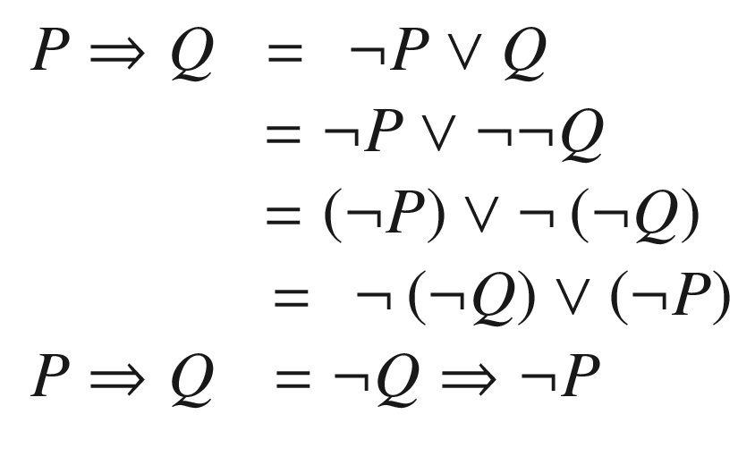

*另一种表达A* = *B* 的方式 是写成 *A* ⇔ *B* ，这意味着 B 为真 **当且仅当** A 为真。换句话说，它们的真值相同。

Another way of saying *A* = *B* is to write *A* ⇔ *B* , which means that B is true **if and only if** A is true. In other words, they have the same truth value.

最后， **德摩根定律** 是我们可以进行的两个替换：

- ¬P *∧* ¬Q ⇔ ¬ ( *P* ∨ *Q* *)*
- ¬ *P* ∧ ¬ *Q* ⇔ ¬( *P* ∨ *Q* )
- ¬P ∨ *¬Q* ⇔ ¬ ( *P* ∧ *Q* *)*
- ¬ *P* ∨ ¬ *Q* ⇔ ¬( *P* ∧ *Q* )

尝试为它们分别写出真值表，以验证它们是否有效。德摩根定律有助于简化条件语句。

Try writing the truth tables for both of them to confirm that they work. De Morgan’s law is useful for simplifying conditionals.

#### 评估TLA+ 中的 命题

#### Evaluating Propositions in TLA+

如果你读过 第二章 ，你就会了解 TLA+ 表达式求值器。我们可以用它来检查命题的值：

`>> TRUE /\ FALSEFALSE`

结合集合推导式，我们可以为表达式创建完整的真值表：

`>> {<<A, B, A => B>> : A, B \in BOOLEAN}{ <<FALSE, FALSE, TRUE>>, <<FALSE, TRUE, TRUE>>, <<TRUE, FALSE, FALSE>>, <<TRUE, TRUE, TRUE>> }`

### 套

### Sets

数学中的主要集合是 **集合** 。集合是由不带顺序的唯一元素组成的集合。{1, 2} 是一个集合。{1, 1} 就是集合 {1}，因为集合中没有重复元素。 **<<1, 2>>** 不是一个集合，因为它有顺序。{} 是一个不包含任何元素的集合，也称为“空集”。{{}} 是包含空集的集合。 集合的**基数** 是指其中元素的个数。我们将集合 S 的基数记为 | *S* |。|{{}}| = 1。这对应于 TLA+ FiniteSets模块中的基数运算符 。

The main collection in math is the **set** . A set is a collection of unique elements without order. {1, 2} is a set. {1, 1} is just the set {1}, as we do not have any duplicates in the set. **<<1, 2>>** is not a set, because it has an ordering. {} is a set with no elements, aka the “empty set.” {{}} is the set containing the empty set. The **cardinality** of a set is the number of elements in it. We write the cardinality of S as | *S* |. |{{}}| = 1. This corresponds to the Cardinality operator in the TLA+ FiniteSets module.

我们常常想知道某个元素是否属于某个集合。我们用 *x* ∈ *set* 表示该 集合 包含元素 x，用 *x* ∉ *set* 表示该集合不包含元素 x。一个集合可以包含其他集合，所以 *x* ∉ {{ *x* }} 但 { *x* } ∈ {{ *x* }}。

Often, we want to know if something is in a set. We write *x* ∈ *set* to say that set contains the element x, and *x* ∉ *set* to say that the set does not contain the element x. A set can contain other sets, so *x* ∉ {{ *x* }} but { *x* } ∈ {{ *x* }}.

如果我们有两个集合 S1 和 S2，我们可以通过以下几种方式将它们联系起来：

- 如果两个集合 具有相同的元素，则称它们 **相等。{1} ≠ {2}，{1, 2} = {1, 2}**
- Two sets are **equal** if they have the same elements. {1} ≠ {2}, {1, 2} = {1, 2}
- 如果 S1 中的每个元素也是 S2 的元素， 则称 S1 是 S2 的**子集。数学符号为 ⊆ (** \subseteq )。{1} ⊆ {1, 2} 但 {1, 3} ⊈ {1, 2}。
- S1 is a **subset** of S2 if every element of S1 is also an element of S2. The math symbol is ⊆ ( \subseteq ). {1} ⊆ {1, 2} but {1, 3} ⊈ {1, 2}.
- 两个集合的并 **集** 是指同时存在于这两个集合中的元素的集合。数学符号是 ∪（ \union ，或 \cup ）。{1, 2} ∪ {1, 3} = {1, 2, 3}。
- The **union** of two sets is the set of elements present in either one of them. The math symbol is ∪ ( \union , or \cup ). {1, 2} ∪ {1, 3} = {1, 2, 3}.
- 两个集合的交集 是同时存在于这两个集合中的元素的**集合** 。数学符号是∩（ \intersect ，或 \cap ）。{1, 2} ∩ {1, 3} = {1}。
- The **intersection** of two sets is the set of elements present in both of them. The math symbol is ∩ ( \intersect , or \cap ). {1, 2} ∩ {1, 3} = {1}.
- 两个集合的 **差集** ， 记作*S* 1 \ *S 2，是 S1 中所有**不在*S2 中 的元素 。{1, 2} \ {1, 3} = {2}。
- The **set difference** of two sets, written *S* 1 \ *S* 2, is all of the elements of S1 that are *not* in S2. {1, 2} \ {1, 3} = {2}.

*我们* 可以用这些构造一些重言式。例如， ( *S1* \ *S2* ) *∩S2* *=* { } *，* 而 *S1⊆S2∧S2⊆S1* 表示 *S1* = *S2* 。

There are some tautologies we can build with these. For example, ( *S* 1 \ *S* 2) ∩ *S* 2 = {}, and *S* 1 ⊆ *S* 2 ∧ *S* 2 ⊆ *S* 1 means that *S* 1 = *S* 2.

我们可以将两个集合的并集推广到集合的集合，记为⋃。∪{ *S1* , *S2* , …} = *S1* ∪ *S2* ∪ …。 在TLA+中， 我们将∪记为 UNION 。我们*也可以* 对交集进行类似的操作得到⋂，但这并非TLA+的核心原语。

We can generalize union from two sets to a set of sets, called ⋃. ∪ { *S* 1, *S* 2, …} = *S* 1 ∪ *S* 2 ∪ …. We write ∪ as UNION in TLA+. We *could* do the same with intersection to get ⋂, but that’s not a core primitive of TLA+.

最后，对于每个集合 S， 我们都有一个对应的 **幂集** 2<sup> <sup>*S*</sup> </sup>。2<sup> <sup>*S*</sup> </sup> 是 S 的所有子集的集合。我们这样写是因为 |2 <sup>*<sup>S*</sup> </sup> | = 2<sup> <sup>|</sup><sup>*S*</sup><sup>| </sup>。为了理解为什么会这样，考虑</sup>*S* = { *x* , *y* } 的情况 。这时，我们可以将 S 的每个子集与一个两位二进制字符串关联起来：

| 子集 subset | 细绳 string |
| --- | --- |
| { } { } | 00 00 |
| {x} {x} | 01 01 |
| {y} {y} | 10 10 |
| {x, y} {x, y} | 11 11 |

在 TLA+ 中，我们将 2S 写成 <sup>*SUBSET*</sup> S。

In TLA+ we write 2 <sup>*S*</sup> as SUBSET S .

到目前为止，我们只讨论了有限 集合 。我们也可以将所有这些操作扩展到无限集合。TLC 可以测试集合是否属于无限集合，但不能对其进行量化。

So far we’ve only talked about finite sets . We can extend all of these operations to infinite sets, too. TLC can test membership of infinite sets but cannot quantify over them.

### 谓词逻辑

### Predicate Logic

结合命题逻辑和集合论，我们得到了 **谓词逻辑** 。谓词逻辑允许我们编写关于集合元素的公式，并且是我们在 TLA+ 中几乎所有操作的基础。谓词通过两个逻辑语句（称为 **量词）**来扩展命题 ：

- ∃ ( \E ) 表示 **存在** 。 ∃ *x* ∈ *S* : *P* ( *x* ) 表示 S 中 *至少* 存在 一个元素，使得 P(x) 为真。
- ∃ ( \E ) means **there exists** . ∃ *x* ∈ *S* : *P* ( *x* ) means that there is *at least one* element of S where P(x) is true.
- ∀ ( \A ) 表示 **对于所有** 。 ∀ *x* ∈ *S* : *P* ( *x* ) 表示对于 SP(x) 的*每个* 元素，P ( x ) 都成立。
- ∀ ( \A ) is **for all** . ∀ *x* ∈ *S* : *P* ( *x* ) means that for *every single* element of S P(x) is true.

为了更好地理解其工作原理，我们来看一些公式。在所有这些例子中， *Bool* 是集合 { *T, F* }， *Int* 是所有整数的集合， *N at* 是集合 {0, 1, 2, 3, . . . }（“自然数”）。

To get a sense of how this works, let’s go through some formulas. In all these cases, *Bool* is the set { *T, F* }, *Int* is the set of all integers, and *N at* is the set {0, 1, 2, 3, . . . } (the “natural” numbers).

### 自然数

### Natural Numbers

历史上，自然数是从 1 开始的，但现代数学家对于 0 是否是自然数或是否应该被视为自然数并没有达成共识。有些数学运算使用 0 会更简单，而有些则不使用 0 会更简单。TLA+ 将 0 视为自然数，因此我们将使用 0 作为自然数。

Historically the natural numbers started from 1, but there’s no modern consensus among mathematicians on whether or not 0 is or should be a natural number. Some math is simpler with it, and some math is simpler without it. TLA+ considers 0 a natural number, so that is what we’ll use.

- ∃ *b* ∈ *Bool* : *b* ∨ *b* 为真，因为 *T* ∨ *T* 为真。
  - ∀ *b* ∈ *Bool* : *b* ∨ *b* 为假，因为 *F* ∨ *F* 为假。
- ∃ *b* ∈ *Bool* : *b* ∨ *b* is true, since *T* ∨ *T* is true.
  - ∀ *b* ∈ *Bool* : *b* ∨ *b* is false, since *F* ∨ *F* is false.
- ∃ *b* ∈ *Bool* : *b* ∨ ¬ *b* 为真，因为 *T* ∨ ¬ *T* 为真。
  - ∀ *b* ∈ *Bool* : *b* ∨ ¬ *b* 为真，因为它对 Bool 的所有（两个）元素都为真。
- ∃ *b* ∈ *Bool* : *b* ∨ ¬ *b* is true, since *T* ∨ ¬ *T* is true.
  - ∀ *b* ∈ *Bool* : *b* ∨ ¬ *b* is true, since it’s true for all (two) elements of Bool.
- ∃ *b* ∈ *Bool* : *b* ∧ ¬ *b* 为假，因为对于 T 和 F 都为假。
  - ∀ *b* ∈ *Bool* : *b* ∧ ¬ *b* 为假，因为它至少对一个元素不成立。
- ∃ *b* ∈ *Bool* : *b* ∧ ¬ *b* is false, since it’s false for both T and F.
  - ∀ *b* ∈ *Bool* : *b* ∧ ¬ *b* is false, because it’s not true for at least one element.

你可能会认为 ¬∃ *x* ∈ *S* : *P* ( *x* ) ⇒ ¬∀ *x* ∈ *S* : *P* ( *x* )：如果不存在任何元素使得 P 为真，那么 P 就不是对所有元素都成立的。毕竟， 如果一个命题对 S 中的*任何* 元素都不成立，它又 怎么可能对*所有* 元素都成立呢？

You might think that ¬∃ *x* ∈ *S* : *P* ( *x* ) ⇒ ¬∀ *x* ∈ *S* : *P* ( *x* ): If there doesn’t exist any element where P is true, then P isn’t true for all elements. After all, how could something hold for *all* elements of S if it doesn’t hold for *any* elements of S?

如果 S 为空集呢？那么 ¬∃ *x* ∈ *S* 显然为真：S 中没有元素，因此不存在任何元素 使得 P 为真。但是 ∀ *x* ∈ *S* 也显然为真：P(x) 对 S 的所有（零）元素都成立。

- ∃ *x* ∈ *N 在* : *x* = *x* + *x* 处成立，因为至少存在一个整数等于它自身的两倍：0。
  - ∃ *x* ∈ *N at* : *x* ≠ *x* + 0 ⇒ *x* = *x* + *x 看起来* 是假的，但实际上是真的！这是使用 ⇒ 时常见的陷阱。记住，我们可以将蕴含式重写为 ¬(0 ≠ 0) ∨ ( *x* = *x* + *x* )。如果我们代入 *x* = 0，就得到 ¬(0 ≠ 0) ∨ (0 = 0 + 0 )，这两个子句都为真！
  - ∃ *x* ∈ *N at* : ( *x* ≠ 0) ∧ ( *x* = *x* + *x* ) 肯定是错误的。
- ∃ *x* ∈ *N at* : *x* = *x* + *x* is true, because there is at least one integer that’s equal to twice itself: 0.
  - ∃ *x* ∈ *N at* : *x* ≠ *x* + 0 ⇒ *x* = *x* + *x looks* like it’s false, but it’s actually true! This is a common pitfall with ⇒ . Remember, we can rewrite the implication as ¬(0 ≠ 0) ∨ ( *x* = *x* + *x* ). If we plug in *x* = 0, we get ¬(0 ≠ 0) ∨ (0 = 0 + 0), and both of those clauses are true!
  - ∃ *x* ∈ *N at* : ( *x* ≠ 0) ∧ ( *x* = *x* + *x* ) is definitely, for-real false.
- 对于任意 x, y ∈ *N，当* : x ≥ y ∨ y ≥ *x* 成立时，成立。
  - 对于任意 *x, y* ∈ *N* ， 当*x > y ∨ y > x时，该命题为假，因为当**x* = *y* 时，该命题不成立 。
  - ∀ *x, y* ∈ *N 在* : *x* ≠ *y* ⇒ *x* > *y* ∨ *y* > *x* 为真。
- ∀x, y ∈ *N at* : x ≥ y ∨ y ≥ *x* is true.
  - ∀ *x, y* ∈ *N at* : *x > y ∨ y > x* is false, as it isn’t true if we pick *x* = *y* .
  - ∀ *x, y* ∈ *N at* : *x* ≠ *y* ⇒ *x* > *y* ∨ *y* > *x* is true.

我们还可以嵌套谓词：

- ∃ *x* ∈ *N at* : ∀ *y* ∈ *N at* : *x ≤ y* 表示“存在 *N 的某个最小元素在*处 ”，并且该语句为真（其值为 0）。
- ∃ *x* ∈ *N at* : ∀ *y* ∈ *N at* : *x ≤ y* is the statement “there is some smallest element of *N at* ” and is true (it’s 0).
- ∃ *x* ∈ *N at* : ∀ *y* ∈ *N at* : *x < y* 表示“存在 *N 中的某个元素在 处小于**N* 中所有元素在 处 ”，该语句为 *假* ，因为 0≮0。
- ∃ *x* ∈ *N at* : ∀ *y* ∈ *N at* : *x < y* is the statement “there is some element of *N at* smaller than all the elements of *N at* ” and is *false* , as 0≮0.
- ∃ *x* ∈ *N at* : ∀ *y* ∈ *N at \* { *x* } : *x < y* 表示“存在 *N*中的某个元素 小于所有其他元素”，该陈述为真。
- ∃ *x* ∈ *N at* : ∀ *y* ∈ *N at \* { *x* } : *x < y* is the statement “there is some element of *N at* smaller than all the others” and is true.
- ∃ *x* ∈ *Int* : ∀ *y* ∈ *Int* : *x ≤ y* 表示“存在 Int 中的最小元素”，这是错误的，因为我们总能找到另一个更小的数。
- ∃ *x* ∈ *Int* : ∀ *y* ∈ *Int* : *x ≤ y* is the statement “there is some smallest element of Int” and is false, as we can always find another smaller number.
- ∀ *y* ∈ *Int* : ∃ *x* ∈ *Int* : *x < y* 表示“对于 Int 中的每个元素，至少存在一个小于它的元素”，并且为 *真* 。这与上一个例子的区别在于，这里我们不是选择一个对所有 y 都成立的 x，而是说对于每个 y，我们都可以选择一个合适的 x。但每次的 x 不必相同。例如，如果 *y* = *-527* ，我可以选择 *x* = *-528* ；如果 *y* = *-528* ，我可以选择 *x* = *-529* ，以此类推。
- ∀ *y* ∈ *Int* : ∃ *x* ∈ *Int* : *x < y* is the statement “for every element of Int, there is at least one element smaller than it” and is *true* . The difference between this and the last example is that instead of picking one x that must hold true for every single y, we’re saying that for every single y we can pick an appropriate x. This doesn’t have to be the same x each time, though. If you give me *y* = *−* 527, and I can pick *x* = *−* 528; if you give me *y* = *−* 528, I can pick *x* = *−* 529, and so on and so forth.
- ∀ *y ∈ N at* : ∃ *x* ∈ *N at* : *x < y* 是不成立的。如果给我 *y* = 0，我无法选择一个更小的数，因为 0 已经是 *N 在 处*的最小数了 。
- ∀ *y ∈ N at* : ∃ *x* ∈ *N at* : *x < y* is false, though. If you give me *y* = 0, I can’t pick a smaller number, because 0 is already the smallest number of *N at* .

#### 评估 TLA+ 中的谓词

#### Evaluating Predicates in TLA+

TLA+ 无法对无限集合进行量化。但是，我们可以对有限集合进行量化，例如 BOOLEAN 。

`>> \A A, B \in BOOLEAN: (A => B) <=> (~A \/ B)TRUE>> \A A, B \in BOOLEAN: A <=> ~BFALSE>> \A A \in BOOLEAN: \E B \in BOOLEAN: A <=> ~BTRUE>> \E B \in BOOLEAN: ~(\A A \in BOOLEAN: A <=> ~B)TRUE`

我们可以用这个方法来比较方程 ，并检查两个方程是否可以互换。

`>> \A A, B \in BOOLEAN: ~(A /\ B) = ~A \/ ~BTRUE`

## 附录 B：PT 模块

## Appendix B: The PT Module

```
                    This is the

                      PT module


                    , which contains useful support operators to help people reading Practical TLA+. Normally we would break the operators up by domain, but we lump them all here to make it easier on beginners. All operators have a description of how they work.
                  ---- MODULE PT ----\* LOCAL means it doesn’t get included when you instantiate the module itself.LOCAL INSTANCE FiniteSetsLOCAL INSTANCE SequencesLOCAL INSTANCE IntegersMax(x, y) == IF x > y THEN x ELSE yMin(x, y) == IF x < y THEN x ELSE y(* SET STUFF *)(* Fairly simple one, uses a set comprehension to filter subsets by their cardinality (number of elements) *)SubsetsOfSize(set, n) == { set1 \in SUBSET set : Cardinality(set1) = n}(*TLA+ forbids recursive higher-order operators, but it is fine with recursive functions. Reduceset generates a recursive function over the subsets of a set, which can be used to recursively run a defined operator. This can then be used to define other recursive operators.*)ReduceSet(op(_, _), set, acc) ==  LET f[s \in SUBSET set] == \* here’s where the magic is    IF s = {} THEN acc    ELSE LET x == CHOOSE x \in s: TRUE         IN op(x, f[s \ {x}])  IN f[set](* FUNCTION STUFF *)(*
                    Gets the set of all possible values



                    that f maps to.
                  essential the "opposite" of DOMAIN. Uses a set comprehension-map.*)Range(f) == { f[x] : x \in DOMAIN f }(*Places an ARBITRARY ordering on the set. Which ordering you get is implementation-dependent but you are guaranteed to always receive the same ordering.*)OrderSet(set) == CHOOSE seq \in [1..Cardinality(set) -> set]: Range(seq) = set\* Get all inputs to a function that map to a given outputMatching(f, val) == {x \in DOMAIN f: f[x] = val}(* SEQUENCE STUFF *)\* TupleOf(s, 3) = s \X s \X sTupleOf(set, n) == [1..n -> set]\* All sequences up to length n with all elements in set.\* Equivalent to TupleOf(set, 0) \union TupleOf(set, 1) \union ...\* Includes empty sequenceSeqOf(set, n) == UNION {TupleOf(set, m) : m \in 0..n}ReduceSeq(op(_, _), seq, acc) ==  ReduceSet(LAMBDA i, a: op(seq[i], a), DOMAIN seq, acc)(*  SelectSeq lets you filter a sequence based on a test operator. It acts on the values. SelectSeqByIndex does the exact same, except the operator tests the indices. This is useful if you need to round-robin a thing.*)SelectSeqByIndex(seq, T(_)) ==  ReduceSet(LAMBDA i, selected:              IF T(i) THEN Append(selected, seq[i])              ELSE selected,            DOMAIN seq, <<>>)\* Pulls an indice of the sequence for elem.Index(seq, elem) == CHOOSE i \in 1..Len(seq): seq[i] = elem(*
                      % is 0-based, but sequences are 1-based. This means S[x % Len(S)] might be an error, as it could evaluate to S[0], which is not an element of the sequence. This is a binary operator



                    . See [cheat sheet] to see the defineable boolean operators.
                  *)LOCAL a %% b == IF a % b = 0 THEN b ELSE a % bSeqMod(a, b) == a %% b=====
```

## 附录 C：PlusCal 到 TLA+

## Appendix C: PlusCal to TLA+

本书中，我们通过 PlusCal（一种基于 TLA+ 的算法语法）来使用 TLA+。PlusCal 易于学习且适用于多种问题，但并非所有内容都能用它表达。本书并非旨在教您如何用 TLA+ 编写规范，而是着重概述 TLA+ 的工作原理并阐述其直观性。如果您需要更严谨的讲解，请参阅《系统规范》 *（Specificationing Systems ）一书，该书可在*“帮助”>“系统规范” 工具箱中免费获取 。

In this book we used TLA+ through the intermediary of PlusCal, an algorithm syntax built on top of TLA+. While PlusCal is simple to learn and useful for a wide range of problems, not everything can be expressed in it. Rather than teach you how to write specs in TLA+, we’re going to provide an overview and intuition for how TLA+ “works.” If you want a more rigorous treatment, please refer to the book *Specifying Systems* , which can be accessed for free in the Toolbox under Help > Specifying Systems .

本附录假设您已阅读本书的前六章和附录 A。我们将首先介绍一些逻辑扩展，然后介绍如何在 TLA+ 中表达属性，最后简要讨论何时应该使用纯 TLA+ 而不是 PlusCal。

This appendix assumes you’ve read the first six chapters of the book and Appendix A. We’ll start by covering some extensions to logic, follow up with how we express properties in TLA+, and conclude with a brief discussion of when you’d want to use pure TLA+ over PlusCal.

### 时序逻辑

### Temporal Logic

利用谓词逻辑，我们可以 *量化语句：判断某个语句对于**所有可能的*值 是否都为真 ，或者是否仅对于 *至少一个* 值才为真。 **模态逻辑** 允许我们对 语句 *进行限定。□* *P* 表示 P *必然*为 真。⋄ *P* 表示 P *可能*为 真。“必然”和“可能”的具体含义取决于所使用的模态逻辑系统。大多数模态逻辑系统仅对哲学家而言才有意义，但其中一种模态逻辑—— **时序逻辑** ——在软件工程中却至关重要。在时序逻辑中，□ *P* 表示 P *总是*为 真，而 ⋄ *P* 表示 P *有时*为 真。

With predicate logic, we could *quantify* statements: say whether something is true for *all possible* values, or only true for *at least one* value. **Modal logic** lets us *qualify* statements. □ *P* means that P is *necessarily* true. ⋄ *P* means that P is *possibly* true. What “necessarily” and “possibly” mean depends on the modal logic system you’re using. Most of them are only interesting to philosophers, but one type of modal logic, **temporal logic** , matters a great deal in software engineering. In a temporal logic, □ *P* means that P is *always* true, while ⋄ *P* means that P is *sometimes* true.

这里“总是”的含义很明确，但人们对“有时”的理解却有两种常见且互斥的方式：

1. 1.

   对于每个初始状态，都有可能达到 P 为真的状态。
2. 1.

   For every initial state, it is possible to reach a state where P is true.
3. 2.

   对于每个初始状态，无论你做什么，你最终都会达到 P 为真的状态。
4. 2.

   For every initial state, no matter what you do, you will at some point reach a state where P is true.

为了理解这两种解释之间的区别，考虑掷一个六面骰子。如果你掷一次，⋄( *掷出点数* = 6) 是否成立？根据第一种解释 ，是的： 你*有可能* 掷出 6。根据第二种解释，否：你也可能掷出 5。但无论哪种解释，我们都有 ⋄( *掷出点数 >* 0) 和 *¬⋄* ( *掷出点数* = 7)。

To see the difference between the two, consider rolling a 6-sided dice. If you roll once, is it true that ⋄( *roll* = 6)? Under the first interpretation , yes: it is *possible* that you rolled a six. Under the second interpretation, no: you could roll a 5 instead. But under both interpretations, we have ⋄( *roll >* 0) and *¬* ⋄( *roll* = 7).

TLA+遵循第二种解释。为了更清晰地表达，我们用 *“最终”* 代替 *“有时”* 。为了使这些限定词发挥作用，我们需要一种方法来描述语句的变化。这正是 *时序* 逻辑的精髓所在：我们允许语句随时间演变，而不是固定不变的。

TLA+ follows the second interpretation. To make it clearer we say *eventually* instead of *sometimes* . In order for these qualifiers to be useful, we need a way to talk about how our statements change. This is what makes it a *temporal* logic: instead of having fixed, static statements, we allow them to evolve over time.

**我们通过引入变量** 的概念来实现这一点 。你已经很熟悉这个概念了：变量是指在不同时间点可能取不同值。在时序逻辑中，我们用一系列状态来表示“不同的时间点”，其中变量的值在不同状态之间可能会发生变化。例如，如果 x 从 0 开始，递增 1 直到达到 2，然后又回到 0，我们可以将“发生的情况”表示为序列 *(x* = 0 *, x* = 1 *, x* = 2 *, x* = 0 *)* 。这里，语句 ⋄( *x* = 2) 为真，而语句 □( *x* = 0) 为假。我们将任何这样的状态序列称为 **行为** 。

We do this by adding a concept of a **variable** . You’re already familiar with this: a variable is some value that may be different at different points in time. In the context of a temporal logic, we represent “different points in time” by having a sequence of states, where the values of variables may change between states. For example, if x starts at zero, increases by one until it reaches 2, and then goes back to zero, we could represent “what happens” as the sequence *(x* = 0 *, x* = 1 *, x* = 2 *, x* = 0 *)* . Here the statement ⋄( *x* = 2) is true, while the statement □( *x* = 0) is false. We call any such sequence of states a **behavior** .

现在我们有了描述所需 行为和属性的方法 ，接下来需要一种方法来描述系统中哪些行为是*有效的* ，或者说哪些行为实际上可以在系统中发生。例如，一种可能的行为是 *(x* = 0 *, x* = −9, *x* = ” :)”, *x* = 0)。我们可能并不希望它是有效的！

Now that we have a means of describing behaviors and properties we want, we need a way of describing which behaviors in our system are *valid* , or actually can happen in our system. For example, one possible behavior is *(x* = 0 *, x* = −9, *x* = ” :)”, *x* = 0). We probably don’t want that to be valid!

为了标记有效行为，我们使用 基于 TLA+ 的“动作”的 **下一状态关系。**

In order to mark the valid behaviors, we use **next-state relations** , which are built on the “actions” of TLA+.

### **行动**

### **Actions**

动作 是**行为** 中两个连续状态之间的谓词。它的外观和行为与其他谓词完全相同，只是它还包含一个 **撇号** 运算符（单引号，或'）。在动作中， *x表示**x*在第一个状态下 的值 ，而 *x'* 表示 x 在下一个状态下的值。

An **action** is a predicate between two consecutive states of a behavior. It looks and behaves exactly like any other predicate, except it also contains a **prime** operator (a single quote, or ’). In an action, *x* is the value of *x* in the first state, while *x’* is the value of x in the next state.

这可能有点令人困惑，所以我们举个例子。考虑动作“ 增加 == x ' > x”。 如果下一个状态下 x 的值大于当前状态的值，则“增加”对当前状态为真 *。* 如果行为是 *(x* = 0 *, x* = 1 *, x* = 2 *, x* = 0 *)* ， “增加” 对前两个状态为真，但对第三个状态不为真。在第一个状态下， *x* = 0 且 *x'* = 1，所以 *x' > x* 。在第三个状态下， *x* = 2 且 *x'* = 0，所以 *¬* ( *x' > x* )。

This may seem confusing, so let’s give an example. Take the action Increases == x ’ > x. Increases is true for a state if, in the *next* state, x is greater than it was before. If the behavior is *(x* = 0 *, x* = 1 *, x* = 2 *, x* = 0 *)* , Increases is true for the first and second states, but not the third state. In the first state, *x* = 0 and *x’* = 1, so *x’ > x* . In the third, *x* = 2 and *x’* = 0, so *¬* ( *x’ > x* ).

另一个例子是

`DecreaseFromAtLeastThree == /\ x > 2 /\ x’ < x`

只有当 x 大于 2 且随后减小时，这个结论才成立。在我们上面的例子中，这个结论始终不成立：虽然 x 曾经减小过，但它的初始值并不大于 2。

This is only true if x is greater than 2 and then decreases. In our above behavior, it is never true: while at one point x decreased, it didn’t start out greater than 2.

为什么动作很重要？结合我们的模态运算符，动作使我们能够描述系统的整体演化过程。假设我们的计数器是模 3 的：x 从 0 开始，每次递增 1，直到达到 2，然后返回到 0。每一次转换都可以用以下两种动作之一来描述：

`Increment == /\ x < 2 /\ x’ = x + 1Reset == /\ x = 2 /\ x’ = 0`

每一次转换都是这些动作之一。这意味着这些动作中 *总*有一个是 成立的。也就是说，我们可以将 *所有可能的行为*描述 如下：

`Init == (x = 0)Next == Increment \/ ResetSpec == Init /\ []Next`

“初始化” 本身指的是初始状态：x 必须从零开始。□ *“下一步”* 意味着 在整个行为过程中， “下一步” 必须为真，即 “递增 ”或 “重置”要么为真， 要么为真。由于两者都限制了 x 在两个状态之间的变化方式，因此这足以提供我们系统的规范。

Init by itself means the starting state: x must start at zero. □ *Next* means that Next must be true for the entire behavior, aka either Increment is true or Reset is true. Since both of them constrain how x can change between two states, this is enough to give us a specification of our system.

现在，编写以下 PlusCal 算法并将其翻译成 TLA+：

`EXTENDS Integers(*--algorithm counter variables x = 0begin while TRUE do either await x < 2; x := x + 1; or await x = 2; x := 0; end either; end while; end algorithm; *)`

眼熟？

### TLA

### TLA

最后还有两件事需要处理。首先，我们要求下一状态关系必须明确 *所有* 变量的新值。在任意两个状态之间，为真的操作必须涵盖规范中的每个变量。如果我们忘记考虑某个值，比如 account_total ，那就等于说account_total'的*值* 无关紧要 。这意味着account_total = 1 和 account_total' = "abcdefg" 都是有效的行为 ！ 这很快就会导致混乱，所以我们要求必须明确指定所有变量。

There are two last things we need to take care of. First of all, we require that the next-state relation must specify the new values of *all* variables. Between any two states, the actions that are true must cover every variable in the spec. If we forget to account for some value, say, account_total , we’re saying it doesn’t matter *what* account_total’ is. This means it’s a valid behavior for account_total = 1 and account_total’ = "abcdefg"! This quickly leads to nonsense, so we require that all variables are specified.

最后，我们需要所有测试用例都具有 **卡顿不变性** 。我们应该能够在任何时候插入一个额外的状态，在这个状态下什么都不发生。如果没有这个特性，我们最终会遇到一些奇怪的问题，而且几乎不可能将两个测试用例干净地合并在一起。允许卡顿只会让测试用例更加简洁。因此， 我们 不再写`[]Next` ，而是写`[][Next]_x` 。这等价于写 `[](Next \/ UNCHANGED x) `，即“Next 为真或 x 保持不变”。这样就允许了卡顿的发生，从而赋予了我们卡顿不变性的所有优点。显然，如果我们的测试用例使用了多个变量，我们也需要将它们添加进去。

Finally, we need all of our specs to be **stutter-invariant** . At any point we should be able to drop in an extra state where nothing happens. Without this property, we eventually run into bizarre problems, and it becomes nearly impossible to cleanly combine two specs together. Permitting stuttering just makes the specs a whole lot cleaner. So instead of writing []Next , we write [][Next]_x . That’s equivalent to writing [](Next \/ UNCHANGED x) , or “either Next is true or x is unchanged.” This lets stuttering happen, giving us all the nice properties of stutter-invariance. Obviously, if our spec uses more than one variable, we’d1 have to add them too.

至此，我们就有了 **行动** 的 **时间****逻辑（** TLA **）** 。TLA+ 只是在 TLA 的基础上增加了一些额外的结构， 例如 模块系统。虽然还有一些细节需要完善，例如公平性，但你现在已经对它有了大致的了解。

With that, we now have a **T** emporal **L** ogic of **A** ctions, or **TLA** . TLA+ is just TLA with some extra structure on top, such as the module system. There’s still a few small details, such as fairness, but you now have a broad overview.

你有时可能会看到规格写成这样：

`THEOREM Spec => []TypeInvariant`

这是给读者的一条提示： *如果* 系统遵循 规范 (Spec) ， *那么* 它将具有 类型 不变性 (TypeInvariant)。实际上，这不会改变模型检查器的行为；您仍然需要将 规范 (Spec)设置为时间公式，并将类型不变性 (TypeInvariant) 添加 为特定不变性。

That’s a note to the reader that *if* the system obeys Spec , *then* it will have TypeInvariant as an invariant. In practice, this doesn’t change what the model checker does; you still have to make Spec the temporal formula and add TypeInvariant as a specific invariant.

### PlusCal 的 局限性

### Limitations of PlusCal

PlusCal 对很多细节进行了抽象。对于很多问题来说，它完全够用。但是，它也有一些局限性。首先，它的灵活性不如用 TLA+ 编写所有内容。例如，在 PlusCal 中，你无法编写形如 (A /\ B) \/ (A /\ C)的动作 ，也无法允许两个进程“同时”运行。此外，你也不能在 PlusCal 中将包含变量的规范组合在一起，而这在 TLA+ 中却非常容易实现。

PlusCal abstracts a lot of this away. For many problems, it’s perfectly adequate. However, there are some limitiations. First of all, it’s not as flexible as writing everything in TLA+. You couldn’t, for example, have an action of form (A /\ B) \/ (A /\ C) in PlusCal, or allow two processes to run “simultaneously.” You also can’t compose specifications with variables together in PlusCal, while it’s pretty straightforward in TLA+.

PlusCal 的一个主要局限性我们在第9 章中已经提到过 ：你无法证明一个规范是 对另一个规范的**细化。在 TLA+ 中，我们可以使用**`INSTANCE HighLevel` 实例化高级规范 ，然后检查时序属性 `HighLevel!Spec` 。这样就表明，实现的每个行为也都是 高级规范的有效行为。

One major limitation of PlusCal is something we touched on in Chapter 9 : you can’t prove one spec is a **refinement** of another. In TLA+, we could instantiate the high-level spec with INSTANCE HighLevel and then check the temporal property HighLevel!Spec . That would say that every behavior of the implementation is also a valid behavior of the high level spec.

PlusCal 可以长期为你提供良好的服务。但你也应该知道何时该停止使用。

PlusCal will serve you well for a very long time. But you should know when you’re pushing against the limits.

[output not shown]